# Brain Tumor — Feature Parameter Selection + Benchmark

### 8. Phase 1C — DWT Parameter Selection

```
Loaded DWT scan from cache: dwt_b4caa543fcbb9451.joblib (saved 2026-06-05T00:59:55.729278+00:00)

✓ Best DWT config (from cache):
  wavelet : db2
  level   : 1
  score   : 0.9837
```

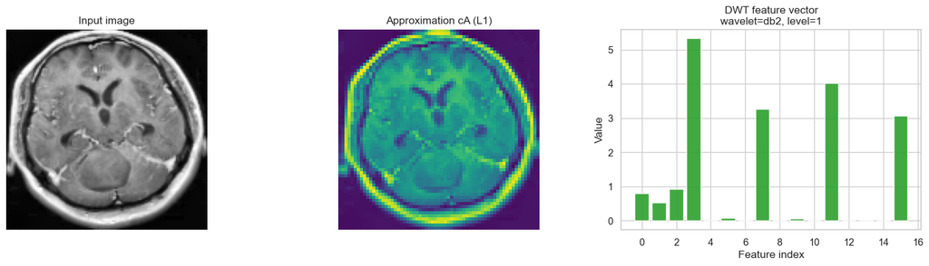

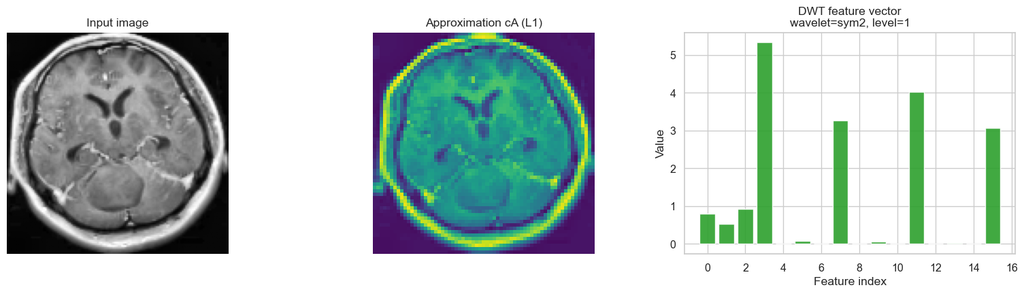

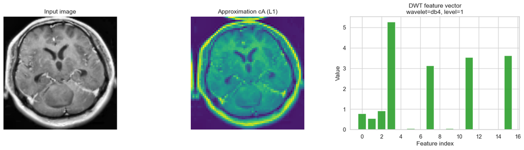

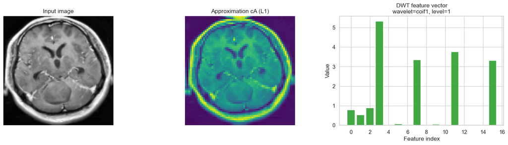

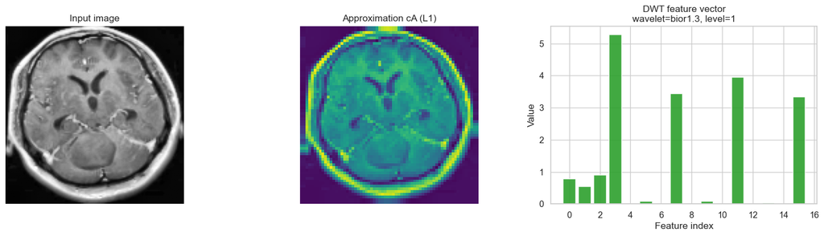

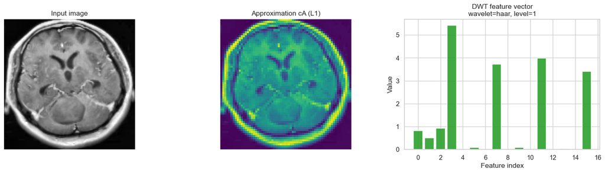

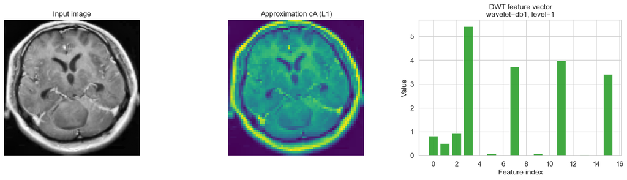

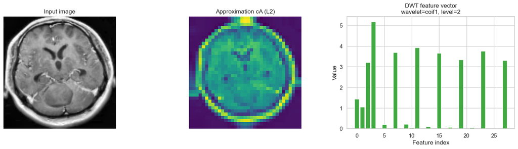

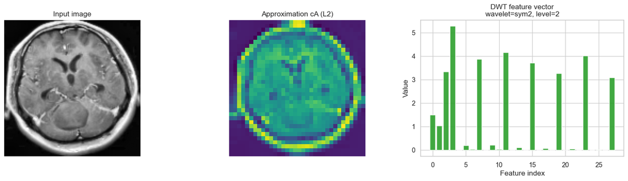

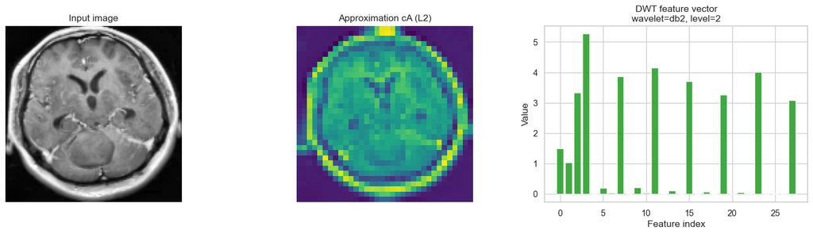

```python
_dwt_cache = load_phase1_scan("dwt", DWT_GRID)
if _dwt_cache is not None:
    dwt_df = _dwt_cache["df"]
    _apply_dwt_best_from_df()
    print("\n✓ Best DWT config (from cache):")
    print(f"  wavelet : {BEST_DWT_WAV}")
    print(f"  level   : {BEST_DWT_LEVEL}")
    print(f"  score   : {dwt_df.iloc[0]['score']:.4f}")
elif RUN_PHASE1_SCANS:
    print("Scanning DWT parameter space …")
    dwt_rows = []

    configs_dwt = list(itertools.product(DWT_GRID["wavelet"], DWT_GRID["level"]))
    print(f"Total DWT configurations: {len(configs_dwt)}")

    for wavelet, level in tqdm(configs_dwt, desc="DWT"):
        label = f"wavelet={wavelet:8s} level={level}"
        try:
            X_feat  = extract_dwt(X_train_raw, wavelet, level)
            metrics = evaluate_features(X_feat, y_train)
            dwt_rows.append({
                "wavelet":    wavelet,
                "level":      level,
                "n_features": X_feat.shape[1],
                "label":      label,
                **metrics,
            })
        except Exception as e:
            print(f"  SKIP {label}: {e}")

    dwt_df = pd.DataFrame(dwt_rows)

    mms = MinMaxScaler()
    dwt_df["FDR_n"] = mms.fit_transform(dwt_df[["FDR"]])
    dwt_df["MI_n"]  = mms.fit_transform(dwt_df[["MI"]])
    dwt_df["DBI_n"] = 1 - mms.fit_transform(dwt_df[["DBI"]])
    dwt_df["score"] = (dwt_df["FDR_n"] + dwt_df["MI_n"] + dwt_df["DBI_n"]) / 3
    dwt_df = dwt_df.sort_values("score", ascending=False).reset_index(drop=True)

    print("\nAll DWT configurations (sorted by score):")
    display(dwt_df[["wavelet","level","n_features","FDR","MI","DBI","score"]].round(4))

    _apply_dwt_best_from_df()
    print(f"\n✓ Best DWT config:")
    print(f"  wavelet : {BEST_DWT_WAV}")
    print(f"  level   : {BEST_DWT_LEVEL}")
    print(f"  score   : {dwt_df.iloc[0]['score']:.4f}")
    save_phase1_scan("dwt", DWT_GRID, dwt_df)
else:
    print("DWT scans skipped — using Phase 1 bundle.")
    print(f"\n✓ Best DWT config (restored):")
    print(f"  wavelet : {BEST_DWT_WAV}")
    print(f"  level   : {BEST_DWT_LEVEL}")
    print(f"  score   : {dwt_df.iloc[0]['score']:.4f}")

def dwt_features_for_one_image(img, wavelet, level):
    return extract_dwt([img], wavelet, level)[0].astype(np.float32)

if RUN_PHASE1_VIZ:
    def dwt_decompose_for_plot(img, wavelet, level):
        return pywt.wavedec2(img, wavelet=wavelet, level=level)

    def plot_dwt_features_on_image(img, wavelet, level, title_suffix=""):
        feat = dwt_features_for_one_image(img, wavelet, level)
        coeffs = dwt_decompose_for_plot(img, wavelet, level)
        fig, axes = plt.subplots(1, 3, figsize=(16, 4.5))
        axes[0].imshow(img, cmap="gray")
        axes[0].set_title("Input image")
        axes[0].axis("off")
        cA = coeffs[0]
        axes[1].imshow(cA, cmap="viridis")
        axes[1].set_title(f"Approximation cA (L{level})")
        axes[1].axis("off")
        axes[2].bar(np.arange(len(feat)), feat, color="tab:green", alpha=0.9)
        axes[2].set_title("DWT feature vector" + (f"\n{title_suffix}" if title_suffix else ""))
        axes[2].set_xlabel("Feature index")
        axes[2].set_ylabel("Value")
        plt.tight_layout()
        plt.show()

    sample_idx = 0
    sample_img = X_train_raw[sample_idx]
    dwt_to_plot = dwt_df.head(10)
    for _, row in dwt_to_plot.iterrows():
        wavelet = str(row["wavelet"])
        level = int(row["level"])
        label = f"wavelet={wavelet}, level={level}"
        plot_dwt_features_on_image(sample_img, wavelet, level, title_suffix=label)
```

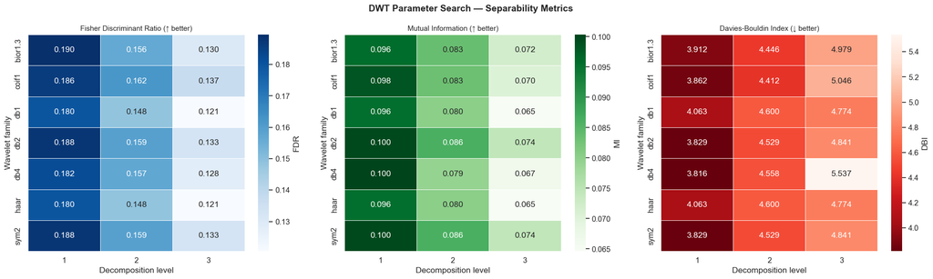

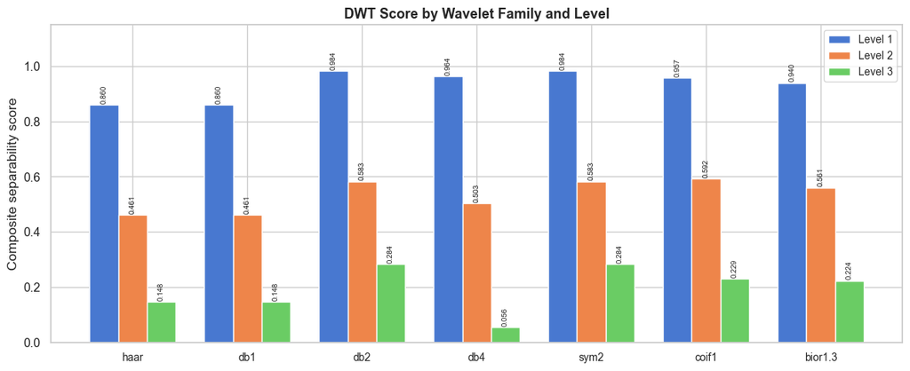

```
Saved: dwt_param_search.png, dwt_wavelet_comparison.png
```

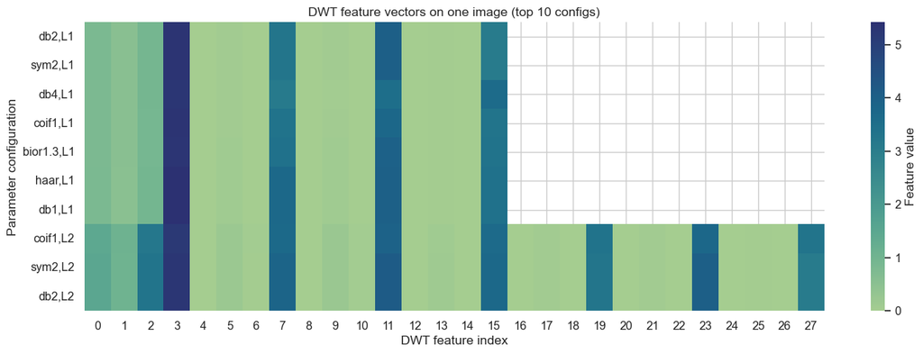

```
Saved: dwt_feature_vectors_top10.png
```

```python
# ── DWT visualisation ─────────────────────────────────────────────────────
fig, axes = plt.subplots(1, 3, figsize=(20, 6))
fig.suptitle("DWT Parameter Search — Separability Metrics", fontsize=14, fontweight="bold")

for ax, (met, title, cmap) in zip(axes, [
        ("FDR","Fisher Discriminant Ratio (↑ better)","Blues"),
        ("MI", "Mutual Information (↑ better)",       "Greens"),
        ("DBI","Davies-Bouldin Index (↓ better)",     "Reds")]):

    piv = dwt_df.pivot(index="wavelet", columns="level", values=met)
    inv = (met == "DBI")
    sns.heatmap(piv, ax=ax, cmap=cmap+"_r" if inv else cmap,
                annot=True, fmt=".3f", linewidths=0.5,
                cbar_kws={"label": met})
    ax.set_title(title, fontsize=11)
    ax.set_xlabel("Decomposition level")
    ax.set_ylabel("Wavelet family")

plt.tight_layout()
plt.savefig(OUTPUT_DIR / "dwt_param_search.png", dpi=120, bbox_inches="tight")
plt.show()

# ── Score bar chart ────────────────────────────────────────────────────────
fig, ax = plt.subplots(figsize=(12, 5))
width = 0.25
wavelets = DWT_GRID["wavelet"]
levels   = DWT_GRID["level"]
lev_colors = sns.color_palette("muted", len(levels))
x = np.arange(len(wavelets))

for li, (lv, col) in enumerate(zip(levels, lev_colors)):
    vals = [dwt_df[(dwt_df.wavelet==wv)&(dwt_df.level==lv)]["score"].values[0]
            if len(dwt_df[(dwt_df.wavelet==wv)&(dwt_df.level==lv)])>0 else 0
            for wv in wavelets]
    bars = ax.bar(x + (li - len(levels)/2 + 0.5)*width, vals, width,
                  label=f"Level {lv}", color=col, edgecolor="white")
    ax.bar_label(bars, fmt="%.3f", fontsize=7, padding=1, rotation=90)

ax.set_xticks(x)
ax.set_xticklabels(wavelets, fontsize=10)
ax.set_ylabel("Composite separability score")
ax.set_title("DWT Score by Wavelet Family and Level", fontsize=13, fontweight="bold")
ax.legend(fontsize=10)
ax.set_ylim(0, 1.15)
plt.tight_layout()
plt.savefig(OUTPUT_DIR / "dwt_wavelet_comparison.png", dpi=120, bbox_inches="tight")
plt.show()
print("Saved: dwt_param_search.png, dwt_wavelet_comparison.png")

# ── Optional compact view: top-DWT configs vs feature indices ─────────────
sample_idx = 0
sample_img = X_train_raw[sample_idx]
dwt_top = dwt_df.head(10)

max_features = int(dwt_top["n_features"].max())
feature_matrix = np.full((len(dwt_top), max_features), np.nan, dtype=np.float32)
row_labels = []

for i, (_, row) in enumerate(dwt_top.iterrows()):
    wavelet = str(row["wavelet"])
    level = int(row["level"])
    feat = dwt_features_for_one_image(sample_img, wavelet, level)
    feature_matrix[i, :len(feat)] = feat
    row_labels.append(f"{wavelet},L{level}")

plt.figure(figsize=(14, 5))
sns.heatmap(feature_matrix, cmap="crest", cbar_kws={"label": "Feature value"})
plt.yticks(np.arange(len(row_labels)) + 0.5, row_labels, rotation=0)
plt.xlabel("DWT feature index")
plt.ylabel("Parameter configuration")
plt.title("DWT feature vectors on one image (top 10 configs)")
plt.tight_layout()
plt.savefig(OUTPUT_DIR / "dwt_feature_vectors_top10.png", dpi=120, bbox_inches="tight")
plt.show()
print("Saved: dwt_feature_vectors_top10.png")
```

### 9. Phase 1D — HOG Parameter Selection

```
Loaded HOG scan from cache: hog_4b91fd9d092a55fc.joblib (saved 2026-06-05T01:04:24.607472+00:00)

✓ Best HOG config (from cache):
  orientations    : 6
  pixels_per_cell : (16, 16)
  cells_per_block : (3, 3)
  block_norm      : L2-Hys
  score           : 0.9898
```

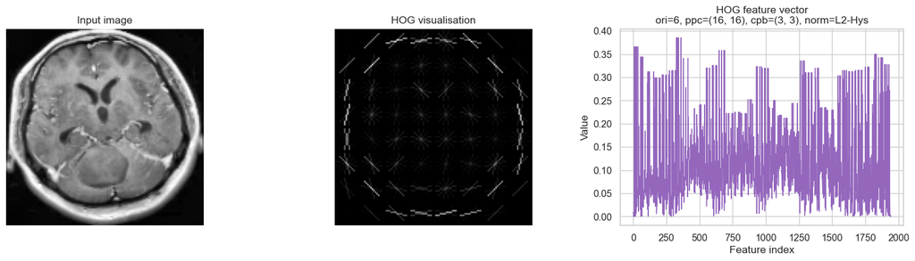

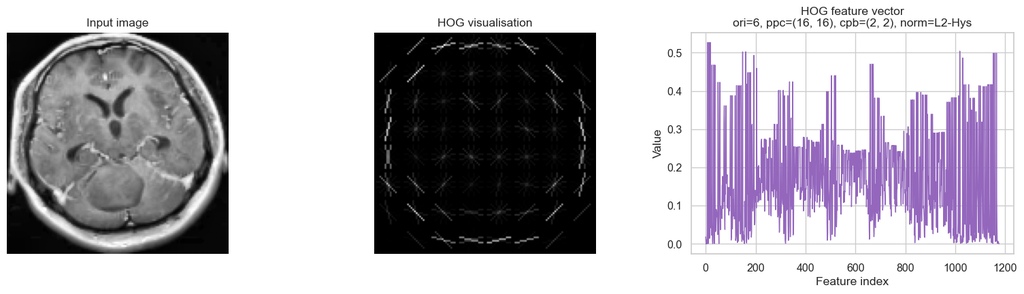

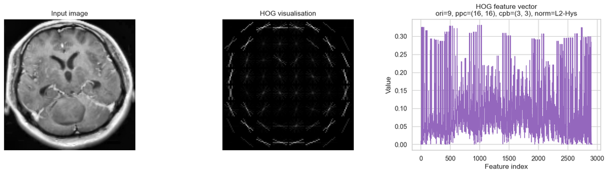

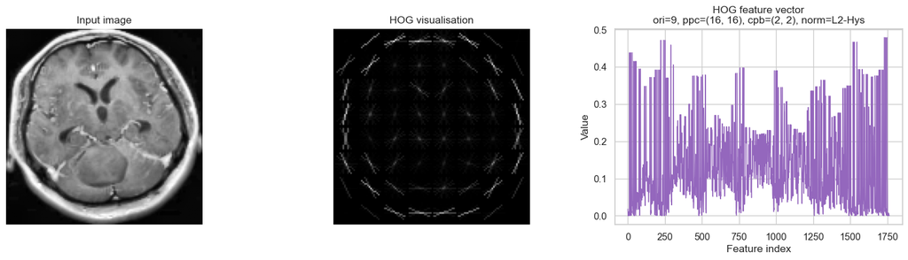

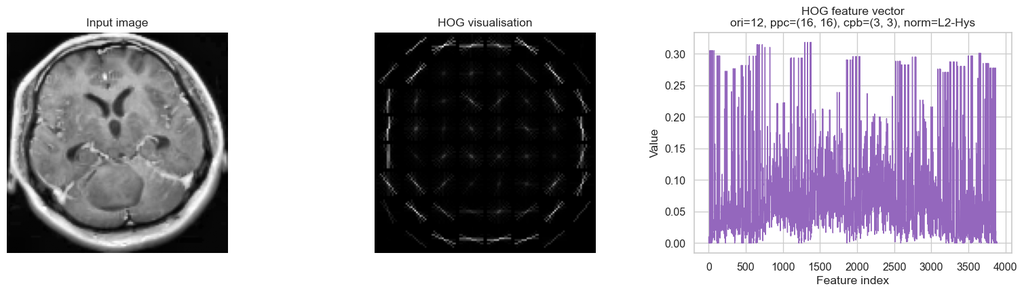

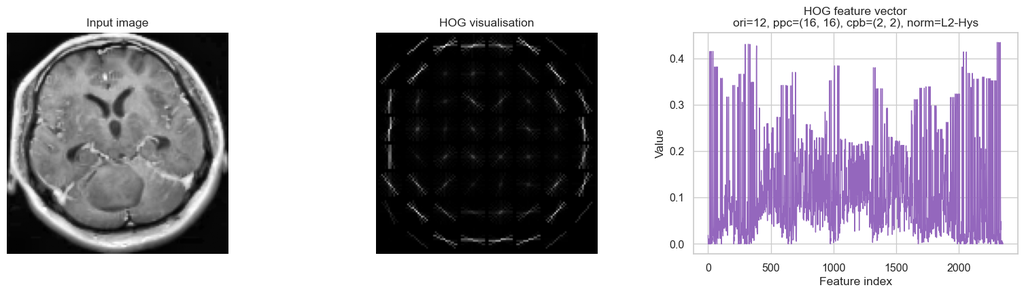

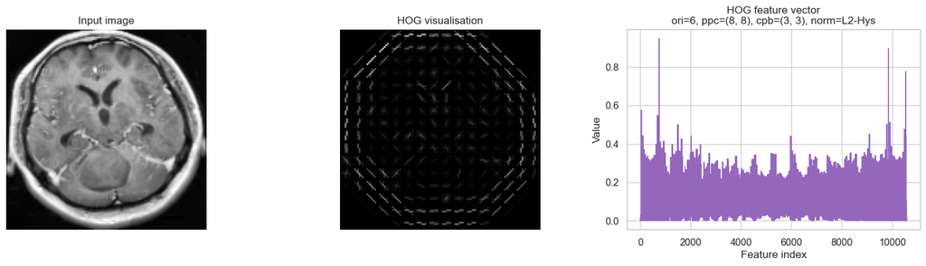

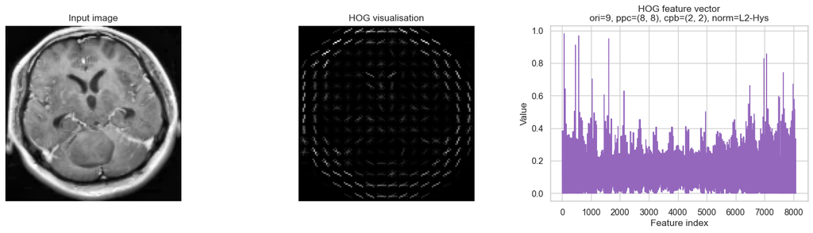

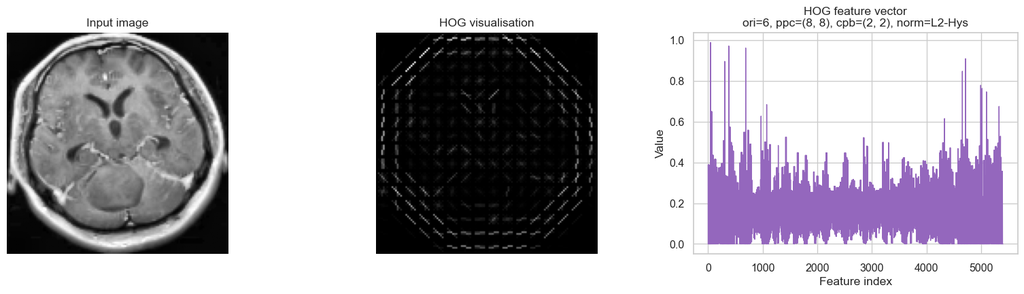

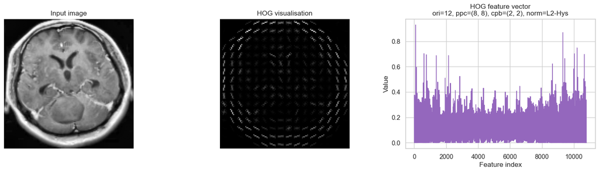

```python
from ast import literal_eval

_hog_cache = load_phase1_scan("hog", HOG_GRID)
if _hog_cache is not None:
    hog_df = _hog_cache["df"]
    _apply_hog_best_from_df()
    print("\n✓ Best HOG config (from cache):")
    print(f"  orientations    : {BEST_HOG_ORI}")
    print(f"  pixels_per_cell : {BEST_HOG_PPC}")
    print(f"  cells_per_block : {BEST_HOG_CPB}")
    print(f"  block_norm      : {BEST_HOG_NORM}")
    print(f"  score           : {hog_df.iloc[0]['score']:.4f}")
elif RUN_PHASE1_SCANS:
    print("Scanning HOG parameter space …")
    hog_rows = []

    configs_hog = list(itertools.product(
        HOG_GRID["orientations"],
        HOG_GRID["pixels_per_cell"],
        HOG_GRID["cells_per_block"],
        HOG_GRID["block_norm"],
    ))
    print(f"Total HOG configurations: {len(configs_hog)}")

    def extract_hog(images, orientations, pixels_per_cell, cells_per_block, block_norm):
        rows = []
        for img in images:
            feat = hog(
                img,
                orientations=orientations,
                pixels_per_cell=pixels_per_cell,
                cells_per_block=cells_per_block,
                block_norm=block_norm,
                feature_vector=True,
            ).astype(np.float32)
            rows.append(feat)
        return np.vstack(rows).astype(np.float32)

    for orientations, ppc, cpb, block_norm in tqdm(configs_hog, desc="HOG"):
        label = f"ori={orientations} ppc={ppc} cpb={cpb} norm={block_norm}"
        try:
            X_feat = extract_hog(X_train_raw, orientations, ppc, cpb, block_norm)
            metrics = evaluate_features(X_feat, y_train)
            hog_rows.append({
                "orientations": orientations,
                "pixels_per_cell": str(ppc),
                "cells_per_block": str(cpb),
                "block_norm": block_norm,
                "n_features": X_feat.shape[1],
                "label": label,
                **metrics,
            })
        except Exception as e:
            print(f"  SKIP {label}: {e}")

    hog_df = pd.DataFrame(hog_rows)
    if hog_df.empty:
        raise RuntimeError("No valid HOG configuration was evaluated.")

    mms = MinMaxScaler()
    hog_df["FDR_n"] = mms.fit_transform(hog_df[["FDR"]])
    hog_df["MI_n"] = mms.fit_transform(hog_df[["MI"]])
    hog_df["DBI_n"] = 1 - mms.fit_transform(hog_df[["DBI"]])
    hog_df["score"] = (hog_df["FDR_n"] + hog_df["MI_n"] + hog_df["DBI_n"]) / 3
    hog_df = hog_df.sort_values("score", ascending=False).reset_index(drop=True)

    print("\nTop 10 HOG configurations:")
    display(hog_df[["orientations", "pixels_per_cell", "cells_per_block", "block_norm", "n_features", "FDR", "MI", "DBI", "score"]].head(10).round(4))

    _apply_hog_best_from_df()
    print(f"\n✓ Best HOG config:")
    print(f"  orientations    : {BEST_HOG_ORI}")
    print(f"  pixels_per_cell : {BEST_HOG_PPC}")
    print(f"  cells_per_block : {BEST_HOG_CPB}")
    print(f"  block_norm      : {BEST_HOG_NORM}")
    print(f"  score           : {hog_df.iloc[0]['score']:.4f}")
    save_phase1_scan("hog", HOG_GRID, hog_df)
else:
    print("HOG scans skipped — using Phase 1 bundle.")
    print(f"\n✓ Best HOG config (restored):")
    print(f"  orientations    : {BEST_HOG_ORI}")
    print(f"  pixels_per_cell : {BEST_HOG_PPC}")
    print(f"  cells_per_block : {BEST_HOG_CPB}")
    print(f"  block_norm      : {BEST_HOG_NORM}")
    print(f"  score           : {hog_df.iloc[0]['score']:.4f}")

def hog_features_for_one_image(img, orientations, pixels_per_cell, cells_per_block, block_norm):
    feat, hog_img = hog(
        img,
        orientations=orientations,
        pixels_per_cell=pixels_per_cell,
        cells_per_block=cells_per_block,
        block_norm=block_norm,
        visualize=True,
        feature_vector=True,
    )
    return feat.astype(np.float32), hog_img

if RUN_PHASE1_VIZ:
    def plot_hog_features_on_image(img, orientations, ppc, cpb, block_norm, title_suffix=""):
        feat, hog_img = hog_features_for_one_image(img, orientations, ppc, cpb, block_norm)
        fig, axes = plt.subplots(1, 3, figsize=(16, 4.5))
        axes[0].imshow(img, cmap="gray")
        axes[0].set_title("Input image")
        axes[0].axis("off")
        axes[1].imshow(hog_img, cmap="gray")
        axes[1].set_title("HOG visualisation")
        axes[1].axis("off")
        axes[2].plot(np.arange(len(feat)), feat, color="tab:purple", lw=1.0)
        axes[2].set_title("HOG feature vector" + (f"\n{title_suffix}" if title_suffix else ""))
        axes[2].set_xlabel("Feature index")
        axes[2].set_ylabel("Value")
        plt.tight_layout()
        plt.show()

    sample_idx = 0
    sample_img = X_train_raw[sample_idx]
    hog_to_plot = hog_df.head(10)
    for _, row in hog_to_plot.iterrows():
        ori = int(row["orientations"])
        ppc = literal_eval(row["pixels_per_cell"])
        cpb = literal_eval(row["cells_per_block"])
        norm = str(row["block_norm"])
        label = f"ori={ori}, ppc={ppc}, cpb={cpb}, norm={norm}"
        plot_hog_features_on_image(sample_img, ori, ppc, cpb, norm, title_suffix=label)
```

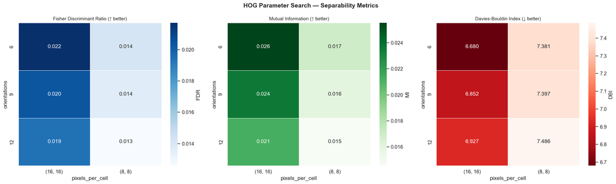

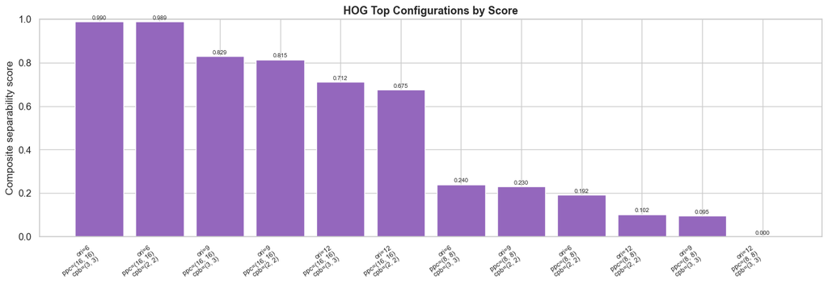

```
Saved: hog_param_search.png, hog_top_configs.png
```

```python
# ── HOG visualisation ─────────────────────────────────────────────────────
fig, axes = plt.subplots(1, 3, figsize=(20, 6))
fig.suptitle("HOG Parameter Search — Separability Metrics", fontsize=14, fontweight="bold")

for ax, (met, title, cmap) in zip(axes, [
        ("FDR", "Fisher Discriminant Ratio (↑ better)", "Blues"),
        ("MI",  "Mutual Information (↑ better)",       "Greens"),
        ("DBI", "Davies-Bouldin Index (↓ better)",     "Reds")]):

    piv = hog_df.pivot_table(index="orientations", columns="pixels_per_cell", values=met, aggfunc="mean")
    inv = (met == "DBI")
    sns.heatmap(piv, ax=ax, cmap=cmap + "_r" if inv else cmap,
                annot=True, fmt=".3f", linewidths=0.5,
                cbar_kws={"label": met})
    ax.set_title(title, fontsize=11)
    ax.set_xlabel("pixels_per_cell")
    ax.set_ylabel("orientations")

plt.tight_layout()
plt.savefig(OUTPUT_DIR / "hog_param_search.png", dpi=120, bbox_inches="tight")
plt.show()

# ── Score by block/cell config ─────────────────────────────────────────────
hog_plot_df = hog_df.copy()
hog_plot_df["cfg"] = hog_plot_df.apply(
    lambda r: f"ori={int(r['orientations'])}\nppc={r['pixels_per_cell']}\ncpb={r['cells_per_block']}",
    axis=1,
)

plt.figure(figsize=(14, 5))
sub = hog_plot_df.sort_values("score", ascending=False).head(12)
bars = plt.bar(np.arange(len(sub)), sub["score"], color="tab:purple", edgecolor="white")
plt.xticks(np.arange(len(sub)), sub["cfg"], rotation=35, ha="right", fontsize=8)
plt.ylabel("Composite separability score")
plt.title("HOG Top Configurations by Score", fontsize=13, fontweight="bold")
plt.ylim(0, 1)
plt.bar_label(bars, fmt="%.3f", fontsize=7, padding=1)
plt.tight_layout()
plt.savefig(OUTPUT_DIR / "hog_top_configs.png", dpi=120, bbox_inches="tight")
plt.show()
print("Saved: hog_param_search.png, hog_top_configs.png")
```

### 10. Phase 1 Summary — Selected Parameters

```
=================================================================
PHASE 1 COMPLETE — OPTIMAL FEATURE PARAMETERS SELECTED
=================================================================

GLCM:
  distances  : [1, 2, 4, 8]
  angles     : [0]
  levels     : 128
  symmetric  : False
  score      : 0.7468

LBP:
  P          : 12
  R          : 1
  method     : uniform
  score      : 0.9906

DWT:
  wavelet    : db2
  level      : 1
  score      : 0.9837

HOG:
  orientations    : 6
  pixels_per_cell : (16, 16)
  cells_per_block : (3, 3)
  block_norm      : L2-Hys
  score           : 0.9898
```

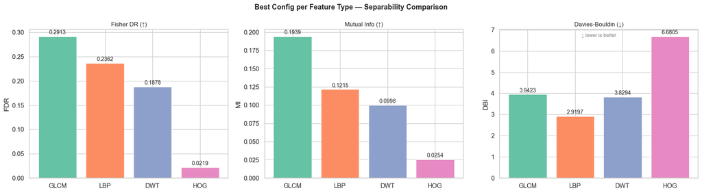

```
Phase 1 persistence skipped: outcome_hash matches last manifest row (same best hyperparameters and composite scores).
```

```python
print("=" * 65)
print("PHASE 1 COMPLETE — OPTIMAL FEATURE PARAMETERS SELECTED")
print("=" * 65)

print(f"\nGLCM:")
print(f"  distances  : {BEST_GLCM_DIST}")
print(f"  angles     : {[round(a,4) for a in BEST_GLCM_ANG]}")
print(f"  levels     : {BEST_GLCM_LVL}")
print(f"  symmetric  : {BEST_GLCM_SYM}")
print(f"  score      : {glcm_df.iloc[0]['score']:.4f}")

print(f"\nLBP:")
print(f"  P          : {BEST_LBP_P}")
print(f"  R          : {BEST_LBP_R}")
print(f"  method     : {BEST_LBP_METHOD}")
print(f"  score      : {lbp_df.iloc[0]['score']:.4f}")

print(f"\nDWT:")
print(f"  wavelet    : {BEST_DWT_WAV}")
print(f"  level      : {BEST_DWT_LEVEL}")
print(f"  score      : {dwt_df.iloc[0]['score']:.4f}")

print(f"\nHOG:")
print(f"  orientations    : {BEST_HOG_ORI}")
print(f"  pixels_per_cell : {BEST_HOG_PPC}")
print(f"  cells_per_block : {BEST_HOG_CPB}")
print(f"  block_norm      : {BEST_HOG_NORM}")
print(f"  score           : {hog_df.iloc[0]['score']:.4f}")

# ── Cross-feature comparison ───────────────────────────────────────────────
fig, axes = plt.subplots(1, 3, figsize=(18, 5))
fig.suptitle("Best Config per Feature Type — Separability Comparison",
             fontsize=13, fontweight="bold")

feat_labels = ["GLCM", "LBP", "DWT", "HOG"]
feat_scores = [glcm_df.iloc[0], lbp_df.iloc[0], dwt_df.iloc[0], hog_df.iloc[0]]
met_names   = ["FDR", "MI", "DBI"]
met_titles  = ["Fisher DR (↑)", "Mutual Info (↑)", "Davies-Bouldin (↓)"]
colors      = sns.color_palette("Set2", 4)

for ax, (mname, mtitle) in zip(axes, zip(met_names, met_titles)):
    vals = [r[mname] for r in feat_scores]
    bars = ax.bar(feat_labels, vals, color=colors, edgecolor="white", linewidth=0.5)
    ax.set_title(mtitle, fontsize=11)
    ax.set_ylabel(mname)
    ax.bar_label(bars, fmt="%.4f", fontsize=10, padding=2)
    if mname == "DBI":
        # Add annotation: lower is better
        ax.annotate("↓ lower is better", xy=(0.5, 0.95),
                    xycoords="axes fraction", ha="center",
                    fontsize=9, color="gray")

plt.tight_layout()
plt.savefig(OUTPUT_DIR / "phase1_summary.png", dpi=120, bbox_inches="tight")
plt.show()

save_phase1_bundle()
```

## 11. Phase 2 — Build Optimal Features & Run Model Benchmark

Now that optimal parameters are selected we:

1. Extract features using best GLCM, LBP, DWT, and HOG parameters
2. Also compute first-order stats
3. Fuse all branches
4. Run GridSearchCV per model (SVM · KNN · RF · XGBoost · LightGBM · LR · MLP · ExtraTrees)
5. Produce a final performance dashboard

```
Extracting features with OPTIMAL parameters …
Loading features from cache: cache\brain_tumor\features_83384d866f.npz

Feature sizes (train):
  A (Stats)  : 11
  B (Tex)    : 20  (GLCM=6 + LBP=14)
  C (DWT)    : 16
  D (HOG)    : 1944
  FULL fused : 1991
```

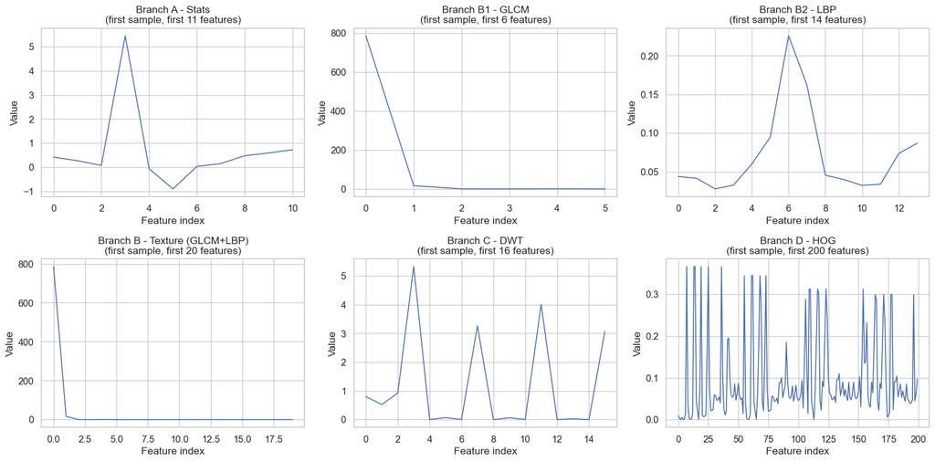

|  | Branch | n_features | train_mean | train_std |
| --- | --- | --- | --- | --- |
| 0 | A_Stats | 11 | 0.689342 | 1.654999 |
| 1 | B_Texture | 20 | 47.414516 | 203.822739 |
| 2 | C_DWT | 16 | 1.220982 | 1.838821 |
| 3 | D_HOG | 1944 | 0.110992 | 0.078735 |
| 4 | FULL | 1991 | 0.598281 | 20.966999 |

```python
# Fresh kernel / Phase 2 only: set LOAD_PHASE1_BUNDLE_FOR_PHASE2 = True in config, then run
# imports → config → dataset → extractors → Phase 1 bundle cell before this one.
# Phase 1 also writes cache/brain_tumor/phase_artifacts/phase1_best.json and phase1_runs_manifest.csv.

print("Extracting features with OPTIMAL parameters …")

# ── First-order stats (no tunable params) ────────────────────────────────
def feat_stats(img):
    v = img.ravel()
    h, _ = np.histogram(v, bins=64, range=(0,1), density=True)
    h = (h+1e-12); h /= h.sum()
    ent = -(h*np.log2(h)).sum()
    p10,p25,p50,p75,p90 = np.percentile(v, [10,25,50,75,90])
    return np.array([v.mean(),v.std(),v.var(),ent,skew(v),kurtosis(v),
                     p10,p25,p50,p75,p90], np.float32)

def feat_hog(img):
    return hog(
        img,
        orientations=BEST_HOG_ORI,
        pixels_per_cell=tuple(BEST_HOG_PPC),
        cells_per_block=tuple(BEST_HOG_CPB),
        block_norm=BEST_HOG_NORM,
        feature_vector=True,
    ).astype(np.float32)

feature_cache_tag = (
    f"feat_glcm{BEST_GLCM_DIST}_{BEST_GLCM_ANG}_{BEST_GLCM_LVL}_{int(BEST_GLCM_SYM)}"
    f"_lbp{BEST_LBP_P}_{BEST_LBP_R}_{BEST_LBP_METHOD}_dwt{BEST_DWT_WAV}_{BEST_DWT_LEVEL}"
    f"_hog{BEST_HOG_ORI}_{tuple(BEST_HOG_PPC)}_{tuple(BEST_HOG_CPB)}_{BEST_HOG_NORM}"
)
feature_cache_hash = hashlib.md5(feature_cache_tag.encode("utf-8")).hexdigest()[:10]
feature_cache_path = CACHE_DIR / f"features_{feature_cache_hash}.npz"

if feature_cache_path.exists() and not FORCE_RECOMPUTE_CACHE:
    print(f"Loading features from cache: {feature_cache_path}")
    ft = np.load(feature_cache_path)
    A_tr, A_te = ft["A_tr"], ft["A_te"]
    B_glcm_tr, B_glcm_te = ft["B_glcm_tr"], ft["B_glcm_te"]
    B_lbp_tr, B_lbp_te = ft["B_lbp_tr"], ft["B_lbp_te"]
    B_tr, B_te = ft["B_tr"], ft["B_te"]
    C_tr, C_te = ft["C_tr"], ft["C_te"]
    D_tr, D_te = ft["D_tr"], ft["D_te"]
    FULL_tr, FULL_te = ft["FULL_tr"], ft["FULL_te"]
else:
    # ── Extract all branches ───────────────────────────────────────────────
    print("  Branch A: Stats …")
    A_tr = np.vstack([feat_stats(x) for x in tqdm(X_train_raw)])
    A_te = np.vstack([feat_stats(x) for x in tqdm(X_test_raw)])

    print("  Branch B: GLCM (optimal params) …")
    B_glcm_tr = extract_glcm(X_train_raw, BEST_GLCM_DIST, BEST_GLCM_ANG,
                             BEST_GLCM_LVL, BEST_GLCM_SYM)
    B_glcm_te = extract_glcm(X_test_raw,  BEST_GLCM_DIST, BEST_GLCM_ANG,
                             BEST_GLCM_LVL, BEST_GLCM_SYM)

    print("  Branch B: LBP (optimal params) …")
    B_lbp_tr = extract_lbp(X_train_raw, BEST_LBP_P, BEST_LBP_R, BEST_LBP_METHOD)
    B_lbp_te = extract_lbp(X_test_raw,  BEST_LBP_P, BEST_LBP_R, BEST_LBP_METHOD)

    # Combine GLCM + LBP into Branch B
    B_tr = np.hstack([B_glcm_tr, B_lbp_tr]).astype(np.float32)
    B_te = np.hstack([B_glcm_te, B_lbp_te]).astype(np.float32)

    print("  Branch C: DWT (optimal params) …")
    C_tr = extract_dwt(X_train_raw, BEST_DWT_WAV, BEST_DWT_LEVEL)
    C_te = extract_dwt(X_test_raw,  BEST_DWT_WAV, BEST_DWT_LEVEL)

    print("  Branch D: HOG …")
    D_tr = np.vstack([feat_hog(x) for x in tqdm(X_train_raw)])
    D_te = np.vstack([feat_hog(x) for x in tqdm(X_test_raw)])

    # Full fusion
    FULL_tr = np.hstack([A_tr, B_tr, C_tr, D_tr]).astype(np.float32)
    FULL_te = np.hstack([A_te, B_te, C_te, D_te]).astype(np.float32)

    np.savez_compressed(
        feature_cache_path,
        A_tr=A_tr, A_te=A_te,
        B_glcm_tr=B_glcm_tr, B_glcm_te=B_glcm_te,
        B_lbp_tr=B_lbp_tr, B_lbp_te=B_lbp_te,
        B_tr=B_tr, B_te=B_te,
        C_tr=C_tr, C_te=C_te,
        D_tr=D_tr, D_te=D_te,
        FULL_tr=FULL_tr, FULL_te=FULL_te,
    )
    print(f"Saved feature cache: {feature_cache_path}")

print(f"\nFeature sizes (train):")
print(f"  A (Stats)  : {A_tr.shape[1]}")
print(f"  B (Tex)    : {B_tr.shape[1]}  (GLCM={B_glcm_tr.shape[1]} + LBP={B_lbp_tr.shape[1]})")
print(f"  C (DWT)    : {C_tr.shape[1]}")
print(f"  D (HOG)    : {D_tr.shape[1]}")
print(f"  FULL fused : {FULL_tr.shape[1]}")

# ── Feature extraction plotting for each branch ──────────────────────────
def plot_feature_preview(ax, X, title, max_points=200):
    n_show = min(max_points, X.shape[1])
    ax.plot(X[0, :n_show], lw=1.2)
    ax.set_title(f"{title}\n(first sample, first {n_show} features)")
    ax.set_xlabel("Feature index")
    ax.set_ylabel("Value")

fig, axes = plt.subplots(2, 3, figsize=(16, 8))
plot_feature_preview(axes[0, 0], A_tr, "Branch A - Stats")
plot_feature_preview(axes[0, 1], B_glcm_tr, "Branch B1 - GLCM")
plot_feature_preview(axes[0, 2], B_lbp_tr, "Branch B2 - LBP")
plot_feature_preview(axes[1, 0], B_tr, "Branch B - Texture (GLCM+LBP)")
plot_feature_preview(axes[1, 1], C_tr, "Branch C - DWT")
plot_feature_preview(axes[1, 2], D_tr, "Branch D - HOG")
plt.tight_layout()
plt.show()

# Distribution summary by branch (mean +/- std)
branch_stats = pd.DataFrame({
    "Branch": ["A_Stats", "B_Texture", "C_DWT", "D_HOG", "FULL"],
    "n_features": [A_tr.shape[1], B_tr.shape[1], C_tr.shape[1], D_tr.shape[1], FULL_tr.shape[1]],
    "train_mean": [A_tr.mean(), B_tr.mean(), C_tr.mean(), D_tr.mean(), FULL_tr.mean()],
    "train_std": [A_tr.std(), B_tr.std(), C_tr.std(), D_tr.std(), FULL_tr.std()],
})

display(branch_stats)
```

```
Cleaning feature sets …
  A — Stats           raw=   11  after_var=   11  cleaned=    9  kept= 81.82%
  B — Tex(opt)        raw=   20  after_var=   20  cleaned=   18  kept= 90.00%
  C — DWT(opt)        raw=   16  after_var=   16  cleaned=   12  kept= 75.00%
  D — HOG             raw= 1944  after_var= 1944  cleaned=  490  kept= 25.21%
  A+B                 raw=   31  after_var=   31  cleaned=   27  kept= 87.10%
  B+C(opt)            raw=   36  after_var=   36  cleaned=   30  kept= 83.33%
  A+B+C(opt)          raw=   47  after_var=   47  cleaned=   36  kept= 76.60%
  Full(opt)           raw= 1991  after_var= 1991  cleaned=  526  kept= 26.42%
```

|  | Feature Set | Raw Features | After Variance Filter | Cleaned Features | Removed Features | Kept Ratio (%) |
| --- | --- | --- | --- | --- | --- | --- |
| 0 | A — Stats | 11 | 11 | 9 | 2 | 81.818182 |
| 1 | B — Tex(opt) | 20 | 20 | 18 | 2 | 90.000000 |
| 2 | C — DWT(opt) | 16 | 16 | 12 | 4 | 75.000000 |
| 3 | D — HOG | 1944 | 1944 | 490 | 1454 | 25.205761 |
| 4 | A+B | 31 | 31 | 27 | 4 | 87.096774 |
| 5 | B+C(opt) | 36 | 36 | 30 | 6 | 83.333333 |
| 6 | A+B+C(opt) | 47 | 47 | 36 | 11 | 76.595745 |
| 7 | Full(opt) | 1991 | 1991 | 526 | 1465 | 26.418885 |

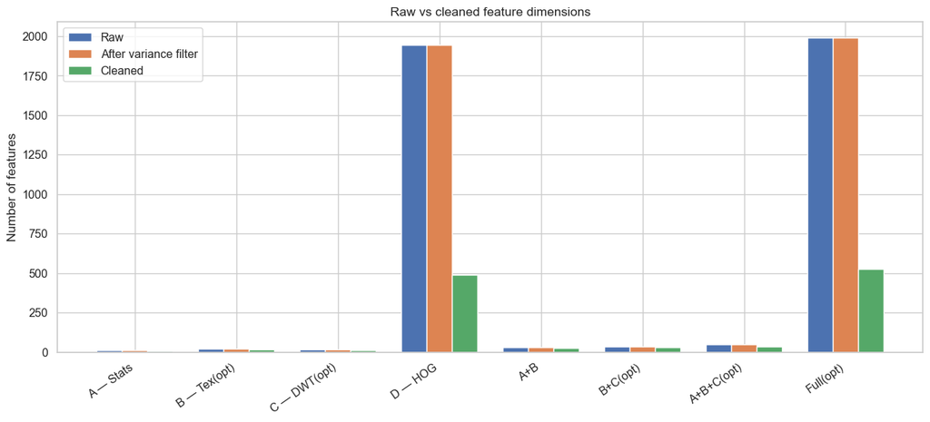

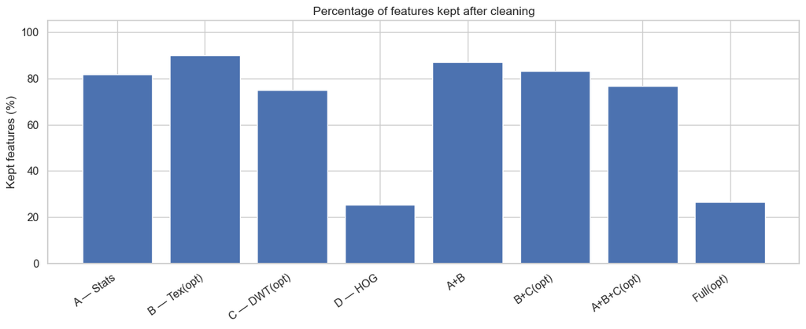

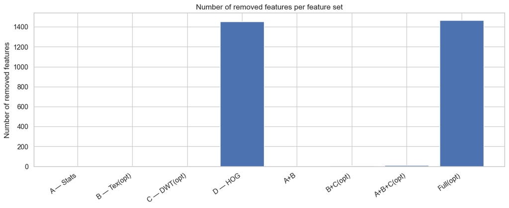

```python
# ── Cleaning pipeline ─────────────────────────────────────────────────────
from sklearn.feature_selection import VarianceThreshold
from sklearn.preprocessing import StandardScaler
import numpy as np
import pandas as pd
import matplotlib.pyplot as plt

def clean_scale(Xtr, Xte, corr_thr=0.95):
    original_dim = Xtr.shape[1]

    # 1) Remove constant features
    vt = VarianceThreshold(0.0)
    Xtr_vt = vt.fit_transform(Xtr)
    Xte_vt = vt.transform(Xte)

    after_variance_dim = Xtr_vt.shape[1]

    # Track kept columns after variance filtering
    kept_after_variance = vt.get_support(indices=True)

    # 2) Remove highly correlated features
    kept_after_corr = np.arange(after_variance_dim)

    if Xtr_vt.shape[1] < 5000:
        corr = pd.DataFrame(Xtr_vt).corr().abs()
        upper = corr.where(np.triu(np.ones(corr.shape), k=1).astype(bool))

        drop = [c for c in upper.columns if any(upper[c] > corr_thr)]

        if drop:
            keep = np.ones(Xtr_vt.shape[1], dtype=bool)
            keep[np.array(drop, int)] = False

            Xtr_vt = Xtr_vt[:, keep]
            Xte_vt = Xte_vt[:, keep]

            kept_after_corr = np.where(keep)[0]

    after_corr_dim = Xtr_vt.shape[1]

    # Final kept original feature indices
    final_kept_original_indices = kept_after_variance[kept_after_corr]

    # 3) Standardization
    sc = StandardScaler()
    Xtr_clean = sc.fit_transform(Xtr_vt)
    Xte_clean = sc.transform(Xte_vt)

    info = {
        "raw_dim": original_dim,
        "after_variance_dim": after_variance_dim,
        "after_corr_dim": after_corr_dim,
        "kept_indices": final_kept_original_indices,
        "removed_dim": original_dim - after_corr_dim,
        "kept_ratio": after_corr_dim / original_dim if original_dim > 0 else 0
    }

    return Xtr_clean, Xte_clean, info


# Feature sets to benchmark in Phase 2
OPT_SETS = {
    "A — Stats":       (A_tr, A_te),
    "B — Tex(opt)":    (B_tr, B_te),
    "C — DWT(opt)":    (C_tr, C_te),
    "D — HOG":         (D_tr, D_te),
    "A+B":             (np.hstack([A_tr, B_tr]), np.hstack([A_te, B_te])),
    "B+C(opt)":        (np.hstack([B_tr, C_tr]), np.hstack([B_te, C_te])),
    "A+B+C(opt)":      (np.hstack([A_tr, B_tr, C_tr]), np.hstack([A_te, B_te, C_te])),
    "Full(opt)":       (FULL_tr, FULL_te),
}

print("Cleaning feature sets …")

CLEAN_OPT = {}
CLEAN_INFO = {}

for name, (tr, te) in OPT_SETS.items():
    ct, ce, info = clean_scale(tr.astype(np.float32), te.astype(np.float32))

    CLEAN_OPT[name] = (ct, ce)
    CLEAN_INFO[name] = info

    print(
        f"  {name:18s}  "
        f"raw={info['raw_dim']:5d}  "
        f"after_var={info['after_variance_dim']:5d}  "
        f"cleaned={info['after_corr_dim']:5d}  "
        f"kept={info['kept_ratio']*100:6.2f}%"
    )


# ── Plot 1: Raw vs cleaned feature dimensions ─────────────────────────────
summary_df = pd.DataFrame([
    {
        "Feature Set": name,
        "Raw Features": info["raw_dim"],
        "After Variance Filter": info["after_variance_dim"],
        "Cleaned Features": info["after_corr_dim"],
        "Removed Features": info["removed_dim"],
        "Kept Ratio (%)": info["kept_ratio"] * 100
    }
    for name, info in CLEAN_INFO.items()
])

display(summary_df)

plt.figure(figsize=(13, 6))
x = np.arange(len(summary_df))
width = 0.25

plt.bar(x - width, summary_df["Raw Features"], width, label="Raw")
plt.bar(x, summary_df["After Variance Filter"], width, label="After variance filter")
plt.bar(x + width, summary_df["Cleaned Features"], width, label="Cleaned")

plt.xticks(x, summary_df["Feature Set"], rotation=35, ha="right")
plt.ylabel("Number of features")
plt.title("Raw vs cleaned feature dimensions")
plt.legend()
plt.tight_layout()
plt.show()


# ── Plot 2: Percentage of kept features ───────────────────────────────────
plt.figure(figsize=(12, 5))
plt.bar(summary_df["Feature Set"], summary_df["Kept Ratio (%)"])

plt.xticks(rotation=35, ha="right")
plt.ylabel("Kept features (%)")
plt.title("Percentage of features kept after cleaning")
plt.ylim(0, 105)
plt.tight_layout()
plt.show()


# ── Plot 3: Removed features count ────────────────────────────────────────
plt.figure(figsize=(12, 5))
plt.bar(summary_df["Feature Set"], summary_df["Removed Features"])

plt.xticks(rotation=35, ha="right")
plt.ylabel("Number of removed features")
plt.title("Number of removed features per feature set")
plt.tight_layout()
plt.show()
```

```python
# ── Model benchmark grids (Phase 2) ───────────────────────────────────────
CV_FOLDS = 5
CV = StratifiedKFold(n_splits=CV_FOLDS, shuffle=True, random_state=SEED)

MODEL_GRIDS = {
    # SVM: test linear, polynomial, RBF, and sigmoid kernels
    "SVM": [
        {"kernel": ["linear"], "C": [0.001, 0.01, 0.1, 1, 10, 100, 1000]},
        {
            "kernel": ["rbf"],
            "C": [0.001, 0.01, 0.1, 1, 10, 100, 1000],
            "gamma": ["scale", "auto", 1e-4, 1e-3, 1e-2, 1e-1, 1, 10],
        },
        {
            "kernel": ["poly"],
            "C": [0.001, 0.01, 0.1, 1, 10, 100],
            "gamma": ["scale", "auto", 1e-4, 1e-3, 1e-2, 1e-1, 1],
            "degree": [2, 3, 4, 5],
            "coef0": [0.0, 0.1, 0.5, 1.0],
        },
        {
            "kernel": ["sigmoid"],
            "C": [0.001, 30.01, 0.1, 1, 10, 100],
            "gamma": ["scale", "auto", 1e-4, 1e-3, 1e-2, 1e-1, 1],
            "coef0": [0.0, 0.1, 0.5, 1.0],
        },
    ],
    # KNN: test small and large neighborhoods, several distances, and weighting
    "KNN": {
        "n_neighbors": [1, 2, 3, 5, 7, 9, 11, 15, 21, 31, 41, 51],
        "metric": ["euclidean", "manhattan", "chebyshev", "minkowski"],
        "weights": ["uniform", "distance"],
        "p": [1, 2, 3, 4],
    },
    # Random Forest: test small, medium, and large forests with different tree constraint
    "RF": {
        "n_estimators": [50, 100, 200, 300, 500, 800, 1000],
        "max_depth": [None, 5, 10, 20, 30, 50, 80],
        "max_features": ["sqrt", "log2", None],
        "min_samples_split": [2, 5, 10, 20],
        "min_samples_leaf": [1, 2, 4, 8],
        "bootstrap": [True, False],
        "criterion": ["gini", "entropy", "log_loss"],
    },
    "XGBoost": {
        "n_estimators":     [100, 300, 500, 800],
        "max_depth":        [3, 4, 5, 6, 8],
        "learning_rate":    [0.01, 0.05, 0.1, 0.2],
        "subsample":        [0.7, 0.8, 1.0],
        "colsample_bytree": [0.7, 0.8, 1.0],
        "min_child_weight": [1, 3, 5],
        "gamma":            [0, 0.1, 0.3],
    },
    "LightGBM": {
        "n_estimators":      [100, 300, 500, 800],
        "max_depth":         [-1, 4, 6, 8],
        "learning_rate":     [0.01, 0.05, 0.1, 0.2],
        "num_leaves":        [15, 31, 63, 127],
        "subsample":         [0.7, 0.8, 1.0],
        "colsample_bytree":  [0.7, 0.8, 1.0],
        "min_child_samples": [5, 10, 20],
    },
    "LR": [
        {
            **{"lr__C": [c], "lr__penalty": [p], "lr__class_weight": [cw]},
            **({"lr__l1_ratio": [l1]} if p == "elasticnet" else {}),
        }
        for c in [0.001, 0.01, 0.1, 1, 10, 100]
        for p in ["l1", "l2", "elasticnet"]
        for cw in ["balanced", None]
        for l1 in ([0.1, 0.5, 0.9] if p == "elasticnet" else [None])
        if p == "elasticnet" or l1 is None
    ],
    "MLP": {
        "hidden_layer_sizes": [(256,), (512,), (256, 128), (512, 256), (512, 256, 128)],
        "activation":         ["relu", "tanh"],
        "alpha":              [1e-4, 1e-3, 1e-2],
        "learning_rate_init": [1e-3, 5e-4, 1e-4],
        "batch_size":         [32, 64, 128],
        "early_stopping":     [True],
        "max_iter":           [500],
    },
    "ExtraTrees": {
        "n_estimators":      [100, 300, 500],
        "max_features":      ["sqrt", "log2", None],
        "min_samples_split": [2, 5, 10],
        "min_samples_leaf":  [1, 2, 4],
        "criterion":         ["gini", "entropy"],
    },
}
```

```python
# ── Phase 2 benchmark (setup) ─────────────────────────────────────────────
# Run each model in its own cell below, then run the finalize cell to export metrics.
# Re-running this cell clears P2_ALL and P2 in memory; completed jobs stay on disk under
# phase2_benchmark/ (*.pkl + *.meta.json + *_cv_results.csv). Re-run a model cell to resume
# — finished (mode, feature_set) jobs load from cache; interrupted jobs restart that job only.
from sklearn.model_selection import StratifiedShuffleSplit, cross_val_predict
from sklearn.base import clone
from pathlib import Path
from datetime import datetime, timezone
import json

MAX_EVAL_FOLDS = 5
# GridSearchCV.fit console verbosity (sklearn: 0=quiet, 1–3 more detail)
PHASE2_GS_VERBOSE = 2
# split = held-out test set; cv_1 = one stratified shuffle split on train; cv_2…cv_5 = k-fold CV on train
EVAL_MODES = ["split"] + [f"cv_{k}" for k in range(1, MAX_EVAL_FOLDS + 1)]
print(f"Phase 2 eval modes ({len(EVAL_MODES)}): {EVAL_MODES}")

PHASE2_MODEL_ORDER = [
    "SVM", "KNN", "RF", "XGBoost", "LightGBM", "LR", "MLP", "ExtraTrees",
]

ESTIMATORS = {
    "SVM": SVC(random_state=SEED, probability=True),
    "KNN": KNeighborsClassifier(),
    "RF":  RandomForestClassifier(random_state=SEED, n_jobs=-1),
    "XGBoost": XGBClassifier(
        random_state=SEED, n_jobs=-1, eval_metric="mlogloss", verbosity=0,
    ),
    "LightGBM": LGBMClassifier(random_state=SEED, n_jobs=-1, verbose=-1),
    "LR": Pipeline([
        ("scaler", StandardScaler()),
        ("lr", LogisticRegression(solver="saga", max_iter=1000)),
    ]),
    "MLP": MLPClassifier(
        random_state=SEED, early_stopping=True, validation_fraction=0.1, max_iter=500,
    ),
    "ExtraTrees": ExtraTreesClassifier(random_state=SEED, n_jobs=-1),
}

PALETTE = {
    "SVM": "#4C72B0", "KNN": "#DD8452", "RF": "#55A868",
    "XGBoost": "#C44E52", "LightGBM": "#8172B3", "LR": "#CCB974",
    "MLP": "#64B5CD", "ExtraTrees": "#8C8C8C",
}
_FALLBACK_COLORS = sns.color_palette("husl", 12)

def _model_color(mn):
    if mn in PALETTE:
        return PALETTE[mn]
    return _FALLBACK_COLORS[hash(mn) % len(_FALLBACK_COLORS)]


def _sanitize_cv_results_df(df):
    """Convert extension dtypes (e.g. pandas StringDtype) to plain object for stable joblib round-trips."""
    if not isinstance(df, pd.DataFrame):
        return df
    out = df.copy()
    for col in out.columns:
        dt = out[col].dtype
        if not isinstance(dt, np.dtype):
            out[col] = out[col].astype(object)
    return out


def _sanitize_phase2_payload(payload):
    if not isinstance(payload, dict):
        return payload
    out = dict(payload)
    if "cv_results" in out:
        out["cv_results"] = _sanitize_cv_results_df(out["cv_results"])
    return out


def _safe_joblib_load(path):
    try:
        return joblib.load(path)
    except Exception as exc:
        print(f"  [RESUME] cache unreadable ({type(exc).__name__}: {exc}) — re-running …")
        return None

def _cv_for_mode(mode):
    if mode == "split":
        return CV
    if mode == "cv_1":
        # sklearn KFold/StratifiedKFold needs n_splits >= 2, so cv_1 uses one stratified shuffle split.
        return StratifiedShuffleSplit(n_splits=1, test_size=0.2, random_state=SEED)
    if mode.startswith("cv_"):
        k = int(mode.split("_")[1])
        k = min(k, MAX_EVAL_FOLDS)  # enforce max folds
        return StratifiedKFold(n_splits=k, shuffle=True, random_state=SEED)
    raise ValueError(f"Unsupported mode: {mode}")


def _param_grid_size(grid):
    if isinstance(grid, dict):
        n = 1
        for v in grid.values():
            n *= len(v) if hasattr(v, "__len__") and not isinstance(v, str) else 1
        return int(n)
    if isinstance(grid, list):
        return sum(_param_grid_size(g) for g in grid)
    return 0


def run_grid(est, grid, Xtr, Xte, mode, mn, fs_name):
    cv_obj = _cv_for_mode(mode)
    n_cand = _param_grid_size(grid)
    print(f"    GridSearchCV: {n_cand} parameter settings × CV — this may take a while …")
    gs = GridSearchCV(
        est,
        grid,
        scoring="f1_macro",
        cv=cv_obj,
        n_jobs=-1,
        refit=True,
        return_train_score=False,
        verbose=PHASE2_GS_VERBOSE,
    )

    t0 = time.time()
    gs.fit(Xtr, y_train)
    fit_t = time.time() - t0
    print(f"    GridSearchCV done in {fit_t:.1f}s  |  best_cv={gs.best_score_:.4f}  |  best_params={gs.best_params_}")

    if mode == "split":
        t0 = time.time()
        yp = gs.best_estimator_.predict(Xte)
        pred_t = time.time() - t0
        y_eval = y_test
    elif mode == "cv_1":
        # cross_val_predict requires partition-style CV; StratifiedShuffleSplit is not one.
        # For cv_1, evaluate on its single held-out fold directly.
        tr_idx, te_idx = next(cv_obj.split(Xtr, y_train))
        est1 = clone(gs.best_estimator_)
        est1.fit(Xtr[tr_idx], y_train[tr_idx])
        t0 = time.time()
        yp = est1.predict(Xtr[te_idx])
        pred_t = time.time() - t0
        y_eval = y_train[te_idx]
    else:
        t0 = time.time()
        yp = cross_val_predict(gs.best_estimator_, Xtr, y_train, cv=cv_obj, n_jobs=-1)
        pred_t = time.time() - t0
        y_eval = y_train

    return {
        "eval_mode": mode,
        "best_params":   gs.best_params_,
        "best_cv":       gs.best_score_,
        "cv_results":    _sanitize_cv_results_df(pd.DataFrame(gs.cv_results_)),
        "y_pred":        yp,
        "acc":  accuracy_score(y_eval, yp),
        "f1m":  f1_score(y_eval, yp, average="macro",    zero_division=0),
        "f1w":  f1_score(y_eval, yp, average="weighted", zero_division=0),
        "prec": precision_score(y_eval, yp, average="macro", zero_division=0),
        "rec":  recall_score(y_eval, yp, average="macro",  zero_division=0),
        "fit_t": fit_t,
        "pred_t": pred_t,
        "estimator": gs.best_estimator_,
    }

# Cache per (mode, feature_set, model): safe to stop the notebook between jobs — re-run the same
# model cell; finished jobs reload from disk. Each job also writes *.meta.json + *_cv_results.csv.
phase2_cache_dir = PHASE_CACHE_DIR / "phase2_benchmark"
phase2_cache_dir.mkdir(parents=True, exist_ok=True)
PHASE2_MANIFEST_PATH = phase2_cache_dir / "phase2_checkpoint_manifest.json"
```

```python
def _phase2_cache_file(mode, fs_name, model_name):
    tag = f"{mode}|{fs_name}|{model_name}|seed={SEED}|cv={CV_FOLDS}|n={len(y_train)}"
    h = hashlib.md5(tag.encode("utf-8")).hexdigest()[:12]
    return phase2_cache_dir / f"{h}.pkl"


def _atomic_joblib_dump(obj, path: Path):
    path = Path(path)
    tmp = path.with_suffix(path.suffix + ".tmp")
    joblib.dump(obj, tmp)
    tmp.replace(path)


def _read_manifest():
    if not PHASE2_MANIFEST_PATH.exists():
        return {"runs": []}
    try:
        return json.loads(PHASE2_MANIFEST_PATH.read_text(encoding="utf-8"))
    except Exception:
        return {"runs": []}


def _write_manifest(manifest):
    tmp = phase2_cache_dir / (PHASE2_MANIFEST_PATH.name + ".tmp")
    tmp.write_text(json.dumps(manifest, indent=2, default=str), encoding="utf-8")
    tmp.replace(PHASE2_MANIFEST_PATH)


def _export_cv_and_summary(cache_stem, r, mn, mode, fs_name):
    """Full per-parameter CV metrics (CSV) + compact summary (JSON)."""
    cv_df = r["cv_results"].copy()
    cv_df.insert(0, "feature_set", fs_name)
    cv_df.insert(0, "eval_mode", mode)
    cv_df.insert(0, "model", mn)
    csv_path = phase2_cache_dir / f"{cache_stem}_cv_results.csv"
    cv_df.to_csv(csv_path, index=False)
    summ = {
        "model": mn,
        "eval_mode": mode,
        "feature_set": fs_name,
        "best_params": r["best_params"],
        "best_cv_f1_macro": float(r["best_cv"]),
        "test_acc": float(r["acc"]),
        "test_f1_macro": float(r["f1m"]),
        "fit_time_s": float(r["fit_t"]),
        "predict_time_s": float(r["pred_t"]),
        "n_candidates": int(len(cv_df)),
        "cv_results_csv": str(csv_path.resolve()),
    }
    json_path = phase2_cache_dir / f"{cache_stem}_summary.json"
    json_path.write_text(json.dumps(summ, indent=2, default=str), encoding="utf-8")
    return csv_path, json_path


def _ensure_legacy_sidecars(cache_file: Path, payload, mn, mode, fs_name):
    """Older checkpoints had only .pkl — add meta + CSV/JSON once (no manifest append)."""
    meta_path = cache_file.with_suffix(".meta.json")
    if meta_path.exists():
        return
    stem = cache_file.stem
    csv_path, json_path = _export_cv_and_summary(stem, payload, mn, mode, fs_name)
    meta = {
        "model": mn,
        "eval_mode": mode,
        "feature_set": fs_name,
        "cache_pkl": str(cache_file.resolve()),
        "saved_at_utc": datetime.now(timezone.utc).isoformat(),
        "best_cv": float(payload["best_cv"]),
        "acc": float(payload["acc"]),
        "f1_macro": float(payload["f1m"]),
        "cv_results_csv": str(csv_path.resolve()),
        "summary_json": str(json_path.resolve()),
        "migrated_from_pkl_only": True,
    }
    meta_path.write_text(json.dumps(meta, indent=2, default=str), encoding="utf-8")
    print(f"  [MIGRATE] wrote sidecars for legacy checkpoint {cache_file.name}")


def _persist_phase2_job(cache_file: Path, payload, mn, mode, fs_name):
    stem = cache_file.stem
    csv_path, json_path = _export_cv_and_summary(stem, payload, mn, mode, fs_name)
    meta = {
        "model": mn,
        "eval_mode": mode,
        "feature_set": fs_name,
        "cache_pkl": str(cache_file.resolve()),
        "saved_at_utc": datetime.now(timezone.utc).isoformat(),
        "best_cv": float(payload["best_cv"]),
        "acc": float(payload["acc"]),
        "f1_macro": float(payload["f1m"]),
        "cv_results_csv": str(csv_path.resolve()),
        "summary_json": str(json_path.resolve()),
    }
    meta_path = cache_file.with_suffix(".meta.json")
    meta_path.write_text(json.dumps(meta, indent=2, default=str), encoding="utf-8")
    _atomic_joblib_dump(_sanitize_phase2_payload(payload), cache_file)
    man = _read_manifest()
    man.setdefault("runs", [])
    man["runs"].append(meta)
    _write_manifest(man)


def phase2_hydrate_from_disk(model_name=None):
    """Rebuild P2_ALL / P2 from checkpoint files (e.g. after kernel restart)."""
    n = 0
    for meta_path in sorted(phase2_cache_dir.glob("*.meta.json")):
        try:
            meta = json.loads(meta_path.read_text(encoding="utf-8"))
        except Exception:
            continue
        mn = meta.get("model")
        if model_name is not None and mn != model_name:
            continue
        pkl_path = Path(meta["cache_pkl"])
        if not pkl_path.exists():
            pkl_path = meta_path.with_suffix(".pkl")
        if not pkl_path.exists():
            continue
        r = _safe_joblib_load(pkl_path)
        if r is None:
            continue
        mode = meta["eval_mode"]
        fs_name = meta["feature_set"]
        P2_ALL.setdefault(mode, {}).setdefault(fs_name, {})[mn] = r
        if mode == "split":
            P2.setdefault(fs_name, {})[mn] = r
        n += 1
    if n:
        print(f"phase2_hydrate_from_disk: loaded {n} completed job(s)" + (f" for {model_name}" if model_name else ""))


P2_ALL = {}
P2 = {}


def get_split_P2():
    """Return split-mode Phase 2 results."""
    if P2_ALL.get("split"):
        return P2_ALL["split"]
    return P2


def models_in_p2(p2=None, order=None):
    """Models present in P2 (not a hardcoded SVM/KNN/RF list)."""
    p2 = p2 or get_split_P2()
    if not p2:
        return []
    found = {m for d in p2.values() for m in d}
    order = order or PHASE2_MODEL_ORDER
    return [m for m in order if m in found] or sorted(found)


def init_phase2_viz_context():
    """Set global P2, fs_list, mnames for downstream plots/stats."""
    global P2, fs_list, mnames
    P2 = get_split_P2()
    if not P2:
        raise ValueError("Phase 2 results are empty — run the benchmark model cells first.")
    fs_list = list(P2.keys())
    mnames = models_in_p2(P2)
    if not mnames:
        raise ValueError("No models found in P2 — run at least one Phase 2 model cell.")
    return P2, fs_list, mnames


def run_phase2_for_model(mn):
    if mn not in ESTIMATORS:
        raise ValueError(f"Unknown model {mn!r}; use one of {list(ESTIMATORS)}")
    phase2_hydrate_from_disk(mn)
    est = ESTIMATORS[mn]
    for mode in EVAL_MODES:
        print(f"\nMode: {mode}  |  model: {mn}")
        print("=" * 65)
        P2_ALL.setdefault(mode, {})
        for fs_name, (Xtr, Xte) in CLEAN_OPT.items():
            print(f"\n{'─' * 60}")
            print(f"Feature set: {fs_name}  ({Xtr.shape[1]} features)")
            P2_ALL[mode].setdefault(fs_name, {})
            cache_file = _phase2_cache_file(mode, fs_name, mn)
            print(f"  {mn}  checkpoint: {cache_file.name}", flush=True)
            r = None
            if USE_PHASE_CACHE and cache_file.exists() and not FORCE_RECOMPUTE_CACHE:
                r = _safe_joblib_load(cache_file)
                if "estimator" in r and "cv_results" in r:
                    pl = {
                        k: v
                        for k, v in r.items()
                        if k
                        in {
                            "eval_mode",
                            "best_params",
                            "best_cv",
                            "acc",
                            "f1m",
                            "f1w",
                            "prec",
                            "rec",
                            "fit_t",
                            "pred_t",
                            "cv_results",
                            "y_pred",
                            "estimator",
                        }
                    }
                    _ensure_legacy_sidecars(cache_file, pl, mn, mode, fs_name)
                    print(f"  [RESUME] loaded from disk — acc={r['acc']:.3f}  f1_macro={r['f1m']:.3f}")
                else:
                    print("  [RESUME] cache missing fields — re-running …")
                    r = None
            if r is None:
                r = run_grid(
                    clone(est),
                    MODEL_GRIDS[mn],
                    Xtr,
                    Xte,
                    mode,
                    mn,
                    fs_name,
                )
                payload = {
                    k: v
                    for k, v in r.items()
                    if k
                    in {
                        "eval_mode",
                        "best_params",
                        "best_cv",
                        "acc",
                        "f1m",
                        "f1w",
                        "prec",
                        "rec",
                        "fit_t",
                        "pred_t",
                        "cv_results",
                        "y_pred",
                        "estimator",
                    }
                }
                if USE_PHASE_CACHE:
                    _persist_phase2_job(cache_file, payload, mn, mode, fs_name)
                    print(f"  [SAVE] metrics + CV grid → {cache_file.name}, *.meta.json, *_cv_results.csv")
                r = payload
            P2_ALL[mode][fs_name][mn] = r
            if mode == "split":
                P2.setdefault(fs_name, {})[mn] = r
            print(f"  done  acc={r['acc']:.3f}  f1={r['f1m']:.3f}  fit_t={r['fit_t']:.1f}s")
```

```python
def phase2_finalize_metrics():
    # Build PHASE2_ALL_METRICS_DF and save CSV / cache from whatever is in P2_ALL.
    global PHASE2_ALL_METRICS_DF
    if not P2_ALL:
        print("P2_ALL is empty — loading completed jobs from disk (all models) …")
        phase2_hydrate_from_disk()
    if not P2_ALL:
        print("Warning: nothing to export. Run the Phase 2 model cells first, or check", phase2_cache_dir)
        return
    rows = []
    for mode in EVAL_MODES:
        if mode not in P2_ALL:
            continue
        for fs_name in CLEAN_OPT:
            if fs_name not in P2_ALL[mode]:
                continue
            for mn, r in P2_ALL[mode][fs_name].items():
                rows.append({
                    "eval_mode": mode,
                    "feature_set": fs_name,
                    "model": mn,
                    "acc": r["acc"],
                    "f1_macro": r["f1m"],
                    "f1_weighted": r["f1w"],
                    "precision_macro": r["prec"],
                    "recall_macro": r["rec"],
                    "fit_time_s": r["fit_t"],
                    "predict_time_s": r["pred_t"],
                    "best_cv": r["best_cv"],
                    "best_params": str(r["best_params"]),
                })
    PHASE2_ALL_METRICS_DF = pd.DataFrame(rows)
    PHASE2_ALL_METRICS_DF.to_csv("phase2_all_modes_metrics.csv", index=False)
    if USE_PHASE_CACHE:
        joblib.dump(PHASE2_ALL_METRICS_DF, PHASE_CACHE_DIR / "phase2_all_metrics_df.pkl")
        models_dir = PHASE_CACHE_DIR / "saved_models"
        models_dir.mkdir(parents=True, exist_ok=True)
        for fs_name, model_dict in P2.items():
            for model_name, result in model_dict.items():
                est = result.get("estimator", None)
                if est is not None:
                    tag = f"split|{fs_name}|{model_name}|seed={SEED}|cv={CV_FOLDS}"
                    h = hashlib.md5(tag.encode("utf-8")).hexdigest()[:12]
                    joblib.dump(est, models_dir / f"{h}.joblib")
    print("\nBenchmark finalize complete.")
    print("Saved: phase2_all_modes_metrics.csv")
    print(f"Per-grid CV tables + summaries: {phase2_cache_dir}/*_cv_results.csv and *_summary.json")
    print(f"Checkpoint log: {PHASE2_MANIFEST_PATH}")
```

[output not shown]

```python
# Phase 2 — SVM only
run_phase2_for_model("SVM")
```

```
phase2_hydrate_from_disk: loaded 48 completed job(s) for SVM

Mode: split  |  model: SVM
=================================================================

────────────────────────────────────────────────────────────
Feature set: A — Stats  (9 features)
  SVM  checkpoint: 6397c39f92b3.pkl
  [RESUME] loaded from disk — acc=0.787  f1_macro=0.787
  done  acc=0.787  f1=0.787  fit_t=438.9s

────────────────────────────────────────────────────────────
Feature set: B — Tex(opt)  (18 features)
  SVM  checkpoint: e68fb480b308.pkl
  [RESUME] loaded from disk — acc=0.800  f1_macro=0.800
  done  acc=0.800  f1=0.800  fit_t=375.7s

────────────────────────────────────────────────────────────
Feature set: C — DWT(opt)  (12 features)
  SVM  checkpoint: ed0ab6e60520.pkl
  [RESUME] loaded from disk — acc=0.703  f1_macro=0.703
  done  acc=0.703  f1=0.703  fit_t=599.1s

────────────────────────────────────────────────────────────
Feature set: D — HOG  (490 features)
  SVM  checkpoint: 0ee8e0efc53f.pkl
  [RESUME] loaded from disk — acc=0.903  f1_macro=0.903
  done  acc=0.903  f1=0.903  fit_t=495.9s

────────────────────────────────────────────────────────────
Feature set: A+B  (27 features)
  SVM  checkpoint: dcc8d6c2aea9.pkl
  [RESUME] loaded from disk — acc=0.833  f1_macro=0.834
  done  acc=0.833  f1=0.834  fit_t=105.5s

────────────────────────────────────────────────────────────
Feature set: B+C(opt)  (30 features)
  SVM  checkpoint: eea902210aa7.pkl
  [RESUME] loaded from disk — acc=0.833  f1_macro=0.835
  done  acc=0.833  f1=0.835  fit_t=134.2s
```

[output cut: 252 more lines]

```
  SVM  checkpoint: 6d491e096607.pkl
  [RESUME] loaded from disk — acc=0.831  f1_macro=0.831
  done  acc=0.831  f1=0.831  fit_t=133.0s

────────────────────────────────────────────────────────────
Feature set: A+B+C(opt)  (36 features)
  SVM  checkpoint: 0be62567165d.pkl
  [RESUME] loaded from disk — acc=0.842  f1_macro=0.843
  done  acc=0.842  f1=0.843  fit_t=196.4s

────────────────────────────────────────────────────────────
Feature set: Full(opt)  (526 features)
  SVM  checkpoint: 50e193b4e127.pkl
  [RESUME] loaded from disk — acc=0.902  f1_macro=0.901
  done  acc=0.902  f1=0.901  fit_t=559.5s
```

```python
# Phase 2 — KNN only
run_phase2_for_model("KNN")
print("done")
```

```
phase2_hydrate_from_disk: loaded 48 completed job(s) for KNN

Mode: split  |  model: KNN
=================================================================

────────────────────────────────────────────────────────────
Feature set: A — Stats  (9 features)
  KNN  checkpoint: e2f9e3e2cd98.pkl
  [RESUME] loaded from disk — acc=0.740  f1_macro=0.743
  done  acc=0.740  f1=0.743  fit_t=1.6s

────────────────────────────────────────────────────────────
Feature set: B — Tex(opt)  (18 features)
  KNN  checkpoint: a9de302d218c.pkl
  [RESUME] loaded from disk — acc=0.750  f1_macro=0.748
  done  acc=0.750  f1=0.748  fit_t=2.6s

────────────────────────────────────────────────────────────
Feature set: C — DWT(opt)  (12 features)
  KNN  checkpoint: 5c5ec1e1f66e.pkl
  [RESUME] loaded from disk — acc=0.700  f1_macro=0.693
  done  acc=0.700  f1=0.693  fit_t=1.6s

────────────────────────────────────────────────────────────
Feature set: D — HOG  (490 features)
  KNN  checkpoint: 218f31cd276b.pkl
  [RESUME] loaded from disk — acc=0.897  f1_macro=0.897
  done  acc=0.897  f1=0.897  fit_t=32.6s

────────────────────────────────────────────────────────────
Feature set: A+B  (27 features)
  KNN  checkpoint: cd756909727d.pkl
  [RESUME] loaded from disk — acc=0.810  f1_macro=0.809
  done  acc=0.810  f1=0.809  fit_t=2.7s

────────────────────────────────────────────────────────────
Feature set: B+C(opt)  (30 features)
  KNN  checkpoint: c8b9d5719de8.pkl
  [RESUME] loaded from disk — acc=0.787  f1_macro=0.783
  done  acc=0.787  f1=0.783  fit_t=3.1s
```

[output cut: 253 more lines]

```
  [RESUME] loaded from disk — acc=0.807  f1_macro=0.806
  done  acc=0.807  f1=0.806  fit_t=3.0s

────────────────────────────────────────────────────────────
Feature set: A+B+C(opt)  (36 features)
  KNN  checkpoint: d4719d2e6cdc.pkl
  [RESUME] loaded from disk — acc=0.822  f1_macro=0.822
  done  acc=0.822  f1=0.822  fit_t=3.4s

────────────────────────────────────────────────────────────
Feature set: Full(opt)  (526 features)
  KNN  checkpoint: 4d4e05cec690.pkl
  [RESUME] loaded from disk — acc=0.890  f1_macro=0.889
  done  acc=0.890  f1=0.889  fit_t=34.7s
done
```

```python
# Phase 2 — Random Forest only
run_phase2_for_model("RF")
print("done")
```

```
phase2_hydrate_from_disk: loaded 48 completed job(s) for RF

Mode: split  |  model: RF
=================================================================

────────────────────────────────────────────────────────────
Feature set: A — Stats  (9 features)
  RF  checkpoint: 7caad53b6690.pkl
  [RESUME] loaded from disk — acc=0.763  f1_macro=0.764
  done  acc=0.763  f1=0.764  fit_t=8992.0s

────────────────────────────────────────────────────────────
Feature set: B — Tex(opt)  (18 features)
  RF  checkpoint: 77426c510857.pkl
  [RESUME] loaded from disk — acc=0.823  f1_macro=0.823
  done  acc=0.823  f1=0.823  fit_t=8588.1s

────────────────────────────────────────────────────────────
Feature set: C — DWT(opt)  (12 features)
  RF  checkpoint: 3905106c3afb.pkl
  [RESUME] loaded from disk — acc=0.757  f1_macro=0.754
  done  acc=0.757  f1=0.754  fit_t=11166.1s

────────────────────────────────────────────────────────────
Feature set: D — HOG  (490 features)
  RF  checkpoint: 25094bc6f10c.pkl
  [RESUME] loaded from disk — acc=0.847  f1_macro=0.846
  done  acc=0.847  f1=0.846  fit_t=151480.9s

────────────────────────────────────────────────────────────
Feature set: A+B  (27 features)
  RF  checkpoint: 2c3eea3090fc.pkl
  [RESUME] loaded from disk — acc=0.843  f1_macro=0.843
  done  acc=0.843  f1=0.843  fit_t=10950.0s

────────────────────────────────────────────────────────────
Feature set: B+C(opt)  (30 features)
  RF  checkpoint: 1a7e1b4a6c53.pkl
  [RESUME] loaded from disk — acc=0.817  f1_macro=0.816
  done  acc=0.817  f1=0.816  fit_t=11980.5s
```

[output cut: 253 more lines]

```
  [RESUME] loaded from disk — acc=0.818  f1_macro=0.818
  done  acc=0.818  f1=0.818  fit_t=13405.7s

────────────────────────────────────────────────────────────
Feature set: A+B+C(opt)  (36 features)
  RF  checkpoint: 3c089e7caa20.pkl
  [RESUME] loaded from disk — acc=0.838  f1_macro=0.838
  done  acc=0.838  f1=0.838  fit_t=15666.4s

────────────────────────────────────────────────────────────
Feature set: Full(opt)  (526 features)
  RF  checkpoint: ffcc53961d71.pkl
  [RESUME] loaded from disk — acc=0.878  f1_macro=0.878
  done  acc=0.878  f1=0.878  fit_t=153257.3s
done
```

```python
# Phase 2 — XGBoost only (existing SVM/KNN/RF checkpoints untouched)
run_phase2_for_model("XGBoost")
```

```
phase2_hydrate_from_disk: loaded 48 completed job(s) for XGBoost

Mode: split  |  model: XGBoost
=================================================================

────────────────────────────────────────────────────────────
Feature set: A — Stats  (9 features)
  XGBoost  checkpoint: 2d7ea47c546a.pkl
  [RESUME] loaded from disk — acc=0.770  f1_macro=0.769
  done  acc=0.770  f1=0.769  fit_t=746.2s

────────────────────────────────────────────────────────────
Feature set: B — Tex(opt)  (18 features)
  XGBoost  checkpoint: 37a629423dc7.pkl
  [RESUME] loaded from disk — acc=0.827  f1_macro=0.827
  done  acc=0.827  f1=0.827  fit_t=1245.9s

────────────────────────────────────────────────────────────
Feature set: C — DWT(opt)  (12 features)
  XGBoost  checkpoint: 5fba4ba38690.pkl
  [RESUME] loaded from disk — acc=0.723  f1_macro=0.721
  done  acc=0.723  f1=0.721  fit_t=1012.8s

────────────────────────────────────────────────────────────
Feature set: D — HOG  (490 features)
  XGBoost  checkpoint: ab7068d099bc.pkl
  [RESUME] loaded from disk — acc=0.863  f1_macro=0.863
  done  acc=0.863  f1=0.863  fit_t=1968.7s

────────────────────────────────────────────────────────────
Feature set: A+B  (27 features)
  XGBoost  checkpoint: ae6d7731b5ef.pkl
  [RESUME] loaded from disk — acc=0.843  f1_macro=0.844
  done  acc=0.843  f1=0.844  fit_t=56.3s

────────────────────────────────────────────────────────────
Feature set: B+C(opt)  (30 features)
  XGBoost  checkpoint: d00f6fd79028.pkl
  [RESUME] loaded from disk — acc=0.853  f1_macro=0.853
  done  acc=0.853  f1=0.853  fit_t=64.3s
```

[output cut: 252 more lines]

```
  XGBoost  checkpoint: 2806e54f30ac.pkl
  [RESUME] loaded from disk — acc=0.843  f1_macro=0.843
  done  acc=0.843  f1=0.843  fit_t=63.9s

────────────────────────────────────────────────────────────
Feature set: A+B+C(opt)  (36 features)
  XGBoost  checkpoint: 34cfd798dd18.pkl
  [RESUME] loaded from disk — acc=0.848  f1_macro=0.847
  done  acc=0.848  f1=0.847  fit_t=77.7s

────────────────────────────────────────────────────────────
Feature set: Full(opt)  (526 features)
  XGBoost  checkpoint: 05efb65ad4f6.pkl
  [RESUME] loaded from disk — acc=0.877  f1_macro=0.878
  done  acc=0.877  f1=0.878  fit_t=2007.1s
```

```python
# Phase 2 — LightGBM only
run_phase2_for_model("LightGBM")
```

```
phase2_hydrate_from_disk: loaded 48 completed job(s) for LightGBM

Mode: split  |  model: LightGBM
=================================================================

────────────────────────────────────────────────────────────
Feature set: A — Stats  (9 features)
  LightGBM  checkpoint: 0056bdd69beb.pkl
  [RESUME] loaded from disk — acc=0.740  f1_macro=0.739
  done  acc=0.740  f1=0.739  fit_t=437.0s

────────────────────────────────────────────────────────────
Feature set: B — Tex(opt)  (18 features)
  LightGBM  checkpoint: e4cbc2b218ce.pkl
  [RESUME] loaded from disk — acc=0.827  f1_macro=0.826
  done  acc=0.827  f1=0.826  fit_t=428.5s

────────────────────────────────────────────────────────────
Feature set: C — DWT(opt)  (12 features)
  LightGBM  checkpoint: 47766bd1ef1d.pkl
  [RESUME] loaded from disk — acc=0.717  f1_macro=0.714
  done  acc=0.717  f1=0.714  fit_t=451.1s

────────────────────────────────────────────────────────────
Feature set: D — HOG  (490 features)
  LightGBM  checkpoint: 726e92d420a0.pkl
  [RESUME] loaded from disk — acc=0.853  f1_macro=0.852
  done  acc=0.853  f1=0.852  fit_t=2147.5s

────────────────────────────────────────────────────────────
Feature set: A+B  (27 features)
  LightGBM  checkpoint: b5a333b4bd15.pkl
  [RESUME] loaded from disk — acc=0.847  f1_macro=0.847
  done  acc=0.847  f1=0.847  fit_t=1416.8s

────────────────────────────────────────────────────────────
Feature set: B+C(opt)  (30 features)
  LightGBM  checkpoint: 1542f82b8cb2.pkl
  [RESUME] loaded from disk — acc=0.853  f1_macro=0.853
  done  acc=0.853  f1=0.853  fit_t=426.6s
```

[output cut: 252 more lines]

```
  LightGBM  checkpoint: 86747e8ef6fc.pkl
  [RESUME] loaded from disk — acc=0.833  f1_macro=0.833
  done  acc=0.833  f1=0.833  fit_t=424.8s

────────────────────────────────────────────────────────────
Feature set: A+B+C(opt)  (36 features)
  LightGBM  checkpoint: eac14797857c.pkl
  [RESUME] loaded from disk — acc=0.847  f1_macro=0.847
  done  acc=0.847  f1=0.847  fit_t=421.8s

────────────────────────────────────────────────────────────
Feature set: Full(opt)  (526 features)
  LightGBM  checkpoint: ede38c0e0460.pkl
  [RESUME] loaded from disk — acc=0.879  f1_macro=0.879
  done  acc=0.879  f1=0.879  fit_t=1830.0s
```

```python
# Phase 2 — Logistic Regression only (Pipeline: StandardScaler + LR)
run_phase2_for_model("LR")
```

```
phase2_hydrate_from_disk: loaded 48 completed job(s) for LR

Mode: split  |  model: LR
=================================================================

────────────────────────────────────────────────────────────
Feature set: A — Stats  (9 features)
  LR  checkpoint: af30ee621da2.pkl
  [RESUME] loaded from disk — acc=0.777  f1_macro=0.777
  done  acc=0.777  f1=0.777  fit_t=6.5s

────────────────────────────────────────────────────────────
Feature set: B — Tex(opt)  (18 features)
  LR  checkpoint: 1e52be1f44a1.pkl
  [RESUME] loaded from disk — acc=0.787  f1_macro=0.787
  done  acc=0.787  f1=0.787  fit_t=1.4s

────────────────────────────────────────────────────────────
Feature set: C — DWT(opt)  (12 features)
  LR  checkpoint: 6b832f80c10e.pkl
  [RESUME] loaded from disk — acc=0.697  f1_macro=0.694
  done  acc=0.697  f1=0.694  fit_t=0.9s

────────────────────────────────────────────────────────────
Feature set: D — HOG  (490 features)
  LR  checkpoint: 8c0f8b22cfe3.pkl
  [RESUME] loaded from disk — acc=0.813  f1_macro=0.814
  done  acc=0.813  f1=0.814  fit_t=87.3s

────────────────────────────────────────────────────────────
Feature set: A+B  (27 features)
  LR  checkpoint: c3f44aca41ef.pkl
  [RESUME] loaded from disk — acc=0.807  f1_macro=0.806
  done  acc=0.807  f1=0.806  fit_t=5.7s

────────────────────────────────────────────────────────────
Feature set: B+C(opt)  (30 features)
  LR  checkpoint: 577d0770e56d.pkl
  [RESUME] loaded from disk — acc=0.797  f1_macro=0.796
  done  acc=0.797  f1=0.796  fit_t=5.4s
```

[output cut: 252 more lines]

```
  LR  checkpoint: 01106e7714e0.pkl
  [RESUME] loaded from disk — acc=0.800  f1_macro=0.800
  done  acc=0.800  f1=0.800  fit_t=5.4s

────────────────────────────────────────────────────────────
Feature set: A+B+C(opt)  (36 features)
  LR  checkpoint: dce7c1f3f9f4.pkl
  [RESUME] loaded from disk — acc=0.815  f1_macro=0.815
  done  acc=0.815  f1=0.815  fit_t=7.5s

────────────────────────────────────────────────────────────
Feature set: Full(opt)  (526 features)
  LR  checkpoint: bbfd953bf1c5.pkl
  [RESUME] loaded from disk — acc=0.846  f1_macro=0.846
  done  acc=0.846  f1=0.846  fit_t=113.7s
```

```python
# Phase 2 — MLP only
run_phase2_for_model("MLP")
```

```
phase2_hydrate_from_disk: loaded 48 completed job(s) for MLP

Mode: split  |  model: MLP
=================================================================

────────────────────────────────────────────────────────────
Feature set: A — Stats  (9 features)
  MLP  checkpoint: 0aa5809cceb8.pkl
  [RESUME] loaded from disk — acc=0.760  f1_macro=0.758
  done  acc=0.760  f1=0.758  fit_t=114.6s

────────────────────────────────────────────────────────────
Feature set: B — Tex(opt)  (18 features)
  MLP  checkpoint: 30e15f3ad601.pkl
  [RESUME] loaded from disk — acc=0.803  f1_macro=0.804
  done  acc=0.803  f1=0.804  fit_t=144.0s

────────────────────────────────────────────────────────────
Feature set: C — DWT(opt)  (12 features)
  MLP  checkpoint: 2ea7fba93d37.pkl
  [RESUME] loaded from disk — acc=0.697  f1_macro=0.692
  done  acc=0.697  f1=0.692  fit_t=135.2s

────────────────────────────────────────────────────────────
Feature set: D — HOG  (490 features)
  MLP  checkpoint: 6295c79fc8ba.pkl
  [RESUME] loaded from disk — acc=0.877  f1_macro=0.877
  done  acc=0.877  f1=0.877  fit_t=454.5s

────────────────────────────────────────────────────────────
Feature set: A+B  (27 features)
  MLP  checkpoint: 116ace693089.pkl
  [RESUME] loaded from disk — acc=0.847  f1_macro=0.845
  done  acc=0.847  f1=0.845  fit_t=151.7s

────────────────────────────────────────────────────────────
Feature set: B+C(opt)  (30 features)
  MLP  checkpoint: 0e55b9f3a431.pkl
  [RESUME] loaded from disk — acc=0.807  f1_macro=0.808
  done  acc=0.807  f1=0.808  fit_t=150.3s
```

[output cut: 252 more lines]

```
  MLP  checkpoint: 8cb06f694603.pkl
  [RESUME] loaded from disk — acc=0.843  f1_macro=0.843
  done  acc=0.843  f1=0.843  fit_t=151.5s

────────────────────────────────────────────────────────────
Feature set: A+B+C(opt)  (36 features)
  MLP  checkpoint: c3745633dbbb.pkl
  [RESUME] loaded from disk — acc=0.843  f1_macro=0.843
  done  acc=0.843  f1=0.843  fit_t=146.2s

────────────────────────────────────────────────────────────
Feature set: Full(opt)  (526 features)
  MLP  checkpoint: 6ad724ae68d4.pkl
  [RESUME] loaded from disk — acc=0.878  f1_macro=0.877
  done  acc=0.878  f1=0.877  fit_t=514.7s
```

```python
# Phase 2 — ExtraTrees only
run_phase2_for_model("ExtraTrees")
```

```
phase2_hydrate_from_disk: loaded 48 completed job(s) for ExtraTrees

Mode: split  |  model: ExtraTrees
=================================================================

────────────────────────────────────────────────────────────
Feature set: A — Stats  (9 features)
  ExtraTrees  checkpoint: 6a0cad236684.pkl
  [RESUME] loaded from disk — acc=0.783  f1_macro=0.783
  done  acc=0.783  f1=0.783  fit_t=23.9s

────────────────────────────────────────────────────────────
Feature set: B — Tex(opt)  (18 features)
  ExtraTrees  checkpoint: 843e8de8223b.pkl
  [RESUME] loaded from disk — acc=0.820  f1_macro=0.819
  done  acc=0.820  f1=0.819  fit_t=26.3s

────────────────────────────────────────────────────────────
Feature set: C — DWT(opt)  (12 features)
  ExtraTrees  checkpoint: 654daac2ed73.pkl
  [RESUME] loaded from disk — acc=0.763  f1_macro=0.760
  done  acc=0.763  f1=0.760  fit_t=25.5s

────────────────────────────────────────────────────────────
Feature set: D — HOG  (490 features)
  ExtraTrees  checkpoint: 4454bdf0337b.pkl
  [RESUME] loaded from disk — acc=0.870  f1_macro=0.869
  done  acc=0.870  f1=0.869  fit_t=140.2s

────────────────────────────────────────────────────────────
Feature set: A+B  (27 features)
  ExtraTrees  checkpoint: bd66f24c8938.pkl
  [RESUME] loaded from disk — acc=0.850  f1_macro=0.850
  done  acc=0.850  f1=0.850  fit_t=27.4s

────────────────────────────────────────────────────────────
Feature set: B+C(opt)  (30 features)
  ExtraTrees  checkpoint: b05c1109c2b8.pkl
  [RESUME] loaded from disk — acc=0.830  f1_macro=0.831
  done  acc=0.830  f1=0.831  fit_t=28.4s
```

[output cut: 252 more lines]

```
  ExtraTrees  checkpoint: c98627582244.pkl
  [RESUME] loaded from disk — acc=0.833  f1_macro=0.833
  done  acc=0.833  f1=0.833  fit_t=28.4s

────────────────────────────────────────────────────────────
Feature set: A+B+C(opt)  (36 features)
  ExtraTrees  checkpoint: 53035db437bb.pkl
  [RESUME] loaded from disk — acc=0.845  f1_macro=0.845
  done  acc=0.845  f1=0.845  fit_t=30.0s

────────────────────────────────────────────────────────────
Feature set: Full(opt)  (526 features)
  ExtraTrees  checkpoint: afb063ccd4c0.pkl
  [RESUME] loaded from disk — acc=0.883  f1_macro=0.883
  done  acc=0.883  f1=0.883  fit_t=137.1s
```

```python
# Phase 2 — export metrics (run after the model cells you need)
phase2_finalize_metrics()
```

```
Benchmark finalize complete.
Saved: phase2_all_modes_metrics.csv
Per-grid CV tables + summaries: cache\brain_tumor\phase_artifacts\phase2_benchmark/*_cv_results.csv and *_summary.json
Checkpoint log: cache\brain_tumor\phase_artifacts\phase2_benchmark\phase2_checkpoint_manifest.json
```

### 11b. Post-training extras (feature importance · voting ensemble)

Run **after** the new model cells and `phase2_finalize_metrics()`. Uses cached `P2` / `CLEAN_OPT` — does not re-run GridSearch.

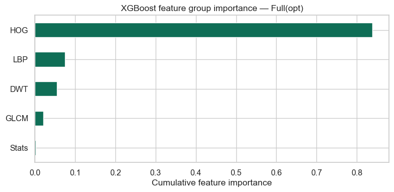

```
  Saved: output\feature_importance_xgboost_fullopt.png
```

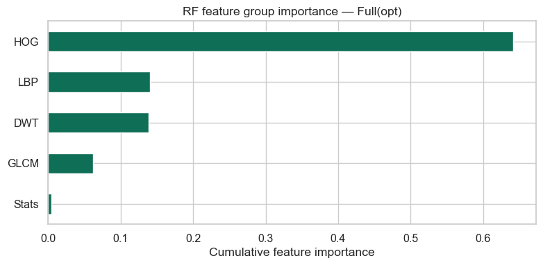

```
  Saved: output\feature_importance_rf_fullopt.png
```

```python
# ── Feature group importance (XGBoost + RF on Full(opt)) ───────────────────
init_phase2_viz_context()
TARGET_FS_FI = "Full(opt)"

if TARGET_FS_FI not in P2:
    print(f"Skip: {TARGET_FS_FI!r} not in P2 — run Phase 2 on Full(opt) first.")
else:
    # Raw block sizes before cleaning (for group-level aggregation)
    _RAW_BLOCKS = {"GLCM": 6, "LBP": 10, "DWT": 16, "HOG": 1944, "Stats": 11}
    _offsets, _names, _start = [], [], 0
    for name, dim in _RAW_BLOCKS.items():
        _offsets.append((_start, _start + dim, name))
        _start += dim
    kept = CLEAN_INFO.get(TARGET_FS_FI, {}).get("kept_indices", np.arange(_start))

    def _group_importance(est, title):
        imp = getattr(est, "feature_importances_", None)
        if imp is None:
            print(f"  {title}: no feature_importances_")
            return
        groups = {g: 0.0 for g in _RAW_BLOCKS}
        for j, w in enumerate(imp):
            if j >= len(kept):
                break
            orig = int(kept[j])
            for lo, hi, gname in _offsets:
                if lo <= orig < hi:
                    groups[gname] += float(w)
                    break
        s = pd.Series(groups).sort_values()
        ax = s.plot(kind="barh", color="#0F6E56", figsize=(8, 4))
        ax.set_xlabel("Cumulative feature importance")
        ax.set_title(title)
        plt.tight_layout()
        out = OUTPUT_DIR / f"feature_importance_{title.split()[0].lower()}_fullopt.png"
        plt.savefig(out, dpi=180, bbox_inches="tight")
        plt.show()
        print(f"  Saved: {out}")

    for _mn in ["XGBoost", "RF"]:
        if _mn in P2[TARGET_FS_FI]:
            _group_importance(
                P2[TARGET_FS_FI][_mn]["estimator"],
                f"{_mn} feature group importance — {TARGET_FS_FI}",
            )
        else:
            print(f"  Skip {_mn}: not trained on {TARGET_FS_FI}")
```

```python
# ── Soft voting ensemble (SVM + XGBoost + LightGBM on Full(opt)) ─────────────
TARGET_FS_VOTE = "Full(opt)"
_VOTE_MODELS = ["SVM", "XGBoost", "LightGBM"]

if TARGET_FS_VOTE not in CLEAN_OPT:
    raise KeyError(f"{TARGET_FS_VOTE!r} missing from CLEAN_OPT")
missing = [m for m in _VOTE_MODELS if m not in P2.get(TARGET_FS_VOTE, {})]
if missing:
    print(f"Voting ensemble skipped — train first: {missing}")
else:
    Xtr_v, Xte_v = CLEAN_OPT[TARGET_FS_VOTE]
    estimators = [
        (m.lower(), P2[TARGET_FS_VOTE][m]["estimator"]) for m in _VOTE_MODELS
    ]
    vote = VotingClassifier(estimators=estimators, voting="soft", n_jobs=-1)
    t0 = time.time()
    vote.fit(Xtr_v, y_train)
    fit_t = time.time() - t0
    yp = vote.predict(Xte_v)
    acc = accuracy_score(y_test, yp)
    f1m = f1_score(y_test, yp, average="macro", zero_division=0)
    print(f"Voting ({', '.join(_VOTE_MODELS)}) on {TARGET_FS_VOTE}:")
    print(f"  acc={acc:.4f}  f1_macro={f1m:.4f}  fit_time={fit_t:.1f}s")
    VOTING_RESULT = {"acc": acc, "f1_macro": f1m, "fit_time_s": fit_t, "y_pred": yp}
```

```
Voting (SVM, XGBoost, LightGBM) on Full(opt):
  acc=0.8933  f1_macro=0.8938  fit_time=13.9s
```

## 12. Per-Feature-Set Result Plots

```
Plotting: D — HOG
```

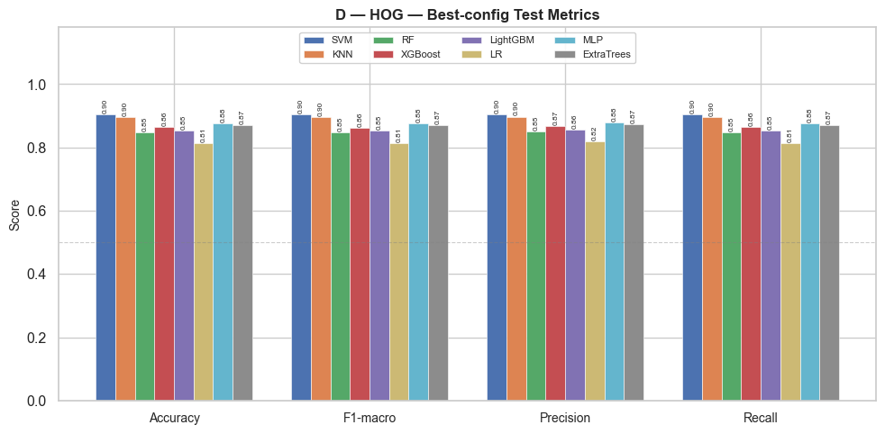

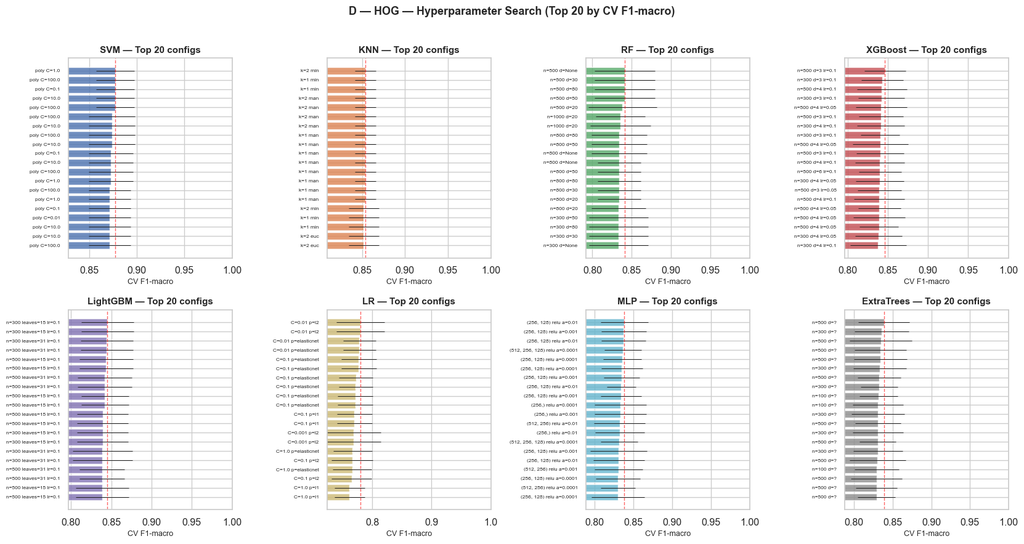

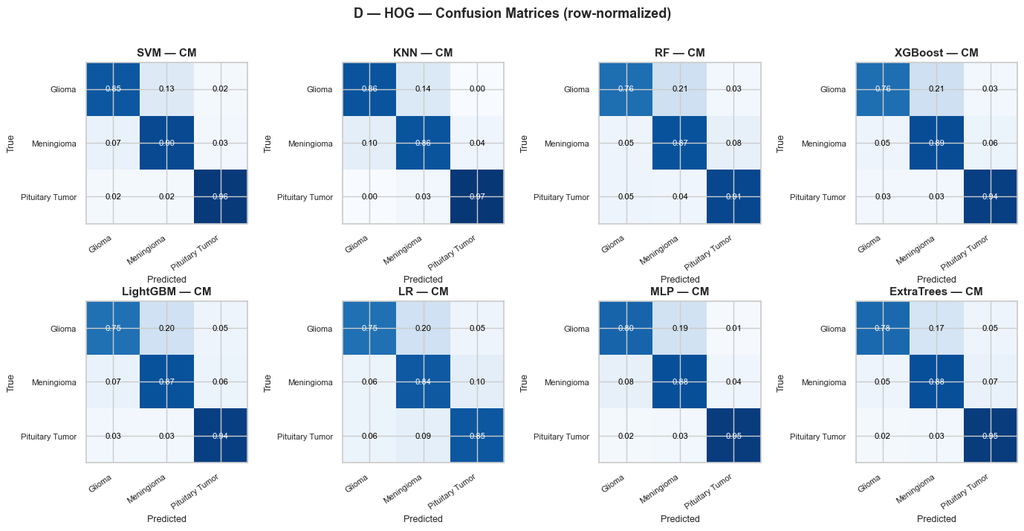

```
  Saved: p2_D_—_HOG_metrics.png, p2_D_—_HOG_cv_configs.png, p2_D_—_HOG_confmat.png

Plotting: A — Stats
```

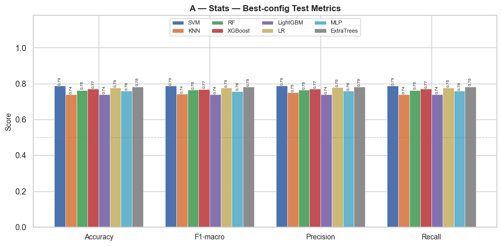

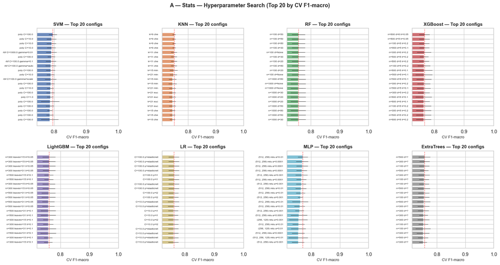

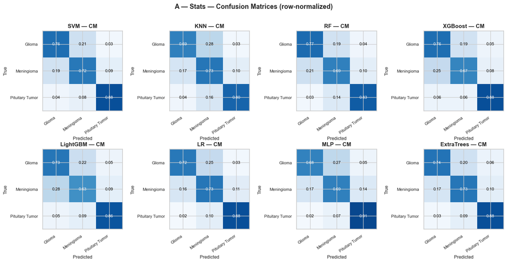

```
  Saved: p2_A_—_Stats_metrics.png, p2_A_—_Stats_cv_configs.png, p2_A_—_Stats_confmat.png

Plotting: Full(opt)
```

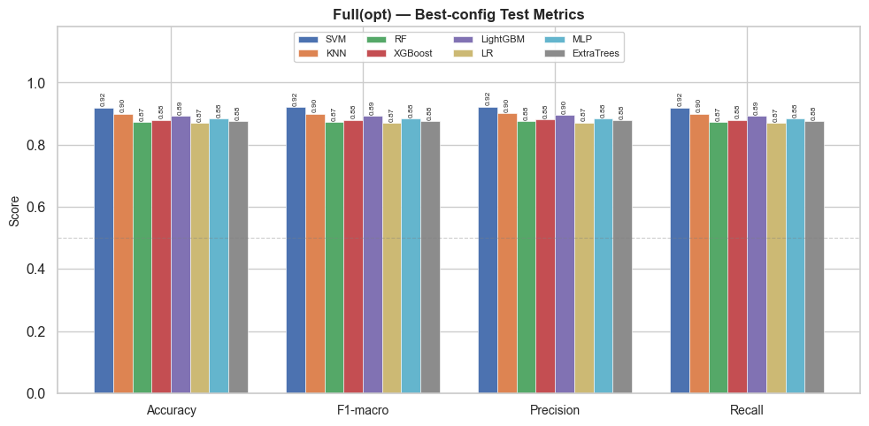

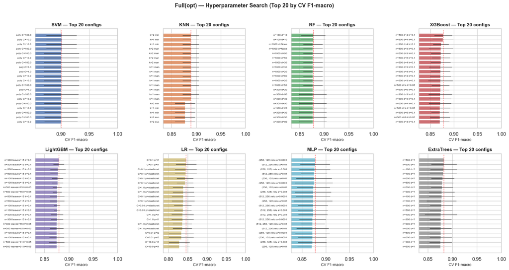

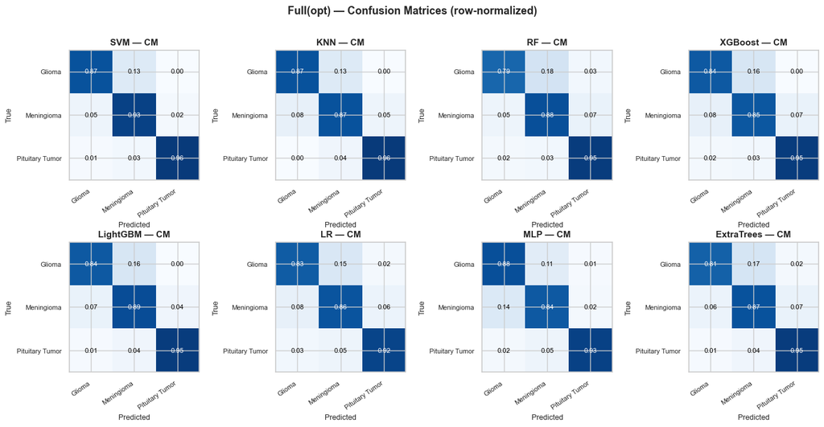

```
  Saved: p2_Full(opt)_metrics.png, p2_Full(opt)_cv_configs.png, p2_Full(opt)_confmat.png

Plotting: A+B
```

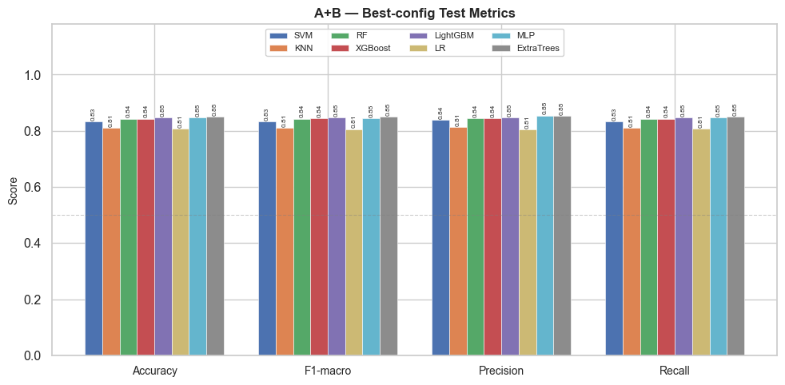

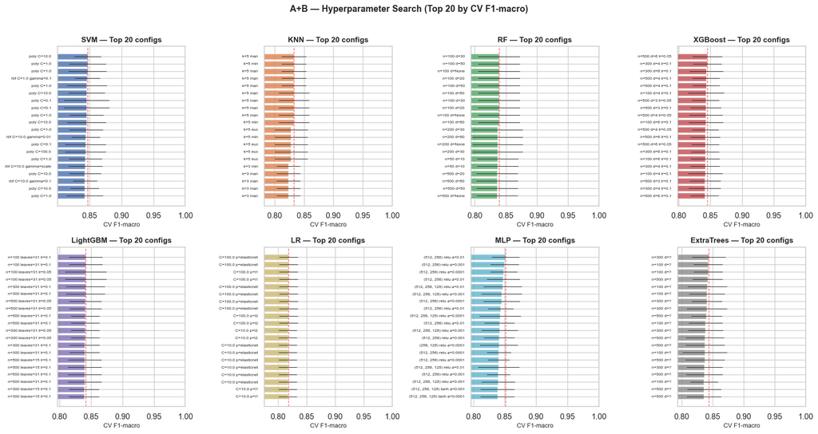

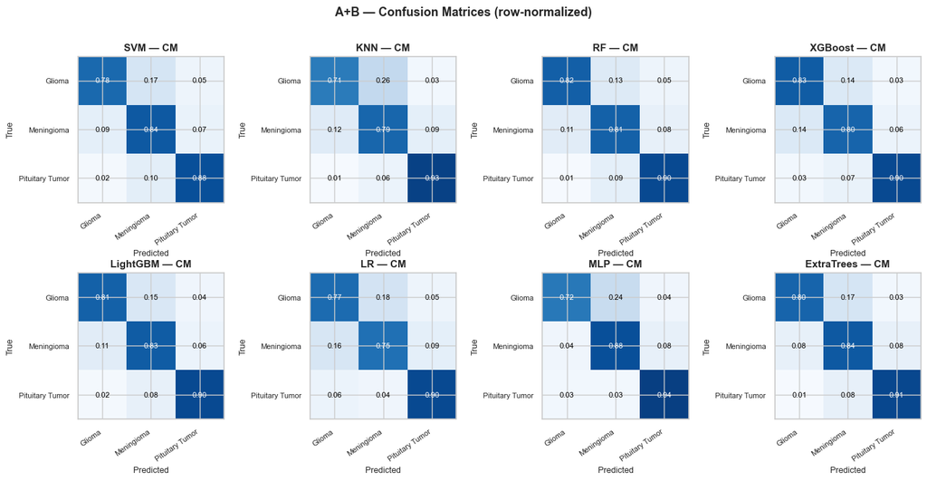

```
  Saved: p2_ApB_metrics.png, p2_ApB_cv_configs.png, p2_ApB_confmat.png

Plotting: B — Tex(opt)
```

[12 more figures not shown]

```
  Saved: p2_ApBpC(opt)_metrics.png, p2_ApBpC(opt)_cv_configs.png, p2_ApBpC(opt)_confmat.png
```

```python
def plot_fs(fs_name, res_dict):
    order = PHASE2_MODEL_ORDER if "PHASE2_MODEL_ORDER" in globals() else [
        "SVM", "KNN", "RF", "XGBoost", "LightGBM", "LR", "MLP", "ExtraTrees",
    ]
    mnames = [m for m in order if m in res_dict]
    if not mnames:
        print(f"  Skipping {fs_name}: no model results (run Phase 2 split cells for this set).")
        return
    missing = [m for m in order if m not in res_dict]
    n = len(mnames)
    safe = fs_name.replace(' ', '_').replace('+', 'p')

    # grid geometry: 4 panels per row, as many rows as needed
    ncol = min(4, n)
    nrow = int(np.ceil(n / ncol))

    # =====================================================================
    # FIGURE 1 — Best-config test metrics (grouped bar)
    # =====================================================================
    fig1, ax1 = plt.subplots(figsize=(10, 5))
    mk = ["acc", "f1m", "prec", "rec"]
    ml = ["Accuracy", "F1-macro", "Precision", "Recall"]
    x = np.arange(4)
    w = 0.8 / n
    for i, mn in enumerate(mnames):
        vals = [res_dict[mn][k] for k in mk]
        offset = (i - (n - 1) / 2) * w
        bars = ax1.bar(x + offset, vals, w, label=mn,
                       color=_model_color(mn), edgecolor="white", linewidth=0.4)
        ax1.bar_label(bars, fmt="%.2f", fontsize=6, padding=1, rotation=90)
    ax1.set_xticks(x); ax1.set_xticklabels(ml, fontsize=10)
    ax1.set_ylim(0, 1.18); ax1.set_ylabel("Score", fontsize=10)
    ax1.set_title(f"{fs_name} — Best-config Test Metrics", fontsize=12, fontweight="bold")
    ax1.legend(fontsize=8, ncol=4, loc="upper center", framealpha=0.9)
    ax1.axhline(0.5, color="gray", lw=0.8, ls="--", alpha=0.4)
    fig1.tight_layout()
    fig1.savefig(OUTPUT_DIR / f"p2_{safe}_metrics.png", dpi=300, bbox_inches="tight")
    plt.show()

    # =====================================================================
    # FIGURE 2 — Top-20 CV configs per model (2×4 grid)
    # =====================================================================
    fig2, axes2 = plt.subplots(nrow, ncol, figsize=(4.2 * ncol, 4.5 * nrow),
                               squeeze=False)
    for idx, mn in enumerate(mnames):
        ax = axes2[idx // ncol][idx % ncol]
        cv = (res_dict[mn]["cv_results"]
              .sort_values("mean_test_score", ascending=False)
              .head(20).copy())
        cv["label"] = cv.apply(lambda r: _hp_label(r, mn), axis=1)
        yp = np.arange(len(cv))
        ax.barh(yp, cv["mean_test_score"], xerr=cv["std_test_score"],
                color=_model_color(mn), alpha=0.8, error_kw={"elinewidth": 0.7})
        ax.set_yticks(yp); ax.set_yticklabels(cv["label"], fontsize=6)
        ax.invert_yaxis()                       # best config on top
        ax.set_xlabel("CV F1-macro", fontsize=9)
        ax.set_title(f"{mn} — Top 20 configs", fontsize=11, fontweight="bold")
        ax.set_xlim(cv["mean_test_score"].min() * 0.95, 1.0)  # zoom to data range
        ax.axvline(cv["mean_test_score"].max(), color="red", lw=1.0, ls="--", alpha=0.6)
    for j in range(n, nrow * ncol):             # hide unused cells
        axes2[j // ncol][j % ncol].axis("off")
    fig2.suptitle(f"{fs_name} — Hyperparameter Search (Top 20 by CV F1-macro)",
                  fontsize=13, fontweight="bold")
    fig2.tight_layout(rect=[0, 0, 1, 0.97])
    fig2.savefig(OUTPUT_DIR / f"p2_{safe}_cv_configs.png", dpi=300, bbox_inches="tight")
    plt.show()

    # =====================================================================
    # FIGURE 3 — Confusion matrices per model (2×4 grid)
    # =====================================================================
    fig3, axes3 = plt.subplots(nrow, ncol, figsize=(3.5 * ncol, 3.6 * nrow),
                               squeeze=False)
    for idx, mn in enumerate(mnames):
        ax = axes3[idx // ncol][idx % ncol]
        cm = confusion_matrix(y_test, res_dict[mn]["y_pred"], normalize="true")
        im = ax.imshow(cm, cmap="Blues", vmin=0, vmax=1)
        ax.set_xticks(range(n_classes)); ax.set_yticks(range(n_classes))
        ax.set_xticklabels(class_names, rotation=35, ha="right", fontsize=8)
        ax.set_yticklabels(class_names, fontsize=8)
        ax.set_xlabel("Predicted", fontsize=9); ax.set_ylabel("True", fontsize=9)
        ax.set_title(f"{mn} — CM", fontsize=11, fontweight="bold")
        for i in range(n_classes):
            for j in range(n_classes):
                ax.text(j, i, f"{cm[i, j]:.2f}", ha="center", va="center",
                        fontsize=8, color="white" if cm[i, j] > 0.6 else "black")
    for j in range(n, nrow * ncol):
        axes3[j // ncol][j % ncol].axis("off")
    fig3.suptitle(f"{fs_name} — Confusion Matrices (row-normalized)",
                  fontsize=13, fontweight="bold")
    fig3.tight_layout(rect=[0, 0, 1, 0.97])
    fig3.savefig(OUTPUT_DIR / f"p2_{safe}_confmat.png", dpi=300, bbox_inches="tight")
    plt.show()

    print(f"  Saved: p2_{safe}_metrics.png, p2_{safe}_cv_configs.png, p2_{safe}_confmat.png")
    if missing:
        print(f"  (missing models: {', '.join(missing)})")


for fs_name, res_dict in P2.items():
    print(f"\nPlotting: {fs_name}")
    if not res_dict:
        print("  (empty — no split-mode results)")
        continue
    plot_fs(fs_name, res_dict)
```

## 13. Overall Performance Dashboard

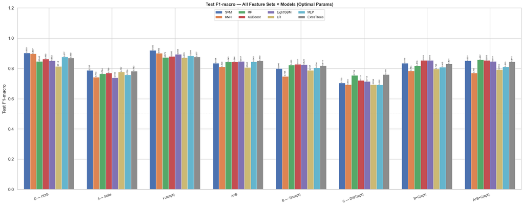

```
Saved: p2_f1_grouped_bar.png
```

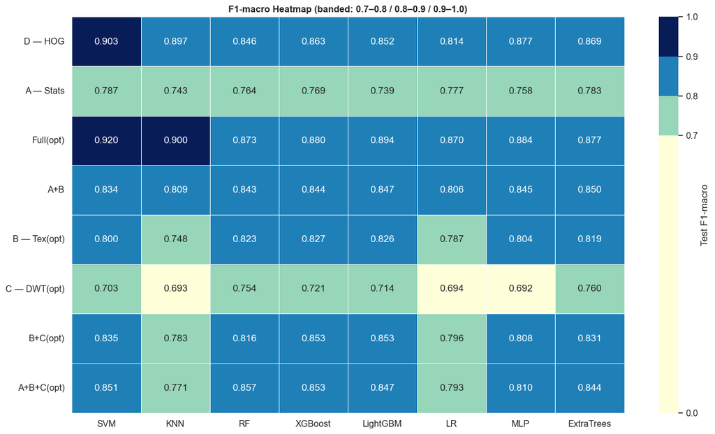

```
Saved: p2_f1_heatmap.png
```

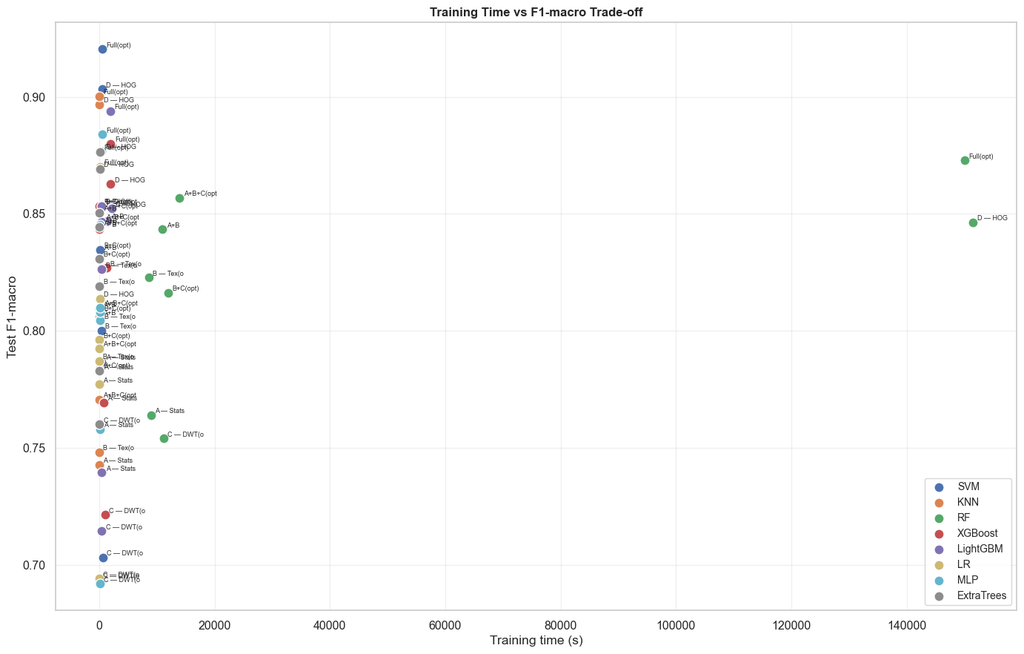

```
Saved: p2_time_vs_f1_scatter.png
```

```python
init_phase2_viz_context()

# ── Figure 1: Grouped bar — F1-macro ──────────────────────────────────────
fig1, ax1 = plt.subplots(figsize=(20, 8))
n_models = len(mnames)
group_w  = 0.8                     # total width occupied by one group of bars
w        = group_w / n_models      # width of a single bar
x        = np.arange(len(fs_list))
for i, mn in enumerate(mnames):
    vals = [P2[fs][mn]["f1m"] if mn in P2[fs] else np.nan for fs in fs_list]
    offset = (i - (n_models - 1) / 2) * w     # center the group on each x tick
    bars = ax1.bar(x + offset, vals, w, label=mn,
                   color=_model_color(mn), edgecolor="white", linewidth=0.4)
    ax1.bar_label(bars, fmt="%.3f", fontsize=6, padding=1, rotation=90)
ax1.set_xticks(x); ax1.set_xticklabels(fs_list, rotation=20, ha="right", fontsize=9)
ax1.set_ylim(0, 1.20); ax1.set_ylabel("Test F1-macro")
ax1.set_xlim(-0.5, len(fs_list) - 0.5)
ax1.set_title("Test F1-macro — All Feature Sets × Models (Optimal Params)", fontsize=12, fontweight="bold")
ax1.legend(fontsize=9, ncol=4, loc="upper center", bbox_to_anchor=(0.5, 1.0), framealpha=0.9)
ax1.axhline(0.5, color="gray", lw=0.8, ls="--", alpha=0.4)
plt.tight_layout()
plt.savefig(OUTPUT_DIR / "p2_f1_grouped_bar.png", dpi=120, bbox_inches="tight")
plt.show()
print("Saved: p2_f1_grouped_bar.png")

# ── Figure 2: Heatmap — F1-macro ──────────────────────────────────────────
from matplotlib.colors import BoundaryNorm

# ── Figure 2: Heatmap — F1-macro (banded colors) ──────────────────────────
fig2, ax2 = plt.subplots(figsize=(14, 8))
hdata = pd.DataFrame(
    {mn: [P2[fs][mn]["f1m"] if mn in P2[fs] else np.nan for fs in fs_list] for mn in mnames},
    index=fs_list)

# discrete bands: <0.7, 0.7–0.8, 0.8–0.9, 0.9–1.0
bounds = [0.0, 0.7, 0.8, 0.9, 1.0]
cmap   = plt.get_cmap("YlGnBu", len(bounds) - 1)   # one color per band
norm   = BoundaryNorm(bounds, cmap.N)

sns.heatmap(hdata, ax=ax2, annot=True, fmt=".3f", cmap=cmap, norm=norm,
            linewidths=0.5, linecolor="white",
            cbar_kws={"label": "Test F1-macro", "ticks": bounds, "spacing": "proportional"})
ax2.set_title("F1-macro Heatmap (banded: 0.7–0.8 / 0.8–0.9 / 0.9–1.0)",
              fontsize=12, fontweight="bold")
ax2.tick_params(axis="x", rotation=0); ax2.tick_params(axis="y", rotation=0)
plt.tight_layout()
plt.savefig(OUTPUT_DIR / "p2_f1_heatmap.png", dpi=120, bbox_inches="tight")
plt.show()
print("Saved: p2_f1_heatmap.png")

# ── Figure 3: Scatter — training time vs F1-macro ─────────────────────────
fig3, ax3 = plt.subplots(figsize=(14, 9))
for mn in mnames:
    times = [P2[fs][mn]["fit_t"] if mn in P2[fs] else np.nan for fs in fs_list]
    f1s   = [P2[fs][mn]["f1m"]   if mn in P2[fs] else np.nan for fs in fs_list]
    ax3.scatter(times, f1s, s=90, label=mn, color=_model_color(mn),
                edgecolors="white", zorder=3)
    for fi, fs in enumerate(fs_list):
        ax3.annotate(fs[:9], (times[fi], f1s[fi]),
                     textcoords="offset points", xytext=(4,2), fontsize=6.5)
ax3.set_xlabel("Training time (s)"); ax3.set_ylabel("Test F1-macro")
ax3.set_title("Training Time vs F1-macro Trade-off", fontsize=12, fontweight="bold")
ax3.legend(fontsize=10); ax3.grid(True, alpha=0.3)
plt.tight_layout()
plt.savefig(OUTPUT_DIR / "p2_time_vs_f1_scatter.png", dpi=120, bbox_inches="tight")
plt.show()
print("Saved: p2_time_vs_f1_scatter.png")
```

## 14. Leaderboard & Final Summary

```
LEADERBOARD
```

|  | Feature Set | Model | Accuracy | F1-macro | Precision | Recall | Fit Time (s) | Composite |
| --- | --- | --- | --- | --- | --- | --- | --- | --- |
| 1 | Full(opt) | SVM | 0.9200 | 0.9204 | 0.9228 | 0.9200 | 544.5223 | 0.9203 |
| 2 | D — HOG | SVM | 0.9033 | 0.9032 | 0.9040 | 0.9033 | 495.9264 | 0.9032 |
| 3 | Full(opt) | KNN | 0.9000 | 0.9002 | 0.9009 | 0.9000 | 35.4320 | 0.9002 |
| 4 | D — HOG | KNN | 0.8967 | 0.8967 | 0.8971 | 0.8967 | 32.5583 | 0.8967 |
| 5 | Full(opt) | LightGBM | 0.8933 | 0.8938 | 0.8964 | 0.8933 | 1919.7117 | 0.8932 |
| ... | ... | ... | ... | ... | ... | ... | ... | ... |
| 60 | C — DWT(opt) | LightGBM | 0.7167 | 0.7144 | 0.7145 | 0.7167 | 451.1103 | 0.7152 |
| 61 | C — DWT(opt) | SVM | 0.7033 | 0.7031 | 0.7048 | 0.7033 | 599.1458 | 0.7031 |
| 62 | C — DWT(opt) | KNN | 0.7000 | 0.6932 | 0.7071 | 0.7000 | 1.6488 | 0.6973 |
| 63 | C — DWT(opt) | LR | 0.6967 | 0.6940 | 0.6970 | 0.6967 | 0.9073 | 0.6954 |
| 64 | C — DWT(opt) | MLP | 0.6967 | 0.6919 | 0.6961 | 0.6967 | 135.2032 | 0.6942 |

64 rows × 8 columns

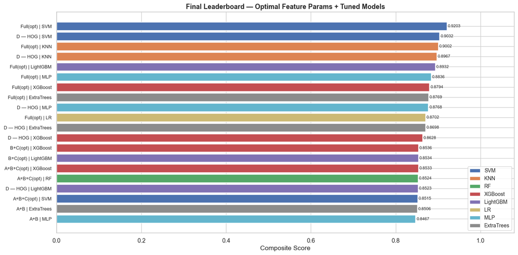

```
Saved: phase2_benchmark_results.csv, leaderbordML.json, p2_leaderboard.png
```

```python
init_phase2_viz_context()
rows = []
for fs in fs_list:
    for mn in mnames:
        if mn not in P2.get(fs, {}):
            continue
        r = P2[fs][mn]
        rows.append({"Feature Set":fs, "Model":mn,
                     "Accuracy":r["acc"], "F1-macro":r["f1m"],
                     "F1-weighted":r["f1w"], "Precision":r["prec"],
                     "Recall":r["rec"], "Fit Time (s)":r["fit_t"],
                     "Best Params":str(r["best_params"])})
leader = pd.DataFrame(rows)
mms2 = MinMaxScaler()
leader["time_n"] = mms2.fit_transform(leader[["Fit Time (s)"]])
leader["Composite"] = (0.50*leader["F1-macro"] + 0.30*leader["Accuracy"]
                       + 0.10*leader["Precision"] + 0.10*leader["Recall"]
                       - 0.05*leader["time_n"]).round(4)
leader = leader.sort_values("Composite", ascending=False).reset_index(drop=True)
leader.index += 1
print("LEADERBOARD")
display(leader[["Feature Set","Model","Accuracy","F1-macro",
                "Precision","Recall","Fit Time (s)","Composite"]].round(4))
leader.to_csv("phase2_benchmark_results.csv", index=False)

# ── Save leaderboard to JSON ──────────────────────────────────────────────
leader.to_json(OUTPUT_DIR / "leaderbordML.json", orient="records", indent=2)

# ── Leaderboard bar chart ─────────────────────────────────────────────────
fig, ax = plt.subplots(figsize=(14, 7))
top = leader.head(min(20, len(leader)))
bar_cols = [_model_color(m) for m in top["Model"]]
bars = ax.barh(range(len(top))[::-1], top["Composite"],
               color=bar_cols, edgecolor="white")
ax.set_yticks(range(len(top))[::-1])
ax.set_yticklabels([f"{r['Feature Set']} | {r['Model']}"
                    for _, r in top.iterrows()], fontsize=9)
ax.set_xlabel("Composite Score")
ax.set_title("Final Leaderboard — Optimal Feature Params + Tuned Models",
             fontsize=13, fontweight="bold")
from matplotlib.patches import Patch
ax.legend(handles=[Patch(facecolor=_model_color(m),label=m) for m in mnames],
          fontsize=10, loc="lower right")
ax.bar_label(bars, fmt="%.4f", fontsize=8, padding=2)
ax.set_xlim(0, 1.08)
plt.tight_layout()
plt.savefig(OUTPUT_DIR / "p2_leaderboard.png", dpi=120, bbox_inches="tight")
plt.show()
print("\nSaved: phase2_benchmark_results.csv, leaderbordML.json, p2_leaderboard.png")
```

```python
# ── Final print summary ────────────────────────────────────────────────────
if "leader" not in globals() or leader.empty:
    raise ValueError("Run the leaderboard cell above first.")

print("=" * 65)
print("FINAL SUMMARY")
print("=" * 65)

best = leader.iloc[0]
print(f"\n🏆  Best overall:")
print(f"     Feature Set : {best['Feature Set']}")
print(f"     Model       : {best['Model']}")
print(f"     Accuracy    : {best['Accuracy']:.4f}")
print(f"     F1-macro    : {best['F1-macro']:.4f}")
print(f"     Composite   : {best['Composite']:.4f}")

print(f"\n📊  Best per model:")
for mn in leader["Model"].unique():
    sub = leader[leader["Model"]==mn].iloc[0]
    print(f"     {mn:4s}  Feature Set: {sub['Feature Set']:20s}  "
          f"F1={sub['F1-macro']:.4f}")

print(f"\n📦  Best per feature set:")
for fs in fs_list:
    sub = leader[leader["Feature Set"]==fs].iloc[0]
    print(f"     {fs:18s}  {sub['Model']:4s}  F1={sub['F1-macro']:.4f}")

print(f"\n⚙️   Optimal feature parameters used:")
print(f"     GLCM: dist={BEST_GLCM_DIST}  ang={len(BEST_GLCM_ANG)} angles  "
      f"lvl={BEST_GLCM_LVL}  sym={BEST_GLCM_SYM}")
print(f"     LBP : P={BEST_LBP_P}  R={BEST_LBP_R}  method={BEST_LBP_METHOD}")
print(f"     DWT : wavelet={BEST_DWT_WAV}  level={BEST_DWT_LEVEL}")

print(f"\n📁  Output files:")
for f in [
          "phase2_benchmark_results.csv",
          "phase2_all_modes_metrics.csv",
          "seed_stability_3seeds.csv",
          "output/class_balance_train.png",
          "output/rf_branch_importance.png",
          "output/tsne_best_feature_set.png",
          "output/glcm_param_search.png", "output/glcm_top15.png",
          "output/lbp_param_search.png", "output/lbp_by_method.png",
          "output/dwt_param_search.png", "output/dwt_wavelet_comparison.png",
          "output/phase1_summary.png",
          "output/p2_overall_dashboard.png", "output/p2_leaderboard.png"]:
    print(f"     {f}")
```

```
=================================================================
FINAL SUMMARY
=================================================================

🏆  Best overall:
     Feature Set : Full(opt)
     Model       : SVM
     Accuracy    : 0.9200
     F1-macro    : 0.9204
     Composite   : 0.9203

📊  Best per model:
     SVM   Feature Set: Full(opt)             F1=0.9204
     KNN   Feature Set: Full(opt)             F1=0.9002
     LightGBM  Feature Set: Full(opt)             F1=0.8938
     MLP   Feature Set: Full(opt)             F1=0.8839
     XGBoost  Feature Set: Full(opt)             F1=0.8800
     ExtraTrees  Feature Set: Full(opt)             F1=0.8765
     LR    Feature Set: Full(opt)             F1=0.8702
     RF    Feature Set: A+B+C(opt)            F1=0.8569

📦  Best per feature set:
     D — HOG             SVM   F1=0.9032
     A — Stats           SVM   F1=0.7867
     Full(opt)           SVM   F1=0.9204
     A+B                 ExtraTrees  F1=0.8505
     B — Tex(opt)        XGBoost  F1=0.8268
     C — DWT(opt)        ExtraTrees  F1=0.7600
     B+C(opt)            XGBoost  F1=0.8534
     A+B+C(opt)          XGBoost  F1=0.8533

⚙️   Optimal feature parameters used:
     GLCM: dist=[1, 2, 4, 8]  ang=1 angles  lvl=128  sym=False
     LBP : P=12  R=1  method=uniform
     DWT : wavelet=db2  level=1

📁  Output files:
     phase2_benchmark_results.csv
     phase2_all_modes_metrics.csv
     seed_stability_3seeds.csv
     output/class_balance_train.png
     output/rf_branch_importance.png
     output/tsne_best_feature_set.png
     output/glcm_param_search.png
     output/glcm_top15.png
     output/lbp_param_search.png
     output/lbp_by_method.png
     output/dwt_param_search.png
     output/dwt_wavelet_comparison.png
     output/phase1_summary.png
     output/p2_overall_dashboard.png
     output/p2_leaderboard.png
```

## 15. Diagnostics: Imbalance, RF Importances, t-SNE, Seed Stability

```python
from collections import Counter
from sklearn.manifold import TSNE
```

### Class imbalance check

```
Train class balance: Counter({np.int32(0): 400, np.int32(2): 400, np.int32(1): 400})
Imbalance ratio: 1.000
```

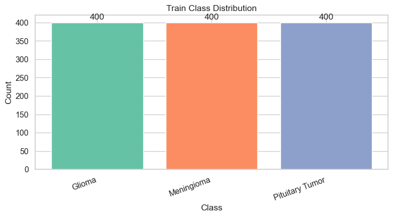

```
Class balance looks reasonably even. SMOTE likely optional.
```

```python
train_counter = Counter(y_train)
imbalance_ratio = max(train_counter.values()) / max(1, min(train_counter.values()))

print("Train class balance:", train_counter)
print(f"Imbalance ratio: {imbalance_ratio:.3f}")

fig, ax = plt.subplots(figsize=(8, 4.5))
cls_idx = list(range(len(class_names)))
cls_counts = [train_counter.get(i, 0) for i in cls_idx]
bars = ax.bar(class_names, cls_counts, color=sns.color_palette("Set2", len(class_names)))
ax.set_title("Train Class Distribution")
ax.set_ylabel("Count")
ax.set_xlabel("Class")
ax.bar_label(bars, padding=2)
plt.xticks(rotation=20, ha="right")
plt.tight_layout()
plt.savefig(OUTPUT_DIR / "class_balance_train.png", dpi=120, bbox_inches="tight")
plt.show()

if imbalance_ratio >= 1.5:
    print("Note: noticeable imbalance detected. Consider trying class_weight and/or SMOTE in a controlled experiment.")
else:
    print("Class balance looks reasonably even. SMOTE likely optional.")
```

### RF branch importance visualisation (A / GLCM / LBP / DWT / HOG)

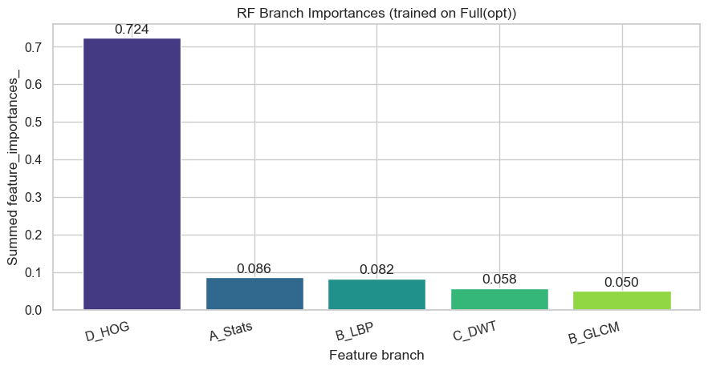

|  | branch | importance |
| --- | --- | --- |
| 4 | D_HOG | 0.723984 |
| 0 | A_Stats | 0.086214 |
| 2 | B_LBP | 0.082305 |
| 3 | C_DWT | 0.057602 |
| 1 | B_GLCM | 0.049895 |

```python
rf_full = RandomForestClassifier(
    random_state=SEED,
    n_jobs=-1,
    **P2["Full(opt)"]["RF"]["best_params"]
)
rf_full.fit(FULL_tr, y_train)

importances = rf_full.feature_importances_
a = A_tr.shape[1]
bg = B_glcm_tr.shape[1]
bl = B_lbp_tr.shape[1]
c = C_tr.shape[1]
d = D_tr.shape[1]

branch_importance = {
    "A_Stats": float(importances[:a].sum()),
    "B_GLCM": float(importances[a:a+bg].sum()),
    "B_LBP": float(importances[a+bg:a+bg+bl].sum()),
    "C_DWT": float(importances[a+bg+bl:a+bg+bl+c].sum()),
    "D_HOG": float(importances[a+bg+bl+c:a+bg+bl+c+d].sum()),
}
branch_imp_df = pd.DataFrame(
    {"branch": list(branch_importance.keys()), "importance": list(branch_importance.values())}
).sort_values("importance", ascending=False)

fig, ax = plt.subplots(figsize=(9, 4.8))
bars = ax.bar(branch_imp_df["branch"], branch_imp_df["importance"], color=sns.color_palette("viridis", len(branch_imp_df)))
ax.set_title("RF Branch Importances (trained on Full(opt))")
ax.set_ylabel("Summed feature_importances_")
ax.set_xlabel("Feature branch")
ax.bar_label(bars, fmt="%.3f", padding=2)
plt.xticks(rotation=15, ha="right")
plt.tight_layout()
plt.savefig(OUTPUT_DIR / "rf_branch_importance.png", dpi=120, bbox_inches="tight")
plt.show()

display(branch_imp_df)
```

### t-SNE on best feature set

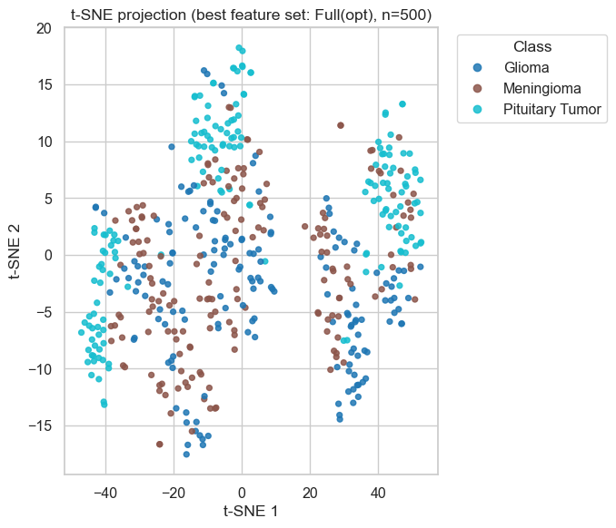

```python
best_fs_tsne = leader.iloc[0]["Feature Set"]
X_best_train = CLEAN_OPT[best_fs_tsne][0]

n_tsne = min(500, X_best_train.shape[0])
rng = np.random.default_rng(SEED)
idx_tsne = rng.choice(X_best_train.shape[0], size=n_tsne, replace=False)
X_tsne = X_best_train[idx_tsne]
y_tsne = y_train[idx_tsne]

Xr = TSNE(n_components=2, random_state=SEED, init="pca", learning_rate="auto").fit_transform(X_tsne)

fig, ax = plt.subplots(figsize=(7, 6))
sc = ax.scatter(Xr[:, 0], Xr[:, 1], c=y_tsne, cmap="tab10", s=18, alpha=0.85)
ax.set_title(f"t-SNE projection (best feature set: {best_fs_tsne}, n={n_tsne})")
ax.set_xlabel("t-SNE 1")
ax.set_ylabel("t-SNE 2")
handles, _ = sc.legend_elements()
ax.legend(handles, class_names, title="Class", bbox_to_anchor=(1.03, 1), loc="upper left")
plt.tight_layout()
plt.savefig(OUTPUT_DIR / "tsne_best_feature_set.png", dpi=120, bbox_inches="tight")
plt.show()
```

### Seed stability check (3 seeds)

```python
best_fs = leader.iloc[0]["Feature Set"]
best_model = leader.iloc[0]["Model"]

X_raw = np.vstack([OPT_SETS[best_fs][0], OPT_SETS[best_fs][1]])
y_all_diag = np.concatenate([y_train, y_test])

seed_results = []
for sd in [SEED, SEED + 1, SEED + 2]:
    Xtr_s, Xte_s, ytr_s, yte_s = train_test_split(
        X_raw, y_all_diag, test_size=TEST_SIZE, stratify=y_all_diag, random_state=sd
    )
    Xtr_s, Xte_s, _ = clean_scale(Xtr_s.astype(np.float32), Xte_s.astype(np.float32))

    cv_s = StratifiedKFold(n_splits=3, shuffle=True, random_state=sd)
    est_s = clone(ESTIMATORS[best_model])

    gs_s = GridSearchCV(
        est_s,
        MODEL_GRIDS[best_model],
        scoring="f1_macro",
        cv=cv_s,
        n_jobs=-1,
        refit=True,
        return_train_score=False,
    )
    gs_s.fit(Xtr_s, ytr_s)
    yp_s = gs_s.best_estimator_.predict(Xte_s)

    seed_results.append({
        "seed": sd,
        "acc": accuracy_score(yte_s, yp_s),
        "f1_macro": f1_score(yte_s, yp_s, average="macro", zero_division=0),
        "best_params": str(gs_s.best_params_),
    })

seed_df = pd.DataFrame(seed_results)
mu = seed_df["f1_macro"].mean()
sig = seed_df["f1_macro"].std(ddof=1) if len(seed_df) > 1 else 0.0
ci95 = 1.96 * sig / np.sqrt(len(seed_df)) if len(seed_df) > 1 else 0.0

print(f"\nSeed stability for best pair ({best_fs}, {best_model}):")
print(seed_df.to_string(index=False))
print(f"F1-macro mean ± 95% CI: {mu:.4f} ± {ci95:.4f}")

seed_df.to_csv("seed_stability_3seeds.csv", index=False)
print("Saved: class_balance_train.png, rf_branch_importance.png, tsne_best_feature_set.png, seed_stability_3seeds.csv")
```

```
Seed stability for best pair (Full(opt), SVM):
 seed      acc  f1_macro                                                            best_params
   42 0.950000  0.949755 {'C': 10, 'coef0': 1.0, 'degree': 4, 'gamma': 0.001, 'kernel': 'poly'}
   43 0.910000  0.909906 {'C': 10, 'coef0': 0.5, 'degree': 3, 'gamma': 0.001, 'kernel': 'poly'}
   44 0.913333  0.913021   {'C': 1, 'coef0': 1.0, 'degree': 2, 'gamma': 0.01, 'kernel': 'poly'}
F1-macro mean ± 95% CI: 0.9242 ± 0.0251
Saved: class_balance_train.png, rf_branch_importance.png, tsne_best_feature_set.png, seed_stability_3seeds.csv
```

## Inference test on a random test image

```
Selected test index: 26
True label: Pituitary Tumor
```

|  | feature_set | model | pred_name | confidence | correct | status |
| --- | --- | --- | --- | --- | --- | --- |
| 1 | D — HOG | KNN | Pituitary Tumor | 1.000000 | True | OK |
| 9 | A — Stats | KNN | Pituitary Tumor | 1.000000 | True | OK |
| 17 | Full(opt) | KNN | Pituitary Tumor | 1.000000 | True | OK |
| 25 | A+B | KNN | Pituitary Tumor | 1.000000 | True | OK |
| 49 | B+C(opt) | KNN | Pituitary Tumor | 1.000000 | True | OK |
| ... | ... | ... | ... | ... | ... | ... |
| 45 | C — DWT(opt) | LR | Glioma | 0.584090 | False | OK |
| 42 | C — DWT(opt) | RF | Glioma | 0.551833 | False | OK |
| 40 | C — DWT(opt) | SVM | Meningioma | 0.491662 | False | OK |
| 47 | C — DWT(opt) | ExtraTrees | Glioma | 0.470000 | False | OK |
| 46 | C — DWT(opt) | MLP | Meningioma | 0.383524 | False | OK |

64 rows × 6 columns

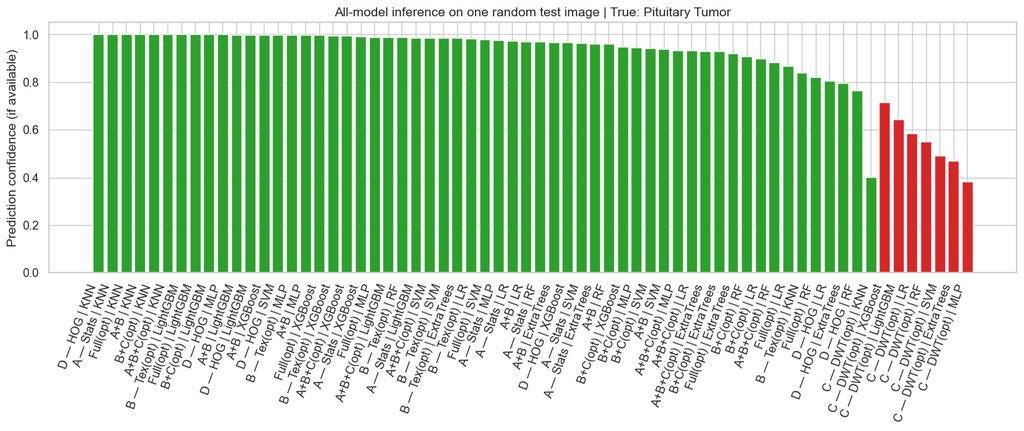

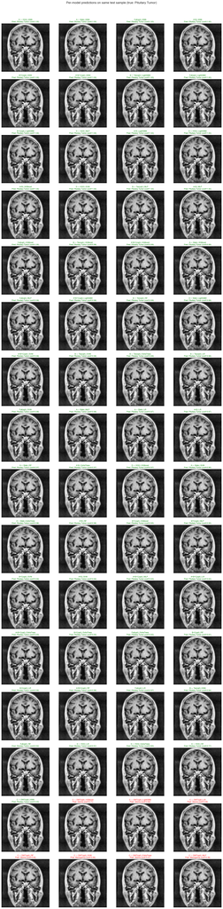

```python
# ── Inference test on all models (same random test image) ──────────────────
# Uses all (feature_set, model) pairs from P2 and compares predictions.

import math, hashlib, joblib
import numpy as np
import pandas as pd
import matplotlib.pyplot as plt

# 1) Pick one random test sample
rng = np.random.default_rng(42)
idx = int(rng.integers(0, len(y_test)))
img = X_test_raw[idx]
y_true = int(y_test[idx])
true_name = class_names[y_true]

rows = []

def _load_estimator_if_needed(fs_name, model_name, est):
    if est is not None:
        return est
    models_dir = PHASE_CACHE_DIR / "saved_models"
    tag = f"split|{fs_name}|{model_name}|seed={SEED}|cv={CV_FOLDS}"
    h = hashlib.md5(tag.encode("utf-8")).hexdigest()[:12]
    model_path = models_dir / f"{h}.joblib"
    if model_path.exists():
        return joblib.load(model_path)
    return None

# 2) Predict with every model from P2
for fs_name, model_dict in P2.items():
    Xte_best = CLEAN_OPT[fs_name][1]
    x_input = Xte_best[idx:idx+1]

    for model_name, result in model_dict.items():
        est = _load_estimator_if_needed(fs_name, model_name, result.get("estimator", None))
        if est is None:
            rows.append({
                "feature_set": fs_name,
                "model": model_name,
                "pred_name": "N/A",
                "confidence": np.nan,
                "correct": False,
                "status": "MISSING_ESTIMATOR"
            })
            continue

        y_pred = int(est.predict(x_input)[0])
        pred_name = class_names[y_pred]
        correct = (y_pred == y_true)

        if hasattr(est, "predict_proba"):
            proba = est.predict_proba(x_input)[0]
            conf = float(proba[y_pred])
        else:
            conf = np.nan

        rows.append({
            "feature_set": fs_name,
            "model": model_name,
            "pred_name": pred_name,
            "confidence": conf,
            "correct": correct,
            "status": "OK"
        })

inf_df = pd.DataFrame(rows)
inf_df["pair"] = inf_df["feature_set"] + " | " + inf_df["model"]

print("Selected test index:", idx)
print("True label:", true_name)
display(
    inf_df.sort_values(["correct", "confidence"], ascending=[False, False])
          [["feature_set","model","pred_name","confidence","correct","status"]]
)

# 3) Plot A: confidence per model pair (colored by correctness)
plot_df = inf_df[inf_df["status"] == "OK"].copy()
plot_df["confidence_plot"] = plot_df["confidence"].fillna(0.0)
plot_df = plot_df.sort_values(["correct", "confidence_plot"], ascending=[False, False])

colors = np.where(plot_df["correct"], "#2ca02c", "#d62728")
plt.figure(figsize=(14, 6))
plt.bar(range(len(plot_df)), plot_df["confidence_plot"], color=colors)
plt.xticks(range(len(plot_df)), plot_df["pair"], rotation=70, ha="right")
plt.ylim(0, 1.05)
plt.ylabel("Prediction confidence (if available)")
plt.title(f"All-model inference on one random test image | True: {true_name}")
plt.tight_layout()
plt.show()

# 4) Plot B: one tile per model pair (same image, different predictions)
n = len(plot_df)
ncols = 4
nrows = math.ceil(n / ncols)
fig, axes = plt.subplots(nrows, ncols, figsize=(4*ncols, 3.8*nrows))
axes = np.array(axes).reshape(-1)

for i, (_, r) in enumerate(plot_df.iterrows()):
    ax = axes[i]
    ax.imshow(img, cmap="gray")
    ax.axis("off")
    conf_txt = f"{r['confidence']:.2f}" if np.isfinite(r["confidence"]) else "NA"
    color = "green" if r["correct"] else "red"
    ax.set_title(f"{r['feature_set']} | {r['model']}\nPred: {r['pred_name']} (conf={conf_txt})",
                 fontsize=9, color=color)

for j in range(i+1, len(axes)):
    axes[j].axis("off")

fig.suptitle(f"Per-model predictions on same test sample (true: {true_name})", y=1.01)
plt.tight_layout()
plt.show()
```

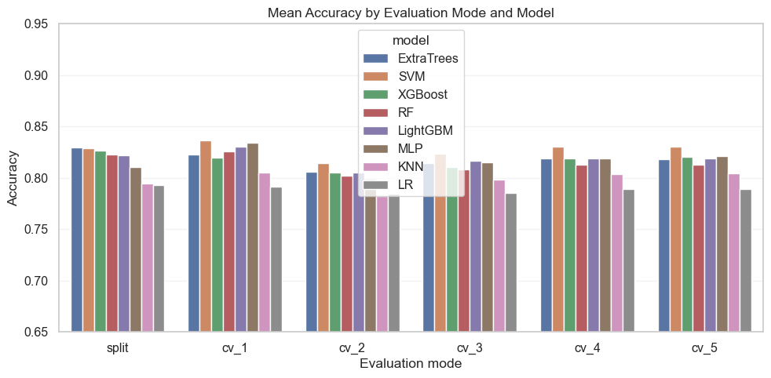

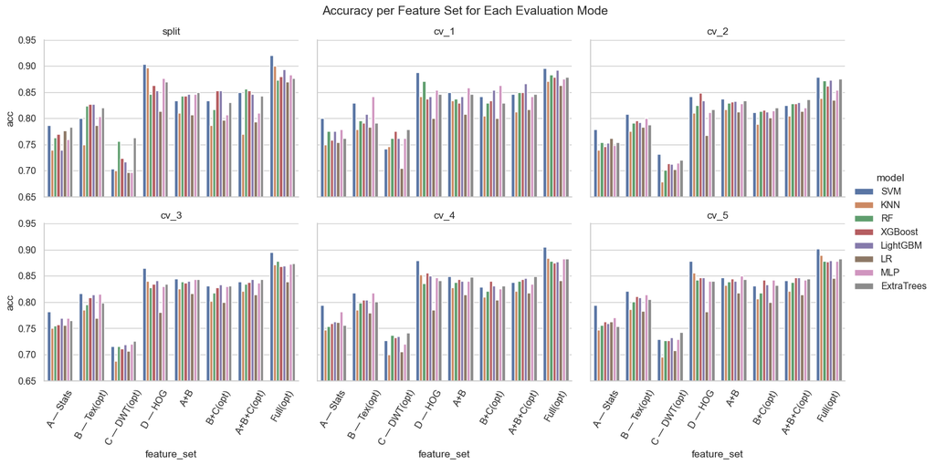

```python
# ── Accuracy plots by eval_mode ─────────────────────────────────────────────
import pandas as pd
import seaborn as sns
import matplotlib.pyplot as plt

df = pd.read_csv("phase2_all_modes_metrics.csv")

# Keep consistent order
mode_order = ["split", "cv_1", "cv_2", "cv_3", "cv_4", "cv_5"]
df = df[df["eval_mode"].isin(mode_order)].copy()
df["eval_mode"] = pd.Categorical(df["eval_mode"], categories=mode_order, ordered=True)

# Plot 1: Mean accuracy per mode and model
agg = (df.groupby(["eval_mode", "model"], as_index=False)["acc"]
         .mean()
         .sort_values(["eval_mode", "acc"], ascending=[True, False]))

plt.figure(figsize=(10, 5))
sns.barplot(data=agg, x="eval_mode", y="acc", hue="model")
plt.title("Mean Accuracy by Evaluation Mode and Model")
plt.ylabel("Accuracy")
plt.xlabel("Evaluation mode")
plt.ylim(0.65, 0.95)
plt.grid(axis="y", alpha=0.25)
plt.tight_layout()
plt.show()

# Plot 2: One panel per mode, accuracy across feature sets
g = sns.catplot(
    data=df,
    kind="bar",
    x="feature_set",
    y="acc",
    hue="model",
    col="eval_mode",
    col_wrap=3,
    sharey=True,
    height=3.6,
    aspect=1.35
)
g.set_titles("{col_name}")
for ax in g.axes.flatten():
    ax.tick_params(axis="x", rotation=60)
    ax.set_ylim(0.65, 0.95)
g.fig.subplots_adjust(top=0.90)
g.fig.suptitle("Accuracy per Feature Set for Each Evaluation Mode")
plt.show()
```

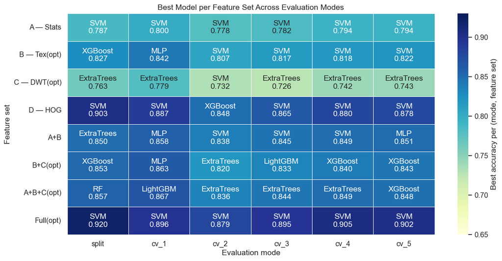

|  | eval_mode | feature_set | model | acc |
| --- | --- | --- | --- | --- |
| 56 | split | Full(opt) | SVM | 0.920000 |
| 24 | split | D — HOG | SVM | 0.903333 |
| 50 | split | A+B+C(opt) | RF | 0.856667 |
| 43 | split | B+C(opt) | XGBoost | 0.853333 |
| 39 | split | A+B | ExtraTrees | 0.850000 |
| 11 | split | B — Tex(opt) | XGBoost | 0.826667 |
| 0 | split | A — Stats | SVM | 0.786667 |
| 23 | split | C — DWT(opt) | ExtraTrees | 0.763333 |
| 120 | cv_1 | Full(opt) | SVM | 0.895833 |
| 88 | cv_1 | D — HOG | SVM | 0.887500 |
| 116 | cv_1 | A+B+C(opt) | LightGBM | 0.866667 |
| 110 | cv_1 | B+C(opt) | MLP | 0.862500 |
| 102 | cv_1 | A+B | MLP | 0.858333 |
| 78 | cv_1 | B — Tex(opt) | MLP | 0.841667 |
| 64 | cv_1 | A — Stats | SVM | 0.800000 |
| 87 | cv_1 | C — DWT(opt) | ExtraTrees | 0.779167 |
| 184 | cv_2 | Full(opt) | SVM | 0.879167 |
| 155 | cv_2 | D — HOG | XGBoost | 0.848333 |
| 160 | cv_2 | A+B | SVM | 0.837500 |
| 183 | cv_2 | A+B+C(opt) | ExtraTrees | 0.835833 |
| 175 | cv_2 | B+C(opt) | ExtraTrees | 0.820000 |
| 136 | cv_2 | B — Tex(opt) | SVM | 0.807500 |
| 128 | cv_2 | A — Stats | SVM | 0.778333 |
| 144 | cv_2 | C — DWT(opt) | SVM | 0.731667 |
| 248 | cv_3 | Full(opt) | SVM | 0.895000 |
| 216 | cv_3 | D — HOG | SVM | 0.865000 |
| 224 | cv_3 | A+B | SVM | 0.845000 |
| 247 | cv_3 | A+B+C(opt) | ExtraTrees | 0.844167 |
| 236 | cv_3 | B+C(opt) | LightGBM | 0.833333 |
| 200 | cv_3 | B — Tex(opt) | SVM | 0.816667 |
| 192 | cv_3 | A — Stats | SVM | 0.782500 |
| 215 | cv_3 | C — DWT(opt) | ExtraTrees | 0.725833 |
| 312 | cv_4 | Full(opt) | SVM | 0.905000 |
| 280 | cv_4 | D — HOG | SVM | 0.880000 |
| 288 | cv_4 | A+B | SVM | 0.849167 |
| 311 | cv_4 | A+B+C(opt) | ExtraTrees | 0.849167 |
| 299 | cv_4 | B+C(opt) | XGBoost | 0.840000 |
| 264 | cv_4 | B — Tex(opt) | SVM | 0.817500 |
| 256 | cv_4 | A — Stats | SVM | 0.794167 |
| 279 | cv_4 | C — DWT(opt) | ExtraTrees | 0.741667 |
| 376 | cv_5 | Full(opt) | SVM | 0.901667 |
| 344 | cv_5 | D — HOG | SVM | 0.878333 |
| 358 | cv_5 | A+B | MLP | 0.850833 |
| 371 | cv_5 | A+B+C(opt) | XGBoost | 0.847500 |
| 363 | cv_5 | B+C(opt) | XGBoost | 0.842500 |
| 328 | cv_5 | B — Tex(opt) | SVM | 0.821667 |
| 320 | cv_5 | A — Stats | SVM | 0.794167 |
| 343 | cv_5 | C — DWT(opt) | ExtraTrees | 0.742500 |

```python
# ── Best model per feature set per mode (heatmap + labels) ─────────────────
import pandas as pd
import seaborn as sns
import matplotlib.pyplot as plt

df = pd.read_csv("phase2_all_modes_metrics.csv")

mode_order = ["split", "cv_1", "cv_2", "cv_3", "cv_4", "cv_5"]
df = df[df["eval_mode"].isin(mode_order)].copy()
df["eval_mode"] = pd.Categorical(df["eval_mode"], categories=mode_order, ordered=True)

# 1) For each (mode, feature_set), pick row with max accuracy
best_idx = df.groupby(["eval_mode", "feature_set"])["acc"].idxmax()
best_df = df.loc[best_idx, ["eval_mode", "feature_set", "model", "acc"]].copy()

# 2) Build matrices: one for accuracy values, one for model labels
acc_mat = best_df.pivot(index="feature_set", columns="eval_mode", values="acc")
model_mat = best_df.pivot(index="feature_set", columns="eval_mode", values="model")

# Keep feature set order close to your report/notebook convention
feature_order = [
    "A — Stats", "B — Tex(opt)", "C — DWT(opt)", "D — HOG",
    "A+B", "B+C(opt)", "A+B+C(opt)", "Full(opt)"
]
existing = [f for f in feature_order if f in acc_mat.index]
remaining = [f for f in acc_mat.index if f not in existing]
acc_mat = acc_mat.loc[existing + remaining, mode_order]
model_mat = model_mat.loc[existing + remaining, mode_order]

# 3) Annotation text: "MODEL\n0.xxx"
annot = model_mat.astype(str) + "\n" + acc_mat.applymap(lambda x: f"{x:.3f}")

plt.figure(figsize=(12, 6))
ax = sns.heatmap(
    acc_mat,
    annot=annot,
    fmt="",
    cmap="YlGnBu",
    vmin=0.65,
    vmax=0.93,
    linewidths=0.5,
    cbar_kws={"label": "Best accuracy per (mode, feature set)"}
)
ax.set_title("Best Model per Feature Set Across Evaluation Modes")
ax.set_xlabel("Evaluation mode")
ax.set_ylabel("Feature set")
plt.tight_layout()
plt.show()

# Optional: compact table for speaking notes
display(best_df.sort_values(["eval_mode", "acc"], ascending=[True, False]))
```

## 16. Statistical Validation

This section provides a **complete statistical framework** to assess whether observed performance differences between models are meaningful, stable, and reproducible.

| Test | Purpose |
| --- | --- |
| **Cohen's Kappa** | Agreement beyond random chance per model |
| **Bootstrap CI (95%)** | Confidence interval for F1-macro and Accuracy |
| **CV fold statistics** | Mean ± Std across all CV folds |
| **McNemar's test** | Pairwise classifier significance on same test set |
| **Wilcoxon signed-rank** | Paired non-parametric test across CV folds |
| **Friedman + Nemenyi** | Multi-classifier comparison + post-hoc ranking |
| **Summary table** | Publication-ready statistical results |

```python
%pip install -q scikit_posthocs
```

```python
# ── Statistical validation imports ────────────────────────────────────────
from scipy.stats import (
    wilcoxon,          # Paired non-parametric test (two classifiers, same CV folds)
    friedmanchisquare, # Non-parametric multi-group test (k classifiers, n CV folds)
    chi2_contingency,  # Base for McNemar's continuity
)
from scipy.stats import bootstrap as scipy_bootstrap
from sklearn.metrics import cohen_kappa_score
import scikit_posthocs as sp   # Post-hoc Nemenyi test after Friedman
import warnings
warnings.filterwarnings("ignore")

print("Statistical validation libraries loaded.")
```

```
Statistical validation libraries loaded.
```

### 15a. Cohen's Kappa (κ)

**Cohen's Kappa** measures agreement between predictions and ground truth beyond what random chance would produce. Unlike accuracy, it accounts for class imbalance.

| κ range | Interpretation |
| --- | --- |
| < 0.20 | Slight agreement |
| 0.20–0.40 | Fair agreement |
| 0.40–0.60 | Moderate agreement |
| 0.60–0.80 | Substantial agreement |
| **> 0.80** | **Almost perfect** |

```
Cohen's Kappa — all configurations (split test, sorted):
```

|  | Feature Set | Model | Kappa (κ) | Accuracy | F1-macro |
| --- | --- | --- | --- | --- | --- |
| 1 | Full(opt) | SVM | 0.880 | 0.9200 | 0.9204 |
| 2 | D — HOG | SVM | 0.855 | 0.9033 | 0.9032 |
| 3 | Full(opt) | KNN | 0.850 | 0.9000 | 0.9002 |
| 4 | D — HOG | KNN | 0.845 | 0.8967 | 0.8967 |
| 5 | Full(opt) | LightGBM | 0.840 | 0.8933 | 0.8938 |
| ... | ... | ... | ... | ... | ... |
| 60 | C — DWT(opt) | LightGBM | 0.575 | 0.7167 | 0.7144 |
| 61 | C — DWT(opt) | SVM | 0.555 | 0.7033 | 0.7031 |
| 62 | C — DWT(opt) | KNN | 0.550 | 0.7000 | 0.6932 |
| 63 | C — DWT(opt) | MLP | 0.545 | 0.6967 | 0.6919 |
| 64 | C — DWT(opt) | LR | 0.545 | 0.6967 | 0.6940 |

64 rows × 5 columns

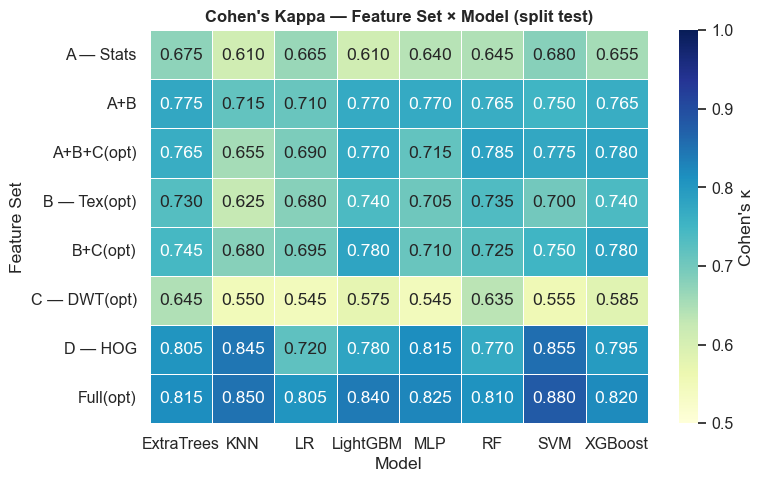

```
Saved: kappa_heatmap.png
```

```python
# ── Cohen's Kappa for every (Feature Set × Model) on split test ────────────
# cohen_kappa_score(y_true, y_pred) — computes κ from the confusion matrix.
# We use the split predictions stored in P2 which are the held-out test set.

# Keep this cell self-contained so it works regardless of execution order.
if "P2" not in globals() or not P2:
    if "P2_ALL" in globals() and "split" in P2_ALL and P2_ALL["split"]:
        P2 = P2_ALL["split"]
    else:
        raise NameError(
            "P2 is not defined. Run the Phase 2 benchmark cell first "
            "(the one that builds P2 / P2_ALL)."
        )
if "y_test" not in globals():
    raise NameError("y_test is not defined. Run the data split/evaluation setup cells first.")

init_phase2_viz_context()

kappa_rows = []
for fs_name in fs_list:
    for mn in mnames:
        if mn not in P2.get(fs_name, {}):
            continue
        y_pred = P2[fs_name][mn]["y_pred"]
        kappa  = cohen_kappa_score(y_test, y_pred)
        kappa_rows.append({
            "Feature Set": fs_name,
            "Model":       mn,
            "Kappa (κ)":   round(kappa, 4),
            "Accuracy":    round(P2[fs_name][mn]["acc"],  4),
            "F1-macro":    round(P2[fs_name][mn]["f1m"],  4),
        })

kappa_df = (pd.DataFrame(kappa_rows)
              .sort_values("Kappa (κ)", ascending=False)
              .reset_index(drop=True))
kappa_df.index += 1

print("Cohen's Kappa — all configurations (split test, sorted):")
display(kappa_df)

# ── Kappa heatmap ─────────────────────────────────────────────────────────
kappa_pivot = kappa_df.pivot_table(index="Feature Set", columns="Model",
                                    values="Kappa (κ)", aggfunc="first")

fig, ax = plt.subplots(figsize=(8, 5))
sns.heatmap(kappa_pivot, ax=ax, annot=True, fmt=".3f", cmap="YlGnBu",
            vmin=0.5, vmax=1.0, linewidths=0.5, cbar_kws={"label": "Cohen's κ"})
ax.set_title("Cohen's Kappa — Feature Set × Model (split test)", fontsize=12, fontweight="bold")
ax.tick_params(axis="x", rotation=0)
ax.tick_params(axis="y", rotation=0)
plt.tight_layout()
plt.savefig(OUTPUT_DIR / "kappa_heatmap.png", dpi=120, bbox_inches="tight")
plt.show()
print("Saved: kappa_heatmap.png")
```

### 15b. Bootstrap Confidence Intervals (95% CI)

**Bootstrap resampling** estimates the sampling distribution of a metric by drawing N = 2000 samples **with replacement** from the test set predictions.

- **CI Lower / Upper**: the 2.5th and 97.5th percentiles of the bootstrapped distribution
- **Bootstrap Mean**: robust central tendency estimate that accounts for sampling variability

This directly replicates the statistical analysis used in NeuroBlend-3 (Table 5).

```python
# ── Bootstrap CI for all (Feature Set × Model) on split test ──────────────
# scipy.stats.bootstrap takes a function that maps (y_true_sample, y_pred_sample) → scalar.
# We resample INDICES jointly to keep (true, pred) pairs aligned.

if "mnames" not in globals() or not mnames:
    init_phase2_viz_context()

N_BOOT    = 2000    # number of bootstrap resamples (2000 is standard)
CI_LEVEL  = 0.95    # 95% confidence interval
BOOT_SEED = SEED

def _boot_f1(indices):
    # Compute F1-macro on the bootstrap-selected subset of predictions.
    return f1_score(y_test[indices], y_pred_boot[indices],
                    average="macro", zero_division=0)

def _boot_acc(indices):
    # Compute accuracy on the bootstrap-selected subset.
    return accuracy_score(y_test[indices], y_pred_boot[indices])

boot_rows = []

for fs_name in fs_list:
    for mn in mnames:
        if mn not in P2.get(fs_name, {}):
            continue
        y_pred_boot = P2[fs_name][mn]["y_pred"]  # global used inside _boot_f1/_boot_acc
        idx_pool    = np.arange(len(y_test))

        # ── F1-macro bootstrap ─────────────────────────────────────────────
        res_f1 = scipy_bootstrap(
            (idx_pool,),                    # pass indices as a tuple
            lambda idx: _boot_f1(idx),
            n_resamples=N_BOOT,
            confidence_level=CI_LEVEL,
            method="percentile",
            random_state=BOOT_SEED,
        )
        # ── Accuracy bootstrap ────────────────────────────────────────────
        res_acc = scipy_bootstrap(
            (idx_pool,),
            lambda idx: _boot_acc(idx),
            n_resamples=N_BOOT,
            confidence_level=CI_LEVEL,
            method="percentile",
            random_state=BOOT_SEED,
        )

        # Bootstrap mean = mean of the resampled distribution
        f1_values  = res_f1.bootstrap_distribution
        acc_values = res_acc.bootstrap_distribution

        boot_rows.append({
            "Feature Set":      fs_name,
            "Model":            mn,
            "F1-macro":         round(P2[fs_name][mn]["f1m"], 4),
            "F1 CI Lower":      round(float(res_f1.confidence_interval.low),  4),
            "F1 CI Upper":      round(float(res_f1.confidence_interval.high), 4),
            "F1 Boot Mean":     round(float(f1_values.mean()),  4),
            "F1 Boot Std":      round(float(f1_values.std()),   4),
            "Accuracy":         round(P2[fs_name][mn]["acc"],   4),
            "Acc CI Lower":     round(float(res_acc.confidence_interval.low),  4),
            "Acc CI Upper":     round(float(res_acc.confidence_interval.high), 4),
            "Acc Boot Mean":    round(float(acc_values.mean()), 4),
            "Acc Boot Std":     round(float(acc_values.std()),  4),
        })
        print(f"  {fs_name:18s} | {mn:3s} | F1={boot_rows[-1]['F1-macro']:.4f} "
              f"CI=[{boot_rows[-1]['F1 CI Lower']:.4f}, {boot_rows[-1]['F1 CI Upper']:.4f}] "
              f"boot_mean={boot_rows[-1]['F1 Boot Mean']:.4f}")

boot_df = (pd.DataFrame(boot_rows)
             .sort_values("F1-macro", ascending=False)
             .reset_index(drop=True))
boot_df.index += 1

print("\nBootstrap CI (95%) — all configurations:")
display(boot_df)
boot_df.to_csv("bootstrap_ci_results.csv", index=False)
print("Saved: bootstrap_ci_results.csv")
```

```
  D — HOG            | SVM | F1=0.9032 CI=[0.8683, 0.9346] boot_mean=0.9030
  D — HOG            | KNN | F1=0.8967 CI=[0.8626, 0.9283] boot_mean=0.8964
  D — HOG            | RF  | F1=0.8463 CI=[0.8056, 0.8845] boot_mean=0.8460
  D — HOG            | XGBoost | F1=0.8626 CI=[0.8235, 0.8993] boot_mean=0.8624
  D — HOG            | LightGBM | F1=0.8522 CI=[0.8124, 0.8901] boot_mean=0.8521
  D — HOG            | LR  | F1=0.8136 CI=[0.7668, 0.8564] boot_mean=0.8133
  D — HOG            | MLP | F1=0.8767 CI=[0.8382, 0.9119] boot_mean=0.8764
  D — HOG            | ExtraTrees | F1=0.8691 CI=[0.8323, 0.9060] boot_mean=0.8690
  A — Stats          | SVM | F1=0.7867 CI=[0.7394, 0.8325] boot_mean=0.7852
  A — Stats          | KNN | F1=0.7427 CI=[0.6927, 0.7928] boot_mean=0.7414
  A — Stats          | RF  | F1=0.7640 CI=[0.7144, 0.8075] boot_mean=0.7622
  A — Stats          | XGBoost | F1=0.7693 CI=[0.7199, 0.8126] boot_mean=0.7674
  A — Stats          | LightGBM | F1=0.7394 CI=[0.6905, 0.7888] boot_mean=0.7379
  A — Stats          | LR  | F1=0.7770 CI=[0.7269, 0.8222] boot_mean=0.7758
  A — Stats          | MLP | F1=0.7579 CI=[0.7074, 0.8042] boot_mean=0.7565
  A — Stats          | ExtraTrees | F1=0.7828 CI=[0.7353, 0.8268] boot_mean=0.7810
  Full(opt)          | SVM | F1=0.9204 CI=[0.8895, 0.9504] boot_mean=0.9204
  Full(opt)          | KNN | F1=0.9002 CI=[0.8660, 0.9322] boot_mean=0.9002
  Full(opt)          | RF  | F1=0.8728 CI=[0.8339, 0.9076] boot_mean=0.8724
  Full(opt)          | XGBoost | F1=0.8800 CI=[0.8427, 0.9145] boot_mean=0.8795
  Full(opt)          | LightGBM | F1=0.8938 CI=[0.8592, 0.9267] boot_mean=0.8939
  Full(opt)          | LR  | F1=0.8702 CI=[0.8306, 0.9050] boot_mean=0.8696
  Full(opt)          | MLP | F1=0.8839 CI=[0.8457, 0.9187] boot_mean=0.8835
  Full(opt)          | ExtraTrees | F1=0.8765 CI=[0.8400, 0.9123] boot_mean=0.8761
  A+B                | SVM | F1=0.8339 CI=[0.7912, 0.8739] boot_mean=0.8332
  A+B                | KNN | F1=0.8093 CI=[0.7637, 0.8542] boot_mean=0.8094
  A+B                | RF  | F1=0.8434 CI=[0.8011, 0.8837] boot_mean=0.8426
  A+B                | XGBoost | F1=0.8435 CI=[0.8015, 0.8845] boot_mean=0.8427
  A+B                | LightGBM | F1=0.8470 CI=[0.8050, 0.8857] boot_mean=0.8465
  A+B                | LR  | F1=0.8059 CI=[0.7607, 0.8500] boot_mean=0.8049
  A+B                | MLP | F1=0.8452 CI=[0.8037, 0.8828] boot_mean=0.8445
  A+B                | ExtraTrees | F1=0.8505 CI=[0.8079, 0.8881] boot_mean=0.8501
  B — Tex(opt)       | SVM | F1=0.8001 CI=[0.7548, 0.8433] boot_mean=0.7996
  B — Tex(opt)       | KNN | F1=0.7482 CI=[0.6985, 0.7974] boot_mean=0.7476
  B — Tex(opt)       | RF  | F1=0.8228 CI=[0.7786, 0.8651] boot_mean=0.8227
  B — Tex(opt)       | XGBoost | F1=0.8268 CI=[0.7837, 0.8684] boot_mean=0.8264
  B — Tex(opt)       | LightGBM | F1=0.8263 CI=[0.7819, 0.8670] boot_mean=0.8261
  B — Tex(opt)       | LR  | F1=0.7871 CI=[0.7402, 0.8312] boot_mean=0.7862
  B — Tex(opt)       | MLP | F1=0.8043 CI=[0.7590, 0.8478] boot_mean=0.8044
  B — Tex(opt)       | ExtraTrees | F1=0.8192 CI=[0.7761, 0.8599] boot_mean=0.8188
```

[output cut: 11 more lines]

```
  B+C(opt)           | XGBoost | F1=0.8534 CI=[0.8133, 0.8915] boot_mean=0.8529
  B+C(opt)           | LightGBM | F1=0.8533 CI=[0.8117, 0.8909] boot_mean=0.8528
  B+C(opt)           | LR  | F1=0.7961 CI=[0.7469, 0.8400] boot_mean=0.7948
  B+C(opt)           | MLP | F1=0.8079 CI=[0.7638, 0.8497] boot_mean=0.8070
  B+C(opt)           | ExtraTrees | F1=0.8309 CI=[0.7869, 0.8720] boot_mean=0.8306
  A+B+C(opt)         | SVM | F1=0.8515 CI=[0.8089, 0.8898] boot_mean=0.8511
  A+B+C(opt)         | KNN | F1=0.7705 CI=[0.7216, 0.8177] boot_mean=0.7700
  A+B+C(opt)         | RF  | F1=0.8569 CI=[0.8168, 0.8972] boot_mean=0.8567
  A+B+C(opt)         | XGBoost | F1=0.8533 CI=[0.8132, 0.8906] boot_mean=0.8527
  A+B+C(opt)         | LightGBM | F1=0.8467 CI=[0.8043, 0.8871] boot_mean=0.8462
  A+B+C(opt)         | LR  | F1=0.7925 CI=[0.7449, 0.8378] boot_mean=0.7915
  A+B+C(opt)         | MLP | F1=0.8099 CI=[0.7645, 0.8511] boot_mean=0.8092
  A+B+C(opt)         | ExtraTrees | F1=0.8442 CI=[0.8028, 0.8839] boot_mean=0.8440

Bootstrap CI (95%) — all configurations:
```

|  | Feature Set | Model | F1-macro | F1 CI Lower | F1 CI Upper | F1 Boot Mean | F1 Boot Std | Accuracy | Acc CI Lower | Acc CI Upper | Acc Boot Mean | Acc Boot Std |
| --- | --- | --- | --- | --- | --- | --- | --- | --- | --- | --- | --- | --- |
| 1 | Full(opt) | SVM | 0.9204 | 0.8895 | 0.9504 | 0.9204 | 0.0158 | 0.9200 | 0.8900 | 0.9500 | 0.9203 | 0.0160 |
| 2 | D — HOG | SVM | 0.9032 | 0.8683 | 0.9346 | 0.9030 | 0.0169 | 0.9033 | 0.8699 | 0.9367 | 0.9036 | 0.0169 |
| 3 | Full(opt) | KNN | 0.9002 | 0.8660 | 0.9322 | 0.9002 | 0.0169 | 0.9000 | 0.8667 | 0.9333 | 0.9005 | 0.0170 |
| 4 | D — HOG | KNN | 0.8967 | 0.8626 | 0.9283 | 0.8964 | 0.0170 | 0.8967 | 0.8600 | 0.9300 | 0.8969 | 0.0172 |
| 5 | Full(opt) | LightGBM | 0.8938 | 0.8592 | 0.9267 | 0.8939 | 0.0178 | 0.8933 | 0.8567 | 0.9267 | 0.8939 | 0.0180 |
| ... | ... | ... | ... | ... | ... | ... | ... | ... | ... | ... | ... | ... |
| 60 | C — DWT(opt) | LightGBM | 0.7144 | 0.6615 | 0.7645 | 0.7140 | 0.0258 | 0.7167 | 0.6633 | 0.7667 | 0.7173 | 0.0258 |
| 61 | C — DWT(opt) | SVM | 0.7031 | 0.6516 | 0.7524 | 0.7021 | 0.0260 | 0.7033 | 0.6533 | 0.7533 | 0.7035 | 0.0260 |
| 62 | C — DWT(opt) | LR | 0.6940 | 0.6395 | 0.7456 | 0.6929 | 0.0268 | 0.6967 | 0.6433 | 0.7467 | 0.6966 | 0.0268 |
| 63 | C — DWT(opt) | KNN | 0.6932 | 0.6401 | 0.7448 | 0.6924 | 0.0264 | 0.7000 | 0.6467 | 0.7501 | 0.7002 | 0.0262 |
| 64 | C — DWT(opt) | MLP | 0.6919 | 0.6371 | 0.7433 | 0.6908 | 0.0264 | 0.6967 | 0.6433 | 0.7467 | 0.6966 | 0.0264 |

64 rows × 12 columns

```
Saved: bootstrap_ci_results.csv
```

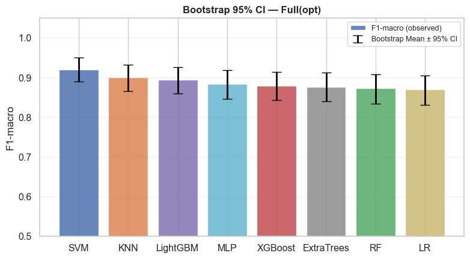

```
Saved: bootstrap_ci_best_fs.png
```

```python
# ── Visualise CI for the best feature set ──────────────────────────────────
best_fs_boot = boot_df.iloc[0]["Feature Set"]
sub = boot_df[boot_df["Feature Set"] == best_fs_boot].copy()

fig, ax = plt.subplots(figsize=(8, 4.5))
colors = [_model_color(m) for m in sub["Model"]]
x = np.arange(len(sub))

ax.bar(x, sub["F1-macro"], color=colors, alpha=0.85, edgecolor="white", label="F1-macro (observed)")
ax.errorbar(x, sub["F1 Boot Mean"],
            yerr=[sub["F1 Boot Mean"] - sub["F1 CI Lower"],
                  sub["F1 CI Upper"] - sub["F1 Boot Mean"]],
            fmt="none", color="black", capsize=6, linewidth=2,
            label="Bootstrap Mean ± 95% CI")

ax.set_xticks(x)
ax.set_xticklabels(sub["Model"])
ax.set_ylim(0.5, 1.05)
ax.set_ylabel("F1-macro")
ax.set_title(f"Bootstrap 95% CI — {best_fs_boot}", fontsize=12, fontweight="bold")
ax.legend(fontsize=9)
ax.grid(axis="y", alpha=0.3)
plt.tight_layout()
plt.savefig(OUTPUT_DIR / "bootstrap_ci_best_fs.png", dpi=120, bbox_inches="tight")
plt.show()
print("Saved: bootstrap_ci_best_fs.png")
```

### 15c. Cross-Validation Fold Statistics

For each (Feature Set × Model) pair we compute:

- **Mean F1-macro** across all available CV folds
- **Standard deviation** — measures consistency across partitions
- **95% CI** — computed from the t-distribution: mean ± t(α/2, df) × std/√n

A small standard deviation means the model is **stable** regardless of which samples land in the test fold.

```python
# ── Build per-fold statistics from P2_ALL ─────────────────────────────────
# P2_ALL[mode][feature_set][model] contains results for every eval mode.
# We collect all cv_* modes and compute statistics across folds.

from scipy.stats import t as t_dist

cv_modes = [m for m in EVAL_MODES if m.startswith("cv_")]

cv_stat_rows = []

for fs_name in fs_list:
    for mn in mnames:
        f1_folds  = []
        acc_folds = []

        for mode in cv_modes:
            if mode in P2_ALL and fs_name in P2_ALL[mode] and mn in P2_ALL[mode][fs_name]:
                r = P2_ALL[mode][fs_name][mn]
                f1_folds.append(r["f1m"])
                acc_folds.append(r["acc"])

        if len(f1_folds) < 2:
            continue   # need at least 2 folds for std/CI

        f1_arr  = np.array(f1_folds)
        acc_arr = np.array(acc_folds)
        n       = len(f1_arr)
        df_t    = n - 1                                  # degrees of freedom
        t_crit  = t_dist.ppf(0.975, df=df_t)            # two-tailed 95% CI

        f1_mean  = f1_arr.mean()
        f1_std   = f1_arr.std(ddof=1)
        f1_ci_w  = t_crit * f1_std / np.sqrt(n)         # half-width of CI

        acc_mean = acc_arr.mean()
        acc_std  = acc_arr.std(ddof=1)
        acc_ci_w = t_crit * acc_std / np.sqrt(n)

        cv_stat_rows.append({
            "Feature Set":   fs_name,
            "Model":         mn,
            "N folds":       n,
            "F1 Mean":       round(f1_mean,  4),
            "F1 Std":        round(f1_std,   4),
            "F1 CI Lower":   round(f1_mean - f1_ci_w, 4),
            "F1 CI Upper":   round(f1_mean + f1_ci_w, 4),
            "Acc Mean":      round(acc_mean, 4),
            "Acc Std":       round(acc_std,  4),
            "Acc CI Lower":  round(acc_mean - acc_ci_w, 4),
            "Acc CI Upper":  round(acc_mean + acc_ci_w, 4),
        })

cv_stat_df = (pd.DataFrame(cv_stat_rows)
                .sort_values("F1 Mean", ascending=False)
                .reset_index(drop=True))
cv_stat_df.index += 1

print(f"CV fold statistics ({len(cv_modes)} folds: {cv_modes}):")
display(cv_stat_df)
cv_stat_df.to_csv("cv_fold_statistics.csv", index=False)
print("Saved: cv_fold_statistics.csv")
```

```
CV fold statistics (5 folds: ['cv_1', 'cv_2', 'cv_3', 'cv_4', 'cv_5']):
```

|  | Feature Set | Model | N folds | F1 Mean | F1 Std | F1 CI Lower | F1 CI Upper | Acc Mean | Acc Std | Acc CI Lower | Acc CI Upper |
| --- | --- | --- | --- | --- | --- | --- | --- | --- | --- | --- | --- |
| 1 | Full(opt) | SVM | 5 | 0.8951 | 0.0100 | 0.8827 | 0.9074 | 0.8953 | 0.0099 | 0.8830 | 0.9077 |
| 2 | Full(opt) | LightGBM | 5 | 0.8784 | 0.0086 | 0.8677 | 0.8891 | 0.8783 | 0.0083 | 0.8681 | 0.8886 |
| 3 | Full(opt) | ExtraTrees | 5 | 0.8784 | 0.0044 | 0.8730 | 0.8838 | 0.8788 | 0.0042 | 0.8736 | 0.8840 |
| 4 | Full(opt) | RF | 5 | 0.8775 | 0.0049 | 0.8715 | 0.8835 | 0.8780 | 0.0041 | 0.8728 | 0.8832 |
| 5 | Full(opt) | MLP | 5 | 0.8725 | 0.0110 | 0.8588 | 0.8862 | 0.8728 | 0.0111 | 0.8590 | 0.8866 |
| ... | ... | ... | ... | ... | ... | ... | ... | ... | ... | ... | ... |
| 60 | C — DWT(opt) | SVM | 5 | 0.7286 | 0.0086 | 0.7180 | 0.7392 | 0.7290 | 0.0093 | 0.7174 | 0.7406 |
| 61 | C — DWT(opt) | MLP | 5 | 0.7282 | 0.0179 | 0.7060 | 0.7503 | 0.7293 | 0.0192 | 0.7055 | 0.7532 |
| 62 | C — DWT(opt) | RF | 5 | 0.7278 | 0.0232 | 0.6989 | 0.7566 | 0.7287 | 0.0229 | 0.7002 | 0.7572 |
| 63 | C — DWT(opt) | LR | 5 | 0.7037 | 0.0029 | 0.7002 | 0.7073 | 0.7053 | 0.0020 | 0.7028 | 0.7078 |
| 64 | C — DWT(opt) | KNN | 5 | 0.6998 | 0.0266 | 0.6668 | 0.7328 | 0.7015 | 0.0260 | 0.6692 | 0.7338 |

64 rows × 11 columns

```
Saved: cv_fold_statistics.csv
```

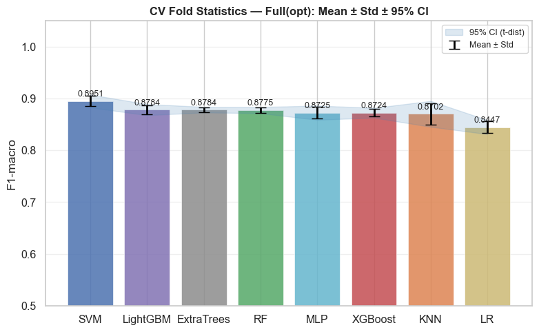

```
Saved: cv_fold_statistics.png
```

```python
# ── Plot: Mean ± Std across CV folds for Full(opt) ────────────────────────
sub_cv = cv_stat_df[cv_stat_df["Feature Set"] == "Full(opt)"].copy()

if len(sub_cv) == 0:
    print("No CV fold data for Full(opt) — skipping plot.")
else:
    fig, ax = plt.subplots(figsize=(8, 5))
    x       = np.arange(len(sub_cv))
    colors  = [_model_color(m) for m in sub_cv["Model"]]

    bars = ax.bar(x, sub_cv["F1 Mean"], color=colors, alpha=0.85,
                  edgecolor="white", linewidth=0.5)
    ax.errorbar(x, sub_cv["F1 Mean"],
                yerr=sub_cv["F1 Std"],
                fmt="none", color="black", capsize=6, linewidth=2,
                label="Mean ± Std")
    ax.fill_between(x,
                    sub_cv["F1 CI Lower"].values,
                    sub_cv["F1 CI Upper"].values,
                    alpha=0.18, color="steelblue", label="95% CI (t-dist)")

    ax.set_xticks(x)
    ax.set_xticklabels(sub_cv["Model"])
    ax.set_ylim(0.5, 1.05)
    ax.set_ylabel("F1-macro")
    ax.set_title("CV Fold Statistics — Full(opt): Mean ± Std ± 95% CI",
                 fontsize=12, fontweight="bold")
    ax.legend(fontsize=9)
    ax.grid(axis="y", alpha=0.3)
    for bar, val in zip(bars, sub_cv["F1 Mean"]):
        ax.text(bar.get_x() + bar.get_width()/2, val + 0.005,
                f"{val:.4f}", ha="center", va="bottom", fontsize=9)
    plt.tight_layout()
    plt.savefig(OUTPUT_DIR / "cv_fold_statistics.png", dpi=120, bbox_inches="tight")
    plt.show()
    print("Saved: cv_fold_statistics.png")
```

### 15d. McNemar's Test (Pairwise Classifier Comparison)

**McNemar's test** is the standard statistical significance test for comparing two classifiers on the **same test set**. It examines whether the two models make **different errors** on different samples, not just whether their accuracy numbers differ.

**Null hypothesis H₀:** The two classifiers have the same error rate on the test population.

The contingency table counts:

- **n₀₁**: samples where classifier A is correct but B is wrong
- **n₁₀**: samples where classifier B is correct but A is wrong

If p < 0.05, the difference between the two classifiers is **statistically significant**.

```
McNemar's test (continuity corrected) — feature set: Full(opt)
```

|  | Model A | Model B | n₀₁ (A✓ B✗) | n₁₀ (A✗ B✓) | p-value | Significant (p<0.05) | Interpretation |
| --- | --- | --- | --- | --- | --- | --- | --- |
| 0 | SVM | KNN | 20 | 14 | 0.391173 | ✗ No | No significant difference |
| 1 | SVM | RF | 18 | 4 | 0.005578 | ✓ Yes | A is significantly better than B |
| 2 | SVM | XGBoost | 17 | 5 | 0.019016 | ✓ Yes | A is significantly better than B |
| 3 | SVM | LightGBM | 14 | 6 | 0.117525 | ✗ No | No significant difference |
| 4 | SVM | LR | 19 | 4 | 0.003509 | ✓ Yes | A is significantly better than B |
| 5 | SVM | MLP | 15 | 4 | 0.021781 | ✓ Yes | A is significantly better than B |
| 6 | SVM | ExtraTrees | 18 | 5 | 0.012343 | ✓ Yes | A is significantly better than B |
| 7 | KNN | RF | 25 | 17 | 0.280087 | ✗ No | No significant difference |
| 8 | KNN | XGBoost | 24 | 18 | 0.440401 | ✗ No | No significant difference |
| 9 | KNN | LightGBM | 20 | 18 | 0.871131 | ✗ No | No significant difference |
| 10 | KNN | LR | 28 | 19 | 0.243243 | ✗ No | No significant difference |
| 11 | KNN | MLP | 23 | 18 | 0.532171 | ✗ No | No significant difference |
| 12 | KNN | ExtraTrees | 24 | 17 | 0.348737 | ✗ No | No significant difference |
| 13 | RF | XGBoost | 6 | 8 | 0.789268 | ✗ No | No significant difference |
| 14 | RF | LightGBM | 3 | 9 | 0.148915 | ✗ No | No significant difference |
| 15 | RF | LR | 13 | 12 | 1.000000 | ✗ No | No significant difference |
| 16 | RF | MLP | 16 | 19 | 0.735317 | ✗ No | No significant difference |
| 17 | RF | ExtraTrees | 3 | 4 | 1.000000 | ✗ No | No significant difference |
| 18 | XGBoost | LightGBM | 3 | 7 | 0.342782 | ✗ No | No significant difference |
| 19 | XGBoost | LR | 13 | 10 | 0.676657 | ✗ No | No significant difference |
| 20 | XGBoost | MLP | 12 | 13 | 1.000000 | ✗ No | No significant difference |
| 21 | XGBoost | ExtraTrees | 7 | 6 | 1.000000 | ✗ No | No significant difference |
| 22 | LightGBM | LR | 16 | 9 | 0.230139 | ✗ No | No significant difference |
| 23 | LightGBM | MLP | 15 | 12 | 0.700311 | ✗ No | No significant difference |
| 24 | LightGBM | ExtraTrees | 8 | 3 | 0.227800 | ✗ No | No significant difference |
| 25 | LR | MLP | 11 | 15 | 0.556298 | ✗ No | No significant difference |
| 26 | LR | ExtraTrees | 13 | 15 | 0.850107 | ✗ No | No significant difference |
| 27 | MLP | ExtraTrees | 17 | 15 | 0.859684 | ✗ No | No significant difference |

```
Saved: mcnemar_test_results.csv
```

[figure not shown]

```
Saved: mcnemar_pvalue_matrix.png
```

```python
# ── McNemar's test between all pairs of classifiers (best feature set) ──────
# We test on Full(opt) predictions since that is the best feature set.

from itertools import combinations

def mcnemar_test(y_true, y_pred_a, y_pred_b):
    """
    McNemar's test with continuity correction (Edwards, 1948).

    Contingency table:
        n00 = both correct   | n01 = A correct,  B wrong
        n10 = A wrong, B correct | n11 = both wrong

    Test statistic (with continuity correction):
        χ² = (|n01 - n10| - 1)² / (n01 + n10)
    p-value from χ²(df=1) distribution.
    """
    correct_a = (y_pred_a == y_true)
    correct_b = (y_pred_b == y_true)

    n00 = int(( correct_a &  correct_b).sum())
    n01 = int(( correct_a & ~correct_b).sum())   # A right, B wrong
    n10 = int((~correct_a &  correct_b).sum())   # A wrong, B right
    n11 = int((~correct_a & ~correct_b).sum())

    # McNemar statistic with continuity correction
    denom = n01 + n10
    if denom == 0:
        return 1.0, n00, n01, n10, n11   # identical predictions → p=1

    chi2 = (abs(n01 - n10) - 1) ** 2 / denom
    from scipy.stats import chi2 as chi2_dist
    p_val = chi2_dist.sf(chi2, df=1)    # survival function = 1 - CDF

    return float(p_val), n00, n01, n10, n11


if "mnames" not in globals() or not mnames:
    init_phase2_viz_context()

# Run for Full(opt) across all model pairs
TARGET_FS_MC = "Full(opt)"
if TARGET_FS_MC not in P2:
    raise KeyError(f"Feature set {TARGET_FS_MC!r} not in P2 — check Phase 2 completed feature sets.")
mc_mnames = [m for m in mnames if m in P2[TARGET_FS_MC]]
mcnemar_rows = []
if len(mc_mnames) < 2:
    print(f"McNemar skipped: need ≥2 models on {TARGET_FS_MC}, found {mc_mnames}")
else:
    preds = {mn: P2[TARGET_FS_MC][mn]["y_pred"] for mn in mc_mnames}
    for (a, b) in combinations(mc_mnames, 2):
        p, n00, n01, n10, n11 = mcnemar_test(y_test, preds[a], preds[b])
        mcnemar_rows.append({
            "Model A":          a,
            "Model B":          b,
            "n₀₁ (A✓ B✗)":     n01,
            "n₁₀ (A✗ B✓)":     n10,
            "p-value":          round(p, 6),
            "Significant (p<0.05)": "✓ Yes" if p < 0.05 else "✗ No",
            "Interpretation":   ("A is significantly better than B" if n01 > n10 and p < 0.05
                                 else "B is significantly better than A" if n10 > n01 and p < 0.05
                                 else "No significant difference"),
        })

    mcnemar_df = pd.DataFrame(mcnemar_rows)
    print(f"McNemar's test (continuity corrected) — feature set: {TARGET_FS_MC}")
    display(mcnemar_df)
    mcnemar_df.to_csv("mcnemar_test_results.csv", index=False)
    print("Saved: mcnemar_test_results.csv")

    # ── p-value matrix heatmap ─────────────────────────────────────────────
    p_matrix = pd.DataFrame(np.eye(len(mc_mnames)), index=mc_mnames, columns=mc_mnames)
    for row in mcnemar_rows:
        p_matrix.loc[row["Model A"], row["Model B"]] = row["p-value"]
        p_matrix.loc[row["Model B"], row["Model A"]] = row["p-value"]

    fig, ax = plt.subplots(figsize=(6, 5))
    mask = np.eye(len(mc_mnames), dtype=bool)   # mask diagonal (always p=1)
    sns.heatmap(p_matrix.astype(float), ax=ax, annot=True, fmt=".4f",
                cmap="RdYlGn_r", vmin=0, vmax=0.1, linewidths=1,
                mask=mask, cbar_kws={"label": "p-value"})
    ax.set_title(f"McNemar's Test — p-value Matrix\n({TARGET_FS_MC})",
                 fontsize=12, fontweight="bold")
    ax.text(0.5, -0.12, "Red = significant (p < 0.05)  |  Green = not significant",
            transform=ax.transAxes, ha="center", fontsize=9, color="gray")
    plt.tight_layout()
    plt.savefig(OUTPUT_DIR / "mcnemar_pvalue_matrix.png", dpi=120, bbox_inches="tight")
    plt.show()
    print("Saved: mcnemar_pvalue_matrix.png")
```

### 15e. Wilcoxon Signed-Rank Test (Across CV Folds)

The **Wilcoxon signed-rank test** compares two classifiers across multiple CV folds in a **paired, non-parametric** way. It is the recommended alternative to a paired t-test when the distribution of per-fold score differences cannot be assumed to be normal.

**Why Wilcoxon instead of t-test?** With only 5 CV folds, the Central Limit Theorem does not apply reliably. Wilcoxon makes no assumption about normality — it ranks the absolute differences and tests whether they are symmetrically distributed around zero.

**Null hypothesis H₀:** The median of per-fold F1 differences is zero (models are equivalent).

```python
# ── Wilcoxon signed-rank test between all classifier pairs across CV folds ──
# Collect per-fold F1-macro for each (feature_set, model) combination.

def get_cv_scores(fs_name, mn):
    """Return list of CV fold F1-macro values for a given (fs, model) pair."""
    scores = []
    for mode in cv_modes:
        if mode in P2_ALL and fs_name in P2_ALL[mode] and mn in P2_ALL[mode][fs_name]:
            scores.append(P2_ALL[mode][fs_name][mn]["f1m"])
    return scores


wilcoxon_rows = []

for fs_name in fs_list:
    for (a, b) in combinations(mnames, 2):
        scores_a = get_cv_scores(fs_name, a)
        scores_b = get_cv_scores(fs_name, b)

        # Both must have equal number of folds for a paired test
        n_common = min(len(scores_a), len(scores_b))
        if n_common < 3:
            # Wilcoxon requires at least 3 pairs (n_pairs = number of non-zero diffs)
            continue

        scores_a = np.array(scores_a[:n_common])
        scores_b = np.array(scores_b[:n_common])
        diffs    = scores_a - scores_b

        # If all differences are zero the test cannot be run
        if np.all(diffs == 0):
            p = 1.0
            statistic = 0.0
        else:
            try:
                statistic, p = wilcoxon(scores_a, scores_b,
                                        alternative="two-sided",
                                        zero_method="wilcox")
            except ValueError:
                p, statistic = 1.0, 0.0

        wilcoxon_rows.append({
            "Feature Set":           fs_name,
            "Model A":               a,
            "Model B":               b,
            "A mean F1":             round(scores_a.mean(), 4),
            "B mean F1":             round(scores_b.mean(), 4),
            "Mean diff (A−B)":       round(diffs.mean(), 4),
            "W statistic":           round(statistic, 4),
            "p-value":               round(p, 6),
            "Significant (p<0.05)":  "✓ Yes" if p < 0.05 else "✗ No",
        })

wilcoxon_df = (pd.DataFrame(wilcoxon_rows)
                 .sort_values("p-value")
                 .reset_index(drop=True))
wilcoxon_df.index += 1

print(f"Wilcoxon signed-rank test ({n_common} CV folds):")
display(wilcoxon_df)
wilcoxon_df.to_csv("wilcoxon_test_results.csv", index=False)
print("Saved: wilcoxon_test_results.csv")

# Highlight significant differences
sig_count = (wilcoxon_df["Significant (p<0.05)"] == "✓ Yes").sum()
print(f"\n{sig_count} / {len(wilcoxon_df)} comparisons show significant differences (p < 0.05)")
```

```
Wilcoxon signed-rank test (5 CV folds):
```

|  | Feature Set | Model A | Model B | A mean F1 | B mean F1 | Mean diff (A−B) | W statistic | p-value | Significant (p<0.05) |
| --- | --- | --- | --- | --- | --- | --- | --- | --- | --- |
| 1 | D — HOG | SVM | KNN | 0.8699 | 0.8386 | 0.0313 | 0.0 | 0.0625 | ✗ No |
| 2 | D — HOG | SVM | RF | 0.8699 | 0.8392 | 0.0307 | 0.0 | 0.0625 | ✗ No |
| 3 | D — HOG | SVM | LightGBM | 0.8699 | 0.8420 | 0.0279 | 0.0 | 0.0625 | ✗ No |
| 4 | D — HOG | SVM | LR | 0.8699 | 0.7824 | 0.0875 | 0.0 | 0.0625 | ✗ No |
| 5 | D — HOG | SVM | ExtraTrees | 0.8699 | 0.8346 | 0.0353 | 0.0 | 0.0625 | ✗ No |
| ... | ... | ... | ... | ... | ... | ... | ... | ... | ... |
| 220 | C — DWT(opt) | SVM | MLP | 0.7286 | 0.7282 | 0.0004 | 7.0 | 1.0000 | ✗ No |
| 221 | B+C(opt) | XGBoost | LightGBM | 0.8320 | 0.8329 | -0.0009 | 7.0 | 1.0000 | ✗ No |
| 222 | C — DWT(opt) | SVM | RF | 0.7286 | 0.7278 | 0.0008 | 7.0 | 1.0000 | ✗ No |
| 223 | A+B+C(opt) | SVM | RF | 0.8385 | 0.8386 | -0.0001 | 7.0 | 1.0000 | ✗ No |
| 224 | A+B+C(opt) | LightGBM | ExtraTrees | 0.8467 | 0.8445 | 0.0022 | 7.0 | 1.0000 | ✗ No |

224 rows × 9 columns

```
Saved: wilcoxon_test_results.csv

0 / 224 comparisons show significant differences (p < 0.05)
```

### 15f. Friedman Test + Post-Hoc Nemenyi Test

The **Friedman test** is a non-parametric equivalent of the one-way repeated-measures ANOVA. It tests whether at least one of k classifiers performs significantly differently from the others, using the CV fold scores as "blocks."

**If the Friedman test is significant (p < 0.05),** the **post-hoc Nemenyi test** identifies *which pairs* of classifiers are significantly different, controlling for multiple comparisons.

This is the **gold standard** for comparing multiple classifiers on multiple datasets/folds (Demšar, 2006 — "Statistical Comparisons of Classifiers over Multiple Data Sets").

```
============================================================
FRIEDMAN TEST — Comparing all Phase 2 classifiers across CV folds
============================================================

Friedman test results:
```

|  | Feature Set | N folds | Friedman statistic | p-value | Significant (p<0.05) | Models compared |
| --- | --- | --- | --- | --- | --- | --- |
| 1 | D — HOG | 5 | 22.3333 | 0.002225 | ✓ Yes | SVM, KNN, RF, XGBoost, LightGBM, LR, MLP, Extr... |
| 2 | A — Stats | 5 | 24.6000 | 0.000893 | ✓ Yes | SVM, KNN, RF, XGBoost, LightGBM, LR, MLP, Extr... |
| 3 | Full(opt) | 5 | 23.6000 | 0.001339 | ✓ Yes | SVM, KNN, RF, XGBoost, LightGBM, LR, MLP, Extr... |
| 4 | A+B | 5 | 28.2000 | 0.000202 | ✓ Yes | SVM, KNN, RF, XGBoost, LightGBM, LR, MLP, Extr... |
| 5 | B — Tex(opt) | 5 | 32.2000 | 0.000037 | ✓ Yes | SVM, KNN, RF, XGBoost, LightGBM, LR, MLP, Extr... |
| 6 | C — DWT(opt) | 5 | 24.2667 | 0.001023 | ✓ Yes | SVM, KNN, RF, XGBoost, LightGBM, LR, MLP, Extr... |
| 7 | B+C(opt) | 5 | 25.6000 | 0.000594 | ✓ Yes | SVM, KNN, RF, XGBoost, LightGBM, LR, MLP, Extr... |
| 8 | A+B+C(opt) | 5 | 29.7333 | 0.000106 | ✓ Yes | SVM, KNN, RF, XGBoost, LightGBM, LR, MLP, Extr... |

```
Saved: friedman_test_results.csv
```

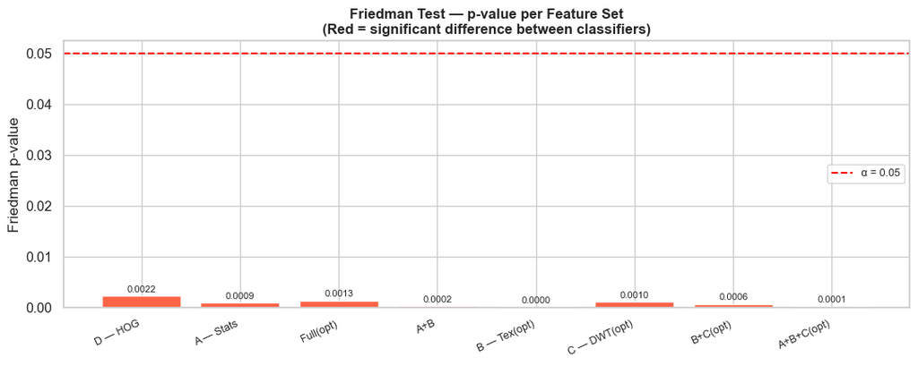

```
Saved: friedman_pvalues.png
```

```python
# ── Friedman test across all classifiers on each feature set ──────────────
# The test requires a matrix of shape (n_blocks × n_classifiers)
# where rows = CV folds and columns = classifiers.

print("=" * 60)
print("FRIEDMAN TEST — Comparing all Phase 2 classifiers across CV folds")
print("=" * 60)

friedman_rows = []
nemenyi_results = {}

for fs_name in fs_list:
    cv_matrix = []
    models_present = []

    for mn in mnames:
        scores = get_cv_scores(fs_name, mn)
        if len(scores) >= 3:
            cv_matrix.append(scores[:min(len(s) for s in [get_cv_scores(fs_name, m)
                                         for m in mnames if len(get_cv_scores(fs_name, m)) > 0])])
            models_present.append(mn)

    if len(models_present) < 2:
        continue

    # Ensure all models have the same number of folds (use minimum)
    min_folds = min(len(s) for s in cv_matrix)
    cv_arr = np.array([s[:min_folds] for s in cv_matrix])  # shape: (n_models, n_folds)

    # Friedman test requires rows=folds, cols=classifiers → transpose
    cv_arr_t = cv_arr.T   # shape: (n_folds, n_models)

    if cv_arr_t.shape[0] < 2:
        continue

    try:
        stat, p_friedman = friedmanchisquare(*[cv_arr_t[:, j] for j in range(cv_arr_t.shape[1])])
    except Exception:
        continue

    friedman_rows.append({
        "Feature Set":           fs_name,
        "N folds":               min_folds,
        "Friedman statistic":    round(stat, 4),
        "p-value":               round(p_friedman, 6),
        "Significant (p<0.05)":  "✓ Yes" if p_friedman < 0.05 else "✗ No",
        "Models compared":       ", ".join(models_present),
    })

    # ── Post-hoc Nemenyi (only if Friedman significant) ──────────────────
    if p_friedman < 0.05:
        # Build DataFrame for scikit-posthocs
        data_list = []
        for j, mn in enumerate(models_present):
            for fold_score in cv_arr_t[:, j]:
                data_list.append({"model": mn, "score": fold_score})
        data_ph = pd.DataFrame(data_list)
        try:
            nemenyi_p = sp.posthoc_nemenyi_friedman(
                data_ph, melted=True, block_col=None,
                group_col="model", y_col="score"
            )
            nemenyi_results[fs_name] = nemenyi_p
        except Exception:
            pass
    else:
        print(f"  {fs_name}: Friedman p={p_friedman:.4f} — no post-hoc needed (H₀ not rejected)")

friedman_df = pd.DataFrame(friedman_rows).reset_index(drop=True)
friedman_df.index += 1

print("\nFriedman test results:")
display(friedman_df)
friedman_df.to_csv("friedman_test_results.csv", index=False)
print("Saved: friedman_test_results.csv")

# ── Plot Friedman p-values ────────────────────────────────────────────────
fig, ax = plt.subplots(figsize=(11, 4.5))
colors = ["tomato" if sig == "✓ Yes" else "steelblue"
          for sig in friedman_df["Significant (p<0.05)"]]
bars = ax.bar(friedman_df["Feature Set"], friedman_df["p-value"],
              color=colors, edgecolor="white")
ax.axhline(0.05, color="red", ls="--", lw=1.5, label="α = 0.05")
ax.set_ylabel("Friedman p-value")
ax.set_title("Friedman Test — p-value per Feature Set\n(Red = significant difference between classifiers)",
             fontsize=12, fontweight="bold")
ax.set_xticklabels(friedman_df["Feature Set"], rotation=25, ha="right", fontsize=9)
ax.bar_label(bars, fmt="%.4f", fontsize=8, padding=2)
ax.legend(fontsize=9)
plt.tight_layout()
plt.savefig(OUTPUT_DIR / "friedman_pvalues.png", dpi=120, bbox_inches="tight")
plt.show()
print("Saved: friedman_pvalues.png")
```

```python
# ── Nemenyi post-hoc heatmaps (for significant Friedman results) ──────────
if len(nemenyi_results) == 0:
    print("No significant Friedman results — no post-hoc Nemenyi plots to show.")
else:
    n_sig = len(nemenyi_results)
    fig, axes = plt.subplots(1, n_sig, figsize=(6 * n_sig, 5))
    if n_sig == 1:
        axes = [axes]

    for ax, (fs_name, nemenyi_p) in zip(axes, nemenyi_results.items()):
        mask_diag = np.eye(nemenyi_p.shape[0], dtype=bool)
        sns.heatmap(nemenyi_p, ax=ax, annot=True, fmt=".3f",
                    cmap="RdYlGn_r", vmin=0, vmax=0.1,
                    linewidths=1, mask=mask_diag,
                    cbar_kws={"label": "p-value"})
        ax.set_title(f"Nemenyi post-hoc\n{fs_name}", fontsize=10, fontweight="bold")
        ax.tick_params(axis="x", rotation=30)

    fig.suptitle("Post-hoc Nemenyi Test — Pairwise p-values\n(Red = significant, Green = not significant)",
                 fontsize=12, fontweight="bold")
    plt.tight_layout()
    plt.savefig(OUTPUT_DIR / "nemenyi_posthoc.png", dpi=120, bbox_inches="tight")
    plt.show()
    print("Saved: nemenyi_posthoc.png")
```

[output not shown]

### 15g. Publication-Ready Statistical Summary Table

This table consolidates all statistical validation results for the **best configuration** (Full(opt) + best model), following the format of NeuroBlend-3 (Table 5):

| Column | Meaning |
| --- | --- |
| **Accuracy / F1-macro** | Point estimate on split test |
| **Std** | Standard deviation across CV folds |
| **CI Lower / CI Upper** | 95% confidence interval (bootstrap) |
| **Boot Mean** | Bootstrap mean estimate |
| **κ (Kappa)** | Cohen's Kappa on split test |

```python
# ── Build publication-ready summary table ─────────────────────────────────
# Merge: (1) split metrics, (2) bootstrap CI, (3) CV std, (4) Cohen's Kappa

summary_rows = []

for fs_name in fs_list:
    for mn in mnames:
        if mn not in P2.get(fs_name, {}):
            continue
        # 1. Split test metrics
        sp = P2[fs_name][mn]

        # 2. Bootstrap CI
        bc = boot_df[(boot_df["Feature Set"] == fs_name) & (boot_df["Model"] == mn)]
        if bc.empty:
            continue
        bc = bc.iloc[0]

        # 3. CV std
        cs = cv_stat_df[(cv_stat_df["Feature Set"] == fs_name) & (cv_stat_df["Model"] == mn)]
        f1_std_cv  = cs.iloc[0]["F1 Std"]  if not cs.empty else float("nan")
        acc_std_cv = cs.iloc[0]["Acc Std"] if not cs.empty else float("nan")

        # 4. Cohen's Kappa
        kc = kappa_df[(kappa_df["Feature Set"] == fs_name) & (kappa_df["Model"] == mn)]
        kappa_val = kc.iloc[0]["Kappa (κ)"] if not kc.empty else float("nan")

        summary_rows.append({
            "Feature Set":   fs_name,
            "Model":         mn,
            "Accuracy":      round(sp["acc"], 4),
            "Acc Std (CV)":  round(acc_std_cv, 4),
            "Acc CI Low":    round(bc["Acc CI Lower"], 4),
            "Acc CI High":   round(bc["Acc CI Upper"], 4),
            "F1-macro":      round(sp["f1m"], 4),
            "F1 Std (CV)":   round(f1_std_cv, 4),
            "F1 CI Low":     round(bc["F1 CI Lower"], 4),
            "F1 CI High":    round(bc["F1 CI Upper"], 4),
            "F1 Boot Mean":  round(bc["F1 Boot Mean"], 4),
            "κ (Kappa)":     kappa_val,
            "Precision":     round(sp["prec"], 4),
            "Recall":        round(sp["rec"],  4),
        })

summary_df = (pd.DataFrame(summary_rows)
                .sort_values("F1-macro", ascending=False)
                .reset_index(drop=True))
if summary_df.empty:
    raise ValueError("No statistical summary rows — run kappa, bootstrap, and CV stats cells first.")
summary_df.index += 1

print("PUBLICATION-READY STATISTICAL SUMMARY TABLE")
print("=" * 100)
display(summary_df)

summary_df.to_csv("statistical_validation_summary.csv", index=False)
print("Saved: statistical_validation_summary.csv")

# ── Print best configuration in NeuroBlend-3 style ────────────────────────
best_row = summary_df.iloc[0]
print("\n" + "=" * 65)
print("BEST CONFIGURATION — Statistical Summary")
print("=" * 65)
print(f"  Feature Set  : {best_row['Feature Set']}")
print(f"  Model        : {best_row['Model']}")
print(f"  Accuracy     : {best_row['Accuracy']:.4f}  (±{best_row['Acc Std (CV)']:.4f})")
print(f"  Acc 95% CI   : [{best_row['Acc CI Low']:.4f}, {best_row['Acc CI High']:.4f}]")
print(f"  F1-macro     : {best_row['F1-macro']:.4f}  (±{best_row['F1 Std (CV)']:.4f})")
print(f"  F1 95% CI    : [{best_row['F1 CI Low']:.4f}, {best_row['F1 CI High']:.4f}]")
print(f"  F1 Boot Mean : {best_row['F1 Boot Mean']:.4f}")
print(f"  Cohen's κ    : {best_row['κ (Kappa)']:.4f}")
print(f"  Precision    : {best_row['Precision']:.4f}")
print(f"  Recall       : {best_row['Recall']:.4f}")
```

```
PUBLICATION-READY STATISTICAL SUMMARY TABLE
====================================================================================================
```

|  | Feature Set | Model | Accuracy | Acc Std (CV) | Acc CI Low | Acc CI High | F1-macro | F1 Std (CV) | F1 CI Low | F1 CI High | F1 Boot Mean | κ (Kappa) | Precision | Recall |
| --- | --- | --- | --- | --- | --- | --- | --- | --- | --- | --- | --- | --- | --- | --- |
| 1 | Full(opt) | SVM | 0.9200 | 0.0099 | 0.8900 | 0.9500 | 0.9204 | 0.0100 | 0.8895 | 0.9504 | 0.9204 | 0.880 | 0.9228 | 0.9200 |
| 2 | D — HOG | SVM | 0.9033 | 0.0180 | 0.8699 | 0.9367 | 0.9032 | 0.0182 | 0.8683 | 0.9346 | 0.9030 | 0.855 | 0.9040 | 0.9033 |
| 3 | Full(opt) | KNN | 0.9000 | 0.0200 | 0.8667 | 0.9333 | 0.9002 | 0.0201 | 0.8660 | 0.9322 | 0.9002 | 0.850 | 0.9009 | 0.9000 |
| 4 | D — HOG | KNN | 0.8967 | 0.0181 | 0.8600 | 0.9300 | 0.8967 | 0.0183 | 0.8626 | 0.9283 | 0.8964 | 0.845 | 0.8971 | 0.8967 |
| 5 | Full(opt) | LightGBM | 0.8933 | 0.0083 | 0.8567 | 0.9267 | 0.8938 | 0.0086 | 0.8592 | 0.9267 | 0.8939 | 0.840 | 0.8964 | 0.8933 |
| ... | ... | ... | ... | ... | ... | ... | ... | ... | ... | ... | ... | ... | ... | ... |
| 60 | C — DWT(opt) | LightGBM | 0.7167 | 0.0193 | 0.6633 | 0.7667 | 0.7144 | 0.0193 | 0.6615 | 0.7645 | 0.7140 | 0.575 | 0.7145 | 0.7167 |
| 61 | C — DWT(opt) | SVM | 0.7033 | 0.0093 | 0.6533 | 0.7533 | 0.7031 | 0.0086 | 0.6516 | 0.7524 | 0.7021 | 0.555 | 0.7048 | 0.7033 |
| 62 | C — DWT(opt) | LR | 0.6967 | 0.0020 | 0.6433 | 0.7467 | 0.6940 | 0.0029 | 0.6395 | 0.7456 | 0.6929 | 0.545 | 0.6970 | 0.6967 |
| 63 | C — DWT(opt) | KNN | 0.7000 | 0.0260 | 0.6467 | 0.7501 | 0.6932 | 0.0266 | 0.6401 | 0.7448 | 0.6924 | 0.550 | 0.7071 | 0.7000 |
| 64 | C — DWT(opt) | MLP | 0.6967 | 0.0192 | 0.6433 | 0.7467 | 0.6919 | 0.0179 | 0.6371 | 0.7433 | 0.6908 | 0.545 | 0.6961 | 0.6967 |

64 rows × 14 columns

```
Saved: statistical_validation_summary.csv

=================================================================
BEST CONFIGURATION — Statistical Summary
=================================================================
  Feature Set  : Full(opt)
  Model        : SVM
  Accuracy     : 0.9200  (±0.0099)
  Acc 95% CI   : [0.8900, 0.9500]
  F1-macro     : 0.9204  (±0.0100)
  F1 95% CI    : [0.8895, 0.9504]
  F1 Boot Mean : 0.9204
  Cohen's κ    : 0.8800
  Precision    : 0.9228
  Recall       : 0.9200
```

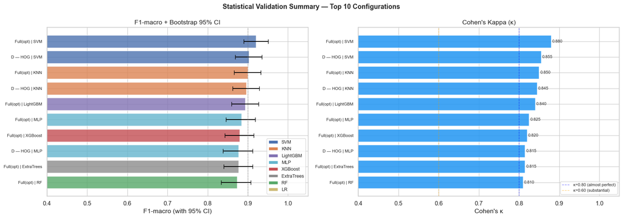

```
Saved: statistical_validation_summary.png

=================================================================
SECTION 15 COMPLETE — Files saved:
  bootstrap_ci_results.csv
  cv_fold_statistics.csv
  mcnemar_test_results.csv
  wilcoxon_test_results.csv
  friedman_test_results.csv
  statistical_validation_summary.csv
  kappa_heatmap.png
  bootstrap_ci_best_fs.png
  cv_fold_statistics.png
  mcnemar_pvalue_matrix.png
  friedman_pvalues.png
  nemenyi_posthoc.png
  statistical_validation_summary.png
```

```python
# ── Final visual summary: strip-plot + CI bars for top configurations ──────
# Show top-10 configurations with error bars (CI) and κ annotation

top10 = summary_df.head(10).copy()

fig, axes = plt.subplots(1, 2, figsize=(17, 6))
fig.suptitle("Statistical Validation Summary — Top 10 Configurations",
             fontsize=13, fontweight="bold")

# Left: F1-macro + 95% CI
ax = axes[0]
y_pos = np.arange(len(top10))[::-1]
bar_cols = [_model_color(m) for m in top10["Model"]]
ax.barh(y_pos, top10["F1-macro"], color=bar_cols, alpha=0.8, edgecolor="white")
ax.errorbar(top10["F1-macro"].values, y_pos,
            xerr=[top10["F1-macro"].values - top10["F1 CI Low"].values,
                  top10["F1 CI High"].values - top10["F1-macro"].values],
            fmt="none", color="black", capsize=4, linewidth=1.5)
ax.set_yticks(y_pos)
ax.set_yticklabels([f"{r['Feature Set']} | {r['Model']}"
                    for _, r in top10.iterrows()], fontsize=8)
ax.set_xlabel("F1-macro (with 95% CI)")
ax.set_title("F1-macro + Bootstrap 95% CI")
ax.set_xlim(0.4, 1.05)
ax.axvline(0.9, color="gray", ls="--", lw=1, alpha=0.5)

from matplotlib.patches import Patch
legend_models = summary_df["Model"].unique() if len(summary_df) else mnames
ax.legend(handles=[Patch(facecolor=_model_color(m), label=m) for m in legend_models],
          fontsize=9, loc="lower right")

# Right: Cohen's Kappa
ax2 = axes[1]
kappa_colors = ["#2196F3" if k > 0.8 else "#FF9800" if k > 0.6 else "#F44336"
                for k in top10["κ (Kappa)"]]
bars2 = ax2.barh(y_pos, top10["κ (Kappa)"], color=kappa_colors, alpha=0.85, edgecolor="white")
ax2.set_yticks(y_pos)
ax2.set_yticklabels([f"{r['Feature Set']} | {r['Model']}"
                     for _, r in top10.iterrows()], fontsize=8)
ax2.set_xlabel("Cohen's κ")
ax2.set_title("Cohen's Kappa (κ)")
ax2.set_xlim(0.4, 1.05)
ax2.axvline(0.8, color="blue",  ls="--", lw=1, alpha=0.5, label="κ=0.80 (almost perfect)")
ax2.axvline(0.6, color="orange",ls="--", lw=1, alpha=0.5, label="κ=0.60 (substantial)")
ax2.bar_label(bars2, fmt="%.3f", fontsize=8, padding=2)
ax2.legend(fontsize=8, loc="lower right")

plt.tight_layout()
plt.savefig(OUTPUT_DIR / "statistical_validation_summary.png", dpi=120, bbox_inches="tight")
plt.show()
print("Saved: statistical_validation_summary.png")

print("\n" + "=" * 65)
print("SECTION 15 COMPLETE — Files saved:")
for f in ["bootstrap_ci_results.csv", "cv_fold_statistics.csv",
          "mcnemar_test_results.csv", "wilcoxon_test_results.csv",
          "friedman_test_results.csv", "statistical_validation_summary.csv",
          "kappa_heatmap.png", "bootstrap_ci_best_fs.png",
          "cv_fold_statistics.png", "mcnemar_pvalue_matrix.png",
          "friedman_pvalues.png", "nemenyi_posthoc.png",
          "statistical_validation_summary.png"]:
    print(f"  {f}")
```